# Calculations supplement: Table 3.1, §4.4 and Sections 5–6

Companion notebook to *The Feasibility of a Hardwired Pause of Frontier AI Training* (Working Group on AI Pause Feasibility, working paper, October 2026)

Version of October 9, 2026

This notebook derives the numbers printed in Table 3.1, §4.4 and Sections 5–6 of the paper (the few it does not are listed in §S.8) from the data snapshots in `data/` and a small number of stated inputs. Most of the snapshots are Epoch AI’s (CC BY 4.0); the two curated lists of named owners and the two customs extracts are described where they are used (§S.6.4, §S.6.5). Each section gives the adopted value, the inputs and their sources, the calculation, the judgment calls it rests on, the cross-checks that reach the same quantity by another route, and the direction in which each choice is conservative. “Conservative” throughout means *regime-unfavorable*: a smaller fleet for the regime to police ($F_E$, $F_B$) or a larger exposure on a state’s ledger. A reference such as §6.2.2 is to a section of the paper; §S.1.2.3 is section 1.2.3 of this supplement. Knitting the notebook recomputes every value and figure.

**Order.** §S.1 measures the world as it stands on the eve of a pause: the frontier training trajectory, the accelerator fleets (world, United States, China, and the leading lab), and what that hardware costs. Nothing in it assumes a treaty. Everything after it does: §S.2–§S.3 set the treaty thresholds, §S.4–§S.5 derive the two violator fleet sizes, and §S.6–§S.8 assemble the ledgers.

# S.0 Conventions and units

```r
h100e.peak  <- 989e12                    # FLOP/s: one H100 SXM, dense FP16/BF16 with FP32 accumulate (paper fn 15)
secs.per.yr <- 365 * 24 * 3600
h100e <- function(flops.per.sec) flops.per.sec / h100e.peak       # peak FLOP/s -> H100e
h100e.years <- function(flop) flop / (h100e.peak * secs.per.yr)   # FLOP -> H100e-years at peak
```

- **H100e.** One H100 = 9.89e+14 FLOP/s dense 16-bit (NVIDIA n.d. lists 1,979 TFLOP/s “with sparsity”; halved for dense operation). Epoch AI’s H100e is defined on dense **8-bit** throughput (1.98e15 OP/s per H100). A chip whose 8-bit rate is twice its 16-bit rate, as it is for the H100 and for the Blackwell chips, counts for the same number of H100e on either convention, so Epoch’s fleet figures are used directly; only the FLOP/s per H100e differs (by 2×). What does differ is the *rating* of a Blackwell chip, for which NVIDIA publishes two figures: the 72-GPU liquid-cooled GB200 rack is listed at 360 PFLOP/s 16-bit with sparsity, which is 2.5e15 FLOP/s dense per GPU or 2.53 H100e (NVIDIA n.d.b), and the eight-GPU air-cooled B200 system at 72 PFLOP/s 8-bit with sparsity, which is 4.5e15 dense per GPU and so, at half the 8-bit rate, 2.25e15 FLOP/s dense 16-bit or 2.28 H100e (NVIDIA n.d.c). Epoch’s data take every B200 and B300 at the first (2.53 H100e in `data/ai_chip_sales_timelines_by_chip.csv`), and every fleet in this notebook follows them. The Astra back-of-envelope of §S.1.1.2 takes the second, the lower one.
- **Thresholds** ($C_F$, $C_T$, $C_E$) are *total training FLOP* of the final run, pretraining plus post-training, matching Epoch’s database convention and the paper’s §3.2.2 definition.
- **Judgmental inputs and derived quantities.** Every number in this notebook is one or the other. A *judgmental input* is a value the authors chose on the evidence and state as a round number ($C_F = 2\times10^{27}$, $\beta_T = 10^{-3}$, $\beta_E = 10$, the blind-leap increment $\delta = 1/3$, $T_E = 5$ yr, the 2.41×/yr growth of the world flow, the 0.75 U.S.-located share, the 100M consumer cards, the discount factors $\pi$ and $\tau$); each section says which of its inputs are judgmental and what evidence brackets them. A *derived quantity* is computed from the inputs and the data, carried at full precision into downstream calculations, and rounded to two significant figures only when printed. So $F_E$ enters the §6.4 percentages at full precision (§S.4.4), not at its two printed figures, and $K_0$(Consumer) enters as 3.03M, not 3M. Some inputs are published estimates rather than round numbers, such as the frontier research overhead $\rho_F = g^{-4/12}/0.096 \approx 6.3$ (a 9.6% final-run share, adjusted for a four-month lag; §S.4.2); they too are carried at full precision.
- **Fleets** ($F_E$, $F_B$, $F_P$) are *peak* throughput in H100e, “at present-day utilization”: the fleet a frontier lab would need. An evader achieving utilization $\tau \cdot U_F$ relative to a frontier lab needs $F/\tau$ actual chips.

# S.1 The pre-pause trajectory

Everything in this section measures or projects the world as it stands at the end of 2026, before any treaty. It supplies three things the rest of the notebook needs: the frontier training threshold $C_F$ and the utilization $U_F$ of a frontier run (§S.1.1); the size and growth of the accelerator fleets a treaty would have to govern, globally and for the United States, China and the leading lab (§S.1.2); and what that hardware is worth in dollars (§S.1.3).

Only the first of these feeds the treaty thresholds. The fleets and the dollar figures are the base against which every ledger in §S.6–§S.8 is compared, and none of them depends on a treaty parameter.

## S.1.1 The training trajectory

**Adopted: the frontier threshold $C_F = 2\times10^{27}$ FLOP, the total training compute of a frozen-frontier model at year-end 2026; the historical growth rate $g = 4.5$ per year; and the frontier utilization $U_F = 0.21$.**

$C_F$ is the quantity every treaty threshold is indexed to: the compute ceiling $C_T$, the covert evasion threshold $C_E$ and the overt breakout threshold $C_B$ are all multiples of it. It is estimated two ways — by extrapolating Epoch’s fitted trend through published frontier runs, and by a back-of-envelope on the largest run whose hardware is known — and §S.1.1.3 sets the adopted value.

### S.1.1.1 Epoch’s frontier-compute trend

Data: `data/frontier_ai_models.csv` from Epoch AI’s *AI Models* hub (frontier subset; snapshot ~2026-09-05; CC BY 4.0). Epoch’s headline is “training compute of frontier models has grown 5× per year since 2020”; their regression gives 4.5×. Two readings of “the frontier” are fitted below: all frontier-flagged models (the typical frontier model) and the running-maximum record-setters (the single largest run).

```r
ep <- read.csv("data/frontier_ai_models.csv", check.names = FALSE, stringsAsFactors = FALSE)
ep$C    <- suppressWarnings(as.numeric(ep[["Training compute (FLOP)"]]))
ep$date <- as.Date(ep[["Publication date"]])
ep <- ep[!is.na(ep$C) & !is.na(ep$date), ]
ep$yr <- as.numeric(format(ep$date, "%Y")) + (as.numeric(format(ep$date, "%j")) - 1) / 365.25
ep <- ep[order(ep$yr), ]
T.anchor <- 2026 + 365 / 365.25                     # 31 Dec 2026

fit.trend <- function(d) {
  m <- lm(log10(C) ~ yr, data = d)
  pred <- predict(m, data.frame(yr = T.anchor), interval = "confidence", level = 0.95)
  data.frame(n = nrow(d), growth.per.yr = 10^coef(m)[["yr"]], r2 = summary(m)$r.squared, resid.sd.dex = summary(m)$sigma,
             at.end.2026 = 10^pred[1, "fit"], ci.lo = 10^pred[1, "lwr"], ci.hi = 10^pred[1, "upr"])
}
all.since.2020 <- ep[ep$yr >= 2020, ]
ep$runmax <- cummax(ep$C)
records <- ep[ep$C == ep$runmax & ep$yr >= 2020, ]; records <- records[!duplicated(records$C), ]
trend <- rbind("all frontier models since 2020" = fit.trend(all.since.2020),
               "record-setters since 2020"      = fit.trend(records))
trend
```

|  | n | growth.per.yr | r2 | resid.sd.dex | at.end.2026 | ci.lo | ci.hi |
| --- | --- | --- | --- | --- | --- | --- | --- |
| all frontier models since 2020 | 38 | 4.45 | 0.884 | 0.371 | 1.67e+27 | 7.40e+26 | 3.75e+27 |
| record-setters since 2020 | 11 | 4.59 | 0.988 | 0.149 | 5.38e+27 | 3.01e+27 | 9.63e+27 |

The figure below also shows the authors’ back-of-envelope range for GPT-6 Astra (released 2026-09-03), derived in §S.1.1.2: 100.8k B200/B300-class GPUs (Epoch lists 100.8k of each type at Abilene; Astra’s “more than 100,000” matches one block) for 3 to 6 months at 40% MFU, 16-bit arithmetic, 40% post-training share; mid = geometric mean of the two ends. It is not an Epoch estimate.

```r
astra.total <- function(gpus, months, mfu = 0.40, f.post = 0.40, chip.peak = 2.25e15)
  gpus * chip.peak * mfu * months * 30.44 * 86400 / (1 - f.post)
astra.gpus <- 100.8e3                                                     # Epoch AI 2026e: 100.8k B200 + 100.8k B300 at Abilene
astra <- data.frame(yr = 2026 + (246 - 1) / 365.25,                      # 3 Sep 2026
                    lo = astra.total(astra.gpus, 3), hi = astra.total(astra.gpus, 6))
astra$mid <- sqrt(astra$lo * astra$hi)
signif(unlist(astra[c("lo", "mid", "hi")]), 2)
```

```
##      lo     mid      hi
## 1.2e+27 1.7e+27 2.4e+27
```

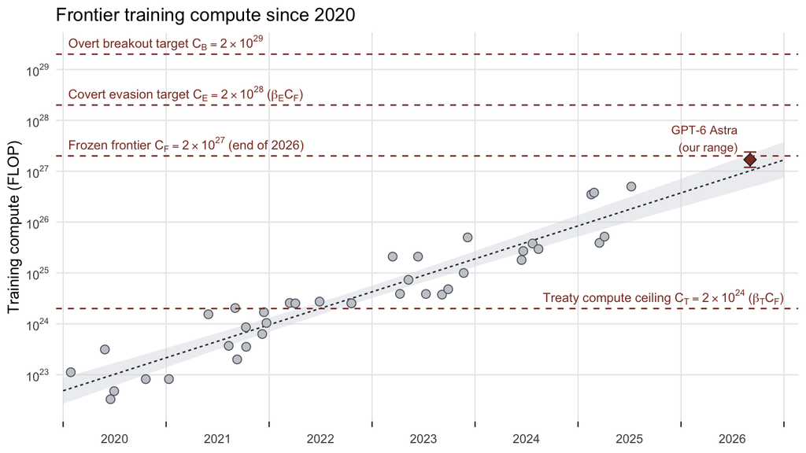

Frontier training compute, Epoch AI data, with the OLS trend (dashed), its 95% confidence band, the adopted C_F with the thresholds C_T = β_T·C_F and C_E = β_E·C_F indexed to it, the overt breakout threshold C_B (an absolute level, six blind steps above C_F; §S.5), and the authors’ back-of-envelope range for GPT-6 Astra (error bar: 100.8k GPUs for 3-6 months; not an Epoch estimate). Reproduces Epoch’s ‘5x per year’ chart; the fitted slope is 4.45x/yr.

```r
m.all <- lm(log10(C) ~ yr, data = all.since.2020)
grid <- data.frame(yr = seq(2020, T.anchor, length.out = 200))
ci <- predict(m.all, grid, interval = "confidence"); grid$fit <- ci[, 1]; grid$lo <- ci[, 2]; grid$hi <- ci[, 3]
ggplot() +
  geom_ribbon(data = grid, aes(yr, ymin = lo, ymax = hi), fill = "#D9DCE0", alpha = 0.45) +
  geom_line(data = grid, aes(yr, fit), colour = "#33393F", linetype = "22") +
  geom_point(data = all.since.2020, aes(yr, log10(C)), shape = 21, size = 2.6, fill = "#C9CBCE", colour = "#5A6470") +
  geom_errorbar(data = astra, aes(x = yr, ymin = log10(lo), ymax = log10(hi)), width = 0.12, colour = "#8C3B2E") +
  geom_point(data = astra, aes(yr, log10(mid)), shape = 23, size = 3, fill = "#8C3B2E", colour = "#1A1A1A") +
  annotate("text", x = astra$yr - 0.12, y = log10(astra$hi) + 0.02, hjust = 1, vjust = 0, size = 3, colour = "#8C3B2E",
           label = "GPT-6 Astra\n(our range)") +
  geom_hline(yintercept = log10(c(2e24, 2e27, 2e28, 2e29)), colour = "#8C3B2E", linetype = "dashed") +           # C_T, C_F, C_E, C_B (sections S.2, S.3, S.5)
  annotate("text", x = 2020.05, y = log10(2e27) + 0.08, hjust = 0, vjust = 0, size = 3.2, colour = "#8C3B2E",
           label = "'Frozen frontier ' * C[F] == 2 %*% 10^27 ~ '(end of 2026)'", parse = TRUE) +
  annotate("text", x = 2020.05, y = log10(2e28) + 0.08, hjust = 0, vjust = 0, size = 3.2, colour = "#8C3B2E",
           label = "'Covert evasion target ' * C[E] == 2 %*% 10^28 ~ '(' * beta[E] * C[F] * ')'", parse = TRUE) +
  annotate("text", x = 2020.05, y = log10(2e29) + 0.08, hjust = 0, vjust = 0, size = 3.2, colour = "#8C3B2E",
           label = "'Overt breakout target ' * C[B] == 2 %*% 10^29", parse = TRUE) +
  annotate("text", x = T.anchor, y = log10(2e24) + 0.08, hjust = 1, vjust = 0, size = 3.2, colour = "#8C3B2E",
           label = "'Treaty compute ceiling ' * C[T] == 2 %*% 10^24 ~ '(' * beta[T] * C[F] * ')'", parse = TRUE) +
  scale_y_continuous(breaks = 22:29, labels = function(v) parse(text = paste0("10^", v))) +
  year_axis(2020, 2026, expand = expansion(mult = c(0.01, 0.02))) +
  labs(x = NULL, y = "Training compute (FLOP)",
       title = "Frontier training compute since 2020") +
  theme_minimal(base_size = 11) + year_theme + theme(panel.grid.minor.y = element_blank())
```

Footnote 64’s “$1.7\times10^{27}$ at year-end 2026” is the all-models trend (1.67e+27). The record-setter trend is 5.38e+27. Individual frontier models scatter about the trend with a standard deviation of 0.37 dex, so the *next* record run at end-2026 is not well pinned down by the fit: the 95% band on the trend itself is 7.40e+26–3.75e+27.

### S.1.1.2 GPT-6 Astra back-of-envelope

Facts used (fn 64): Astra was pretrained on “more than 100,000 GPUs” at OpenAI’s Stargate Abilene campus (Lardinois 2026); Epoch’s data-center directory lists Abilene at ~100.8k B200 + ~100.8k B300 as of May 2026 (Epoch AI 2026e), i.e. roughly 200k chips were physically there. A B200/B300 is taken at 2.25e15 FLOP/s dense 16-bit, 2.28 H100e; this is the lower of NVIDIA’s two ratings for the chip, and at the higher one (2.5e15, the rating Epoch’s fleet data use; §S.0) every figure in this section would be 11% larger. Pretraining MFU is taken at 40% (Llama-3 reported 38–43%; Epoch uses 30–50%).

```r
b200.peak.16 <- 2.25e15
astra.gpus   <- c("100k GPUs" = 100e3, "200k GPUs" = 200e3)
astra.months <- c(3, 4, 6);  mfu <- 0.40;  f.post <- 0.40      # post-training share of total FLOP (implied by Epoch's GPT-5 medians)
pre16 <- outer(astra.gpus * b200.peak.16 * mfu, astra.months * 30.44 * 86400)
colnames(pre16) <- paste(astra.months, "mo")
list("pretraining FLOP, 16-bit, 40% MFU"          = signif(pre16, 2),
     "total FLOP (pre + post) at f_post = 0.4"     = signif(pre16 / (1 - f.post), 2),
     "total FLOP if the run was FP8 (x2)"          = signif(2 * pre16 / (1 - f.post), 2))
```

```
## $`pretraining FLOP, 16-bit, 40% MFU`
##              3 mo    4 mo    6 mo
## 100k GPUs 7.1e+26 9.5e+26 1.4e+27
## 200k GPUs 1.4e+27 1.9e+27 2.8e+27
##
## $`total FLOP (pre + post) at f_post = 0.4`
##              3 mo    4 mo    6 mo
## 100k GPUs 1.2e+27 1.6e+27 2.4e+27
## 200k GPUs 2.4e+27 3.2e+27 4.7e+27
##
## $`total FLOP if the run was FP8 (x2)`
##              3 mo    4 mo    6 mo
## 100k GPUs 2.4e+27 3.2e+27 4.7e+27
## 200k GPUs 4.7e+27 6.3e+27 9.5e+27
```

### S.1.1.3 The frontier threshold C_F: choice and sensitivity

```r
C.F <- 2e27
grok4 <- 5e26; grok4.date <- 2025 + 190 / 365.25
c("C_F / all-models trend" = C.F / trend$at.end.2026[1],
  "C_F / record-setter trend" = C.F / trend$at.end.2026[2],
  "Grok 4 carried to end-2026 at 5x/yr" = grok4 * 5^(T.anchor - grok4.date),
  "C_F / Grok 4" = C.F / grok4)
```

```
##              C_F / all-models trend           C_F / record-setter trend
##                            1.20e+00                            3.72e-01
## Grok 4 carried to end-2026 at 5x/yr                        C_F / Grok 4
##                            5.41e+27                            4.00e+00
```

**Judgment calls.**

- *Typical frontier model vs. largest run.* $2\times10^{27}$ is 1.2× the typical-frontier trend and 0.37× the record-setter trend. The thresholds are meant to describe the most capable models at the frozen frontier, which argues for something between the two.
- *Post-training share.* 40% (implied by Epoch’s medians for GPT-5; §S.1.1.4), the same share that enters the blended utilization $U_F$ (§S.1.1.4) and the reinforcement-learning (RL) fine-tuning remark of §6.2.5.
- *Arithmetic precision.* The paper rates all hardware in dense 16-bit (fn 14). If Astra’s pretraining ran in FP8 the chips delivered twice the operations per second, so the run used twice the FLOP shown in the Astra table and $C_F$ “should” be twice as high. But this does not change $F_E$ once it is converted to H100e: an evader training in the same precision gets the same 2× from its own chips, so the chip-count $F_E = \rho_E \cdot \beta_E$·(Astra’s chip-time)/$T_E$ is invariant to the precision convention. Basing $C_F$ on Astra’s hardware-time is what makes $F_E$ robust to this concern.
- *What “training compute” counts.* Epoch derives FLOP as chip-seconds × peak × an assumed 30–50% utilization, which overstates useful FLOP for RL-heavy runs. A treaty would need to fix a counting convention (e.g. 6·N·D plus counted RL FLOP) rather than GPU-hours × MFU.

**Direction of conservatism.** $F_E$, $F_P$, $C_T$ and $C_E$ scale linearly with $C_F$; $F_B$ does not (§6.2.3). A smaller $C_F$ means a smaller covert-evasion fleet to police, so rounding *down* is the regime-unfavorable, conservative side.

### S.1.1.4 The post-training share f_post, and the blended utilization U_F

A frontier training run has two parts: pretraining, the large next-token-prediction run, and post-training, which today consists mostly of RL, in which the model generates long outputs that are then scored. Let $f_{\mathrm{post}}$ be the share of the final run’s total FLOP that goes to post-training. It is a judgmental input, and it enters this notebook in three places.

1. **The Astra total (§S.1.1.2).** The back-of-envelope in fn 64 counts only Astra’s pretraining hardware, so the run’s total FLOP is the pretraining FLOP divided by (1 − $f_{\mathrm{post}}$).
2. **The utilization $U_F$ (§6.2.1).** Pretraining runs at 30–50% of peak throughput (Epoch AI n.d.), and reinforcement-learning post-training at 5–20% (Denain and Wu 2026). Taking the mid-range of each gives 40% and 12.5%; Meta’s reported 38–43% for Llama-3-405B corroborates the pretraining figure. The utilization of the whole run is the FLOP-weighted average of the two, which is a harmonic mean, and it falls as $f_{\mathrm{post}}$ rises. $U_F$ sets the covert evasion fleet through $F_E = \rho_E \cdot C_E$ / ($T_E \cdot U_F$), so a lower $U_F$ means a larger $F_E$.
3. **The RL fine-tuning remark in §6.2.5**, that an RL fine-tune of an existing model that stays below $C_T$ is a small fraction of the post-training compute already spent on that model.

**The evidence for 0.40.** The only estimate of $f_{\mathrm{post}}$ for a specific frontier run is Epoch AI’s estimate for GPT-5, released in August 2025: a median of about $3\times10^{25}$ FLOP of pretraining and about $5\times10^{25}$ in total (Epoch AI 2025b), which leaves about $2\times10^{25}$ for RL, a post-training share of 40%. It is an estimate rather than a disclosure, and Epoch’s range for GPT-5’s final RL relative to its pretraining, 10% to 200%, corresponds to shares of 9% to 67%. Parity, 50%, has been suggested as a forward-looking value, because RL budgets have been growing faster than pretraining budgets (xAI described Grok 4’s RL compute as comparable to its pretraining compute), but it has no single source.

The table below shows what each value of $f_{\mathrm{post}}$ implies, holding everything else fixed: the Astra total for 100k GPUs over four months, $U_F$, the resulting $F_E$ at $C_F = 2\times10^{27}$, and the size of an RL fine-tune at $C_T$ relative to the original model’s post-training.

```r
g.F <- 4.5; lag.rd <- 4 / 12                          # the historical growth rate g, and the R&D-to-final-run lag, both from section S.4.2 below
rho.F <- g.F^(-lag.rd) / 0.096; delta <- 1 / 3         # frontier research overhead and blind-leap increment, derived in section S.4.2 below; needed here for F_E
blind.steps  <- function(beta, dl = delta) pmax(1, log10(beta) / dl)                         # n = log10(beta) / delta, NOT rounded: every step is delta, the last may be partial
blind.factor <- function(beta, dl = delta) { n <- blind.steps(beta, dl); f <- (1 - 1 / beta) / (1 - beta^(-1 / n)); ifelse(rep_len(beta, length(f)) <= 1, 1, f) }
rho.E.of <- function(beta, rF = rho.F, dl = delta) rF * blind.factor(beta, dl)                                # rho_E = rho_F x blind-leap factor
U.blend <- function(f, U.pre = 0.40, U.post = 0.125) 1 / ((1 - f) / U.pre + f / U.post) # FLOP-weighted utilization, mid-range of each band
F.E.fpost <- function(f) rho.E.of(10) * 10 * C.F / (5 * secs.per.yr * U.blend(f)) / h100e.peak               # F_E at beta_E = 10, T_E = 5 for a given post-training share
f <- c(0.09, 0.30, 0.40, 0.50, 0.67, 0.75, 0.90)
astra.pre <- pre16["100k GPUs", "4 mo"]
data.frame(f_post = f,
           astra.total.FLOP = signif(astra.pre / (1 - f), 2),
           U_F = round(U.blend(f), 3),
           F_E.M.H100e = round(F.E.fpost(f) / 1e6, 2),                                          # rho_E beta_E C_F / (T_E U_F)
           RL.finetune.share = sprintf("%.2f%%", 100 * (C.F / 1000) / (f * C.F)))
```

| f_post | astra.total.FLOP | U_F | F_E.M.H100e | RL.finetune.share |
| --- | --- | --- | --- | --- |
| 0.09 | 1.0e+27 | 0.334 | 4.07 | 1.11% |
| 0.30 | 1.4e+27 | 0.241 | 5.64 | 0.33% |
| 0.40 | 1.6e+27 | 0.213 | 6.39 | 0.25% |
| 0.50 | 1.9e+27 | 0.190 | 7.14 | 0.20% |
| 0.67 | 2.9e+27 | 0.162 | 8.41 | 0.15% |
| 0.75 | 3.8e+27 | 0.151 | 9.00 | 0.13% |
| 0.90 | 9.5e+27 | 0.134 | 10.13 | 0.11% |

Because the blend is a harmonic mean, it is pulled toward the lower RL utilization: at $f_{\mathrm{post}} = 0.5$ it is 0.19 rather than the arithmetic average of 0.26; at 0.4 it is 0.21.

**Newer evidence that runs have become more RL-heavy.** The last two rows of the table cover a much more RL-heavy run, which the most recent evidence points toward, although that evidence does not measure $f_{\mathrm{post}}$ directly. SemiAnalysis’s tokenomics model (Xie et al. 2026) splits the combined GPU capacity of OpenAI and Anthropic among three uses: pretraining, post-training and RL, and inference serving. It has the split moving from 40% / 24% / 36% in the third quarter of 2025 to 7% / 55% / 38% in the fourth quarter of 2026, the last two quarters being projections. Two things separate this from $f_{\mathrm{post}}$. It is a share of *hardware-time* for the whole company, across every model and every experiment, not the FLOP of one final run; and it is a model built by SemiAnalysis, not a disclosure by the labs. The two frames can be converted with the utilization figures above: an hour of RL hardware yields 0.125 / 0.40 of the FLOP that an hour of pretraining hardware yields, so a ratio of RL to pretraining hardware-time of r corresponds to a FLOP ratio of 0.312 · r.

The two frames can be compared in mid-2025, when both are available. GPT-5’s final run had RL at 0.67 times its pretraining in FLOP, which is 2.1 times in hardware-time; the lab-wide chart has RL at only 0.3 to 0.6 times pretraining over the same quarters. So a flagship run was several times more RL-intensive than the company’s compute as a whole, presumably because most lab-wide pretraining capacity goes to experiments and smaller models rather than to the flagship’s final run. Two conclusions follow. The chart cannot be read as $f_{\mathrm{post}}$ for a single run. And since flagship runs were more RL-heavy than the lab average when the comparison can be made, the chart’s later lab-wide ratios, about 4 in the second quarter of 2026 and 8 in the fourth, are if anything low for a late-2026 flagship run such as Astra.

Taken at face value, those ratios would put a late-2026 run’s post-training share at 56% (ratio 4) to 71% (ratio 8). $U_F$ would fall to 0.17–0.15. The Astra total for 100k GPUs over three to four months would be 1.7–$2.3\times10^{27}$ at a 60% share and 2.8–$3.7\times10^{27}$ at 75%, rather than 1.2–$1.5\times10^{27}$. And because $F_E$ is proportional to a frontier run’s total hardware-time (§S.1.1.3), which is (1 + r) times its pretraining hardware-time, the run would take 1.6–2.9 times the hardware-time that $f_{\mathrm{post}} = 0.40$ implies, and an $F_E$ anchored on Astra’s hardware would be larger by the same factor: roughly 10–18M H100e rather than 6.4M.

**Adopted: the post-training share of a frontier run’s FLOP, $f_{\mathrm{post}} = 0.40$, and with it the frontier utilization $U_F = 0.21$**, the fraction of peak throughput a present-day frontier training run sustains.

**Direction of conservatism.** The late-2026 value of $f_{\mathrm{post}}$ is not known: the one per-run estimate, from mid-2025, gives 0.40, and the lab-wide trend since then is consistent with anything from 0.6 upward for a single run. Every value above 0.40 raises the Astra total, and so $C_F$; lowers $U_F$; and raises $F_E$. A larger $F_E$ is the regime-favorable direction, because it means a larger covert fleet, which is harder to hide and easier to police. So 0.40 is adopted as the regime-unfavorable end of the range, not as a central estimate, and the paper’s $F_E$ is a floor in this respect: on the lab-wide trend the true figure could be two to three times higher.

```r
f.post <- 0.40
U.F <- U.blend(f.post)
c(U_F = U.F)
```

```
##   U_F
## 0.213
```

## S.1.2 The fleet trajectories

The world accelerator fleet, and the national and company fleets inside it, are used at four points: §4.4’s transition timeline needs the stock at the start of Phase 2 and the rate at which it is being replaced; §6.4.2’s transitional-service exposure needs the U.S.-located and Chinese fleets; §6.4.3’s dark-compute residual needs the composition of the U.S. fleet; and the leading lab’s own fleet is the yardstick $F_E$ is checked against in §S.4.5.

**One world model serves all of them.** Epoch’s quarterly chip-sales data run out partway through 2026; the model fills the gap centrally, then grows the quarterly flow at a fixed rate. The national fleets are shares of that model or are built from the same source, so the pieces sum. §S.1.2.1–§S.1.2.6 build the world model; §S.1.2.7–§S.1.2.9 take the United States, China and the leading lab in turn.

**Adopted: a world fleet of 47M H100e at year-end 2026, of which three quarters (35M) is located in the United States and 3.1M is China’s; and a leading lab at 6.4M H100e.**

**Adopted: the world accelerator fleet at year-end 2026, 47M H100e on a sold basis, produced by one world model that every later fleet quantity uses; and the Phase 2 duration of §4.4, that fleet divided by the model’s own year-end installable flow of 2.9M H100e per month, about 16 months.**

The world accelerator fleet is the total number of AI accelerators in existence, measured in H100e. Several quantities in the paper depend on it: the size of the fleet at year-end 2026 that a treaty would have to register, the part of it located in the United States (§S.1.2.7), the length of Phase 2 (how long it takes to replace the fleet with inference-only hardware), and the share of it serving inference (§S.7.2). Rather than estimate each of these separately, this section builds one model of the fleet over time and every later section draws on it, so that all of these quantities are consistent with one another.

The model has three pieces, described in the subsections that follow. Up to the end of 2025 it uses Epoch AI’s cumulative count of accelerators by owner (§S.1.2.1). For the first half of 2026 it adds Epoch’s quarterly shipment data, which are still incomplete for some vendors, with the missing rows filled in by the authors (§S.1.2.2 and §S.1.2.3). From the third quarter of 2026 onward, where there are no data, it assumes that the quarterly flow of new accelerators keeps growing at 2.41× per year, a judgmental input discussed in §S.1.2.4. The result is the fleet at year-end 2026 and, for the breakout calculation, its path through 2029.

### S.1.2.1 End-2025 stock

```r
Hcol <- "Compute estimate in H100e (median)"
own <- read.csv("data/ai_chip_owners_cumulative_by_designer.csv", check.names = FALSE, stringsAsFactors = FALSE)
o25 <- own[own[["End date"]] == "2025-12-31" & own$Owner != "China (smuggled)", ]       # the smuggled row re-allocates chips already counted in the other rows (sales and owners totals agree without it)
by.owner <- tapply(o25[[Hcol]], o25$Owner, sum)
## A100s sold before 2022.  Epoch's chip-sales and owner data start in 2022, so these are added from its estimate of NVIDIA's installed computing
## power by generation (Emberson and Owen 2025): cumulative Ampere FLOP/s through 2021Q4, at 989 TFLOP/s per H100e, by quarter of sale.
nv <- read.csv("data/nvidia_flops_by_generation.csv", check.names = FALSE, stringsAsFactors = FALSE)
nv <- nv[nv[["Chip type"]] == "Ampere" & nv$Period <= "2021Q4" & !is.na(nv[["Cumulative FLOP/s"]]), ]; nv <- nv[order(nv$Period), ]
a100.pre <- data.frame(t = as.numeric(substr(nv$Period, 1, 4)) + (as.numeric(substr(nv$Period, 6, 6)) - 1) / 4 + 0.125, h = diff(c(0, nv[["Cumulative FLOP/s"]])) / h100e.peak)
oq.a <- read.csv("data/ai_chip_owners_quarters_by_chip_type.csv", check.names = FALSE, stringsAsFactors = FALSE)
oq.a <- oq.a[oq.a[["Chip type"]] == "A100" & substr(oq.a[["Start date"]], 1, 4) == "2022", ]
a100.mix <- tapply(oq.a[[Hcol]], oq.a$Owner, sum); a100.mix <- a100.mix / sum(a100.mix)                 # the A100's buyers in 2022, its first year in Epoch's data
by.owner[names(a100.mix)] <- by.owner[names(a100.mix)] + a100.mix * sum(a100.pre$h)
by.owner <- sort(by.owner, decreasing = TRUE); stock.2025 <- sum(by.owner)
data.frame(owner = names(by.owner), M.H100e = round(by.owner / 1e6, 2), share.pct = round(100 * by.owner / stock.2025, 1), row.names = NULL)
```

| owner | M.H100e | share.pct |
| --- | --- | --- |
| Google | 5.07 | 24.7 |
| Microsoft | 3.47 | 16.9 |
| Other | 3.44 | 16.8 |
| Amazon | 2.47 | 12.1 |
| Meta | 2.33 | 11.4 |
| China | 1.18 | 5.7 |
| Oracle | 1.15 | 5.6 |
| CoreWeave | 0.83 | 4.1 |
| xAI | 0.55 | 2.7 |

```r
c("world stock, end-2025 (M H100e)" = stock.2025 / 1e6, "  of which A100s sold before 2022 (M)" = sum(a100.pre$h) / 1e6)
```

```
##       world stock, end-2025 (M H100e)   of which A100s sold before 2022 (M)
##                                20.488                                 0.223
```

Source: Epoch AI 2026c, “Data on AI Chip Owners” (updated 2026-05-12). Epoch’s published headlines are reproduced before the addition described next: about 20M sold, five hyperscalers 71%, Google about 25%, China “just over 5%”. Epoch’s per-firm 90% intervals are roughly −23/+29% (the “Other” bucket −33/+42%).

**Chips sold before 2022.** Epoch’s owner and sales data begin in the first quarter of 2022, so the count above starts from zero then. Two groups of older chips are therefore missing. *A100s sold in 2020 and 2021* are accelerators of the class this analysis counts, and they are added: Epoch’s estimate of NVIDIA’s installed computing power by chip generation, built from NVIDIA’s data-center revenue (Emberson and Owen 2025), puts the A100 generation at $2.2\times10^{20}$ FLOP/s through the end of 2021, which is 0.22M H100e at 989 TFLOP/s each. They are assigned to owners in the proportions in which A100s were bought in 2022 (57% the seven large firms, 33% other owners, 10% China). That estimate assigns all of NVIDIA’s data-center revenue to a chip generation, and for 2022 it shows about twice the A100-generation compute that Epoch’s chip-sales data do, so it is the larger of the two readings and is used as the regime-unfavorable one. *Generations before the A100* (the V100, P100 and K80, about 0.11M H100e at their 2021 peak on the same estimate, nearly all of it V100) are left out: the cloud providers have retired them (§S.1.2.6), and a V100 is comparable to a high-end consumer card, so they belong with the consumer GPUs of §S.7.3.

### S.1.2.2 Quarterly flow in 2026, and the rows that are missing

```r
sal <- read.csv("data/ai_chip_sales_timelines_by_chip.csv", check.names = FALSE, stringsAsFactors = FALSE)
sal$start <- as.Date(sal[["Start date"]]); sal <- sal[!is.na(sal$start), ]
sal$q <- sprintf("%s Q%d", format(sal$start, "%Y"), (as.integer(format(sal$start, "%m")) - 1) %/% 3 + 1)
sal$incomplete <- sal$Incomplete %in% c(TRUE, "True", "true", "Yes")
flow <- tapply(sal[[Hcol]], list(sal$q, sal[["Chip manufacturer"]]), sum, na.rm = TRUE); flow[is.na(flow)] <- 0
flow <- flow[order(rownames(flow)), ]
recentq <- c("2025 Q1", "2025 Q2", "2025 Q3", "2025 Q4", "2026 Q1", "2026 Q2", "2026 Q3")
cbind(round(flow[recentq, ] / 1e6, 3), total = round(rowSums(flow[recentq, ]) / 1e6, 2),
      any.incomplete = tapply(sal$incomplete, sal$q, any)[recentq])
```

```
##         Amazon   AMD Cambricon Google Huawei Nvidia total any.incomplete
## 2025 Q1  0.138 0.160     0.005  0.441  0.132   1.70  2.57              0
## 2025 Q2  0.164 0.105     0.008  0.631  0.132   1.89  2.93              0
## 2025 Q3  0.190 0.202     0.008  0.802  0.132   2.37  3.71              0
## 2025 Q4  0.220 0.218     0.008  0.830  0.132   2.96  4.37              0
## 2026 Q1  0.000 0.230     0.000  0.847  0.000   3.39  4.46              0
## 2026 Q2  0.000 0.261     0.000  0.321  0.000   3.95  4.54              1
## 2026 Q3  0.000 0.000     0.000  0.000  0.000   1.18  1.18              1
```

```r
c("check: Epoch's cumulative sales, 2022 through 2025, equal its owners-hub stock (M)" = sum(flow[rownames(flow) <= "2025 Q4", ]) / 1e6)
```

```
## check: Epoch's cumulative sales, 2022 through 2025, equal its owners-hub stock (M)
##                                                                               20.3
```

```r
annual <- tapply(rowSums(flow), substr(rownames(flow), 1, 4), sum)
round(rbind("annual flow (M H100e)" = annual[c("2022", "2023", "2024", "2025")] / 1e6,
            "growth over previous year (x)" = c(NA, annual[c("2023", "2024", "2025")] / annual[c("2022", "2023", "2024")])), 2)
```

```
##                               2022 2023 2024  2025
## annual flow (M H100e)          0.3 1.29 5.09 13.58
## growth over previous year (x)   NA 4.25 3.95  2.67
```

Source: Epoch AI 2026d, “Data on AI Chip Sales” (updated 2026-08-27). Read as listed, the 2026 flow looks flat (4.4M, 4.5M, 4.5M per quarter). It is not: the 2026 quarters have **no Huawei, Amazon (Trainium) or Cambricon rows yet**, the Q2 2026 Google row covers only about a month of the quarter (flagged Incomplete), and Q3 2026 has a partial Nvidia row only. Nvidia’s rows, which are complete, grow about 16% per quarter.

### S.1.2.3 Gap-fill

**Huawei.** Epoch lists Huawei’s Ascend 910B and 910C shipments at a flat 0.13M H100e in every quarter of 2025, and nothing for 2026. Somala (2026), Epoch’s own study of Huawei’s roadmap, puts 2026 production at a median of 1.5 million units, which “translates to 880,000 H100-equivalents”, or about 0.22M per quarter, after allowing for the high-bandwidth-memory shortage that limits how many of those units are full-specification accelerators. The fill takes Somala’s estimate at face value: 0.88M spread evenly over the year, 0.22M per quarter, rather than Epoch’s flat 0.13M, because Somala’s figure is a production estimate for the whole year while Epoch’s rows record shipments as they are confirmed and tend to be revised upward later. Epoch’s rate would add 0.18M less over the two quarters. The same rate is used for China’s 2026 additions in §S.1.2.8, so the two sections share one assumption about Chinese production.

**Amazon.** Epoch’s Trainium2 rows rise through 2025, from 0.14M H100e in the first quarter to 0.22M in the fourth, and stop there. The fill extrapolates that ramp geometrically: the growth rate per quarter over 2025 is the cube root of the ratio of the fourth-quarter row to the first, about 17%, and the two 2026 quarters continue the fourth-quarter rate at that growth, giving about 0.26M and 0.30M (the chunk prints the exact values). No outside estimate of 2026 Trainium output was found, so this is the one fill that rests on Epoch’s rows alone; holding the fourth-quarter rate flat instead would add 0.12M less over the two quarters, a quarter of a percent of the year-end fleet.

**Nvidia** needs no fill: its rows are complete for the first two quarters of 2026 (and grow about 16% per quarter). Epoch’s third-quarter Nvidia row is partial, but the model of §S.1.2.4 takes over from the third quarter, so it is not used.

**Cambricon.** Epoch lists Cambricon, China’s other accelerator designer, at 0.005–0.008M H100e per quarter through 2025. The fill is 0.01M per quarter, a rounding of the recent rate; it is immaterial to the fleet and is included so that China’s additions in §S.1.2.8 are complete.

**Google.** Google’s TPUs are the second-largest flow after Nvidia. Epoch’s row for the second quarter of 2026 is flagged as incomplete and totals 0.32M H100e, about 38% of the first-quarter total of 0.85M, consistent with covering roughly the first month of the quarter. The fill replaces it with a full quarter at 0.92M, the first-quarter rate with modest growth (8%; Epoch’s rows show 2–4% growth per quarter into early 2026, and a new TPU generation was ramping), rather than adding to the partial row.

The chunk below applies these fills to the listed rows. The growth rate it reports, from the fourth quarter of 2025 to the gap-filled second quarter of 2026, is the realised pace of the flow at the point where the model of §S.1.2.4 takes over.

```r
huawei.q    <- 0.88e6 / 4                                            # Somala 2026: 880k H100e of Huawei output in 2026, spread evenly
tr <- flow[c("2025 Q1", "2025 Q4"), "Amazon"]; g.tr <- (tr[2] / tr[1])^(1 / 3)   # Trainium: growth per quarter over 2025, from Epoch's rows
trainium.q  <- tr[2] * g.tr^(1:2)                                    # Q1 and Q2 2026 by geometric extrapolation of the Q4 2025 rate
cambricon.q <- 0.01e6
gap.q <- huawei.q + trainium.q + cambricon.q                         # per quarter (Q1, Q2)
round(c("Huawei per quarter (M)" = huawei.q / 1e6, "Trainium growth per quarter over 2025 (x)" = g.tr, "Trainium Q1 2026 (M)" = trainium.q[1] / 1e6, "Trainium Q2 2026 (M)" = trainium.q[2] / 1e6), 3)
```

```
##                            Huawei per quarter (M)
##                                             0.220
## Trainium growth per quarter over 2025 (x).2025 Q4
##                                             1.168
##                              Trainium Q1 2026 (M)
##                                             0.257
##                              Trainium Q2 2026 (M)
##                                             0.300
```

```r
q4  <- sum(flow["2025 Q4", ])
q1f <- sum(flow["2026 Q1", ]) + gap.q[1]
q2f <- sum(flow["2026 Q2", ]) - flow["2026 Q2", "Google"] + 0.92e6 + gap.q[2]
g.q <- (q2f / q4)^(1 / 2)                                            # geometric mean quarter-on-quarter growth, Q4 2025 -> Q2 2026
round(c("Q4 2025 (M)" = q4 / 1e6, "Q1 2026 gap-filled (M)" = q1f / 1e6, "Q2 2026 gap-filled (M)" = q2f / 1e6, "growth per quarter (%)" = 100 * (g.q - 1)), 2)
```

```
##            Q4 2025 (M) Q1 2026 gap-filled (M) Q2 2026 gap-filled (M)
##                   4.37                   4.95                   5.66
## growth per quarter (%)
##                  13.91
```

### S.1.2.4 The world model: year-end 2026 and beyond

Past the quarters for which there are data, the world *flow* grows at **2.41×/yr**, a judgmental input equal to the product of the two trends in §1.1 of the AI 2040 compute supplement (Dean 2026a): AI capital expenditure about 1.72×/yr (Q3 2023 to Q4 2025, from Epoch’s hyperscaler capex data) and cost-efficiency, H100e per dollar, about 1.4×/yr. That is the supplement’s *naive baseline*, not its judgmental forecast, which re-forecasts capex from hyperscaler finances and throttles cost-efficiency with an EUV scarcity surcharge. The extrapolation picks up from the gap-filled Q2 2026 flow and the stock through Q2 2026.

```r
stock.q2 <- stock.2025 + q1f + q2f
g.flow <- 2.41                                                  # 1.72 (AI capex) x 1.40 (H100e per $): Dean 2026a, sec. 1.1
make.world <- function(g.flow, n.q = 18) {                      # quarter-ends Q2 2026 ... Q4 2030; t = years after end-2025
  fq <- q2f * (g.flow^(1 / 4))^(1:n.q)
  data.frame(t = 0.5 + 0.25 * (0:n.q), flow = c(q2f, fq), W = stock.q2 + c(0, cumsum(fq))) }
make.W <- function(wq) function(t) exp(approx(c(0, 0.25, wq$t), log(c(stock.2025, stock.2025 + q1f, wq$W)), xout = t, rule = 2)$y)   # log-linear between quarter-ends
world.q <- make.world(g.flow); W.of <- make.W(world.q)
adds <- c("2026" = q1f + q2f + sum(world.q$flow[2:3]), "2027" = sum(world.q$flow[4:7]), "2028" = sum(world.q$flow[8:11]), "2029" = sum(world.q$flow[12:15]))
round(rbind("world additions (M H100e)" = adds, "world stock, year-end (M H100e)" = W.of(1:4)) / 1e6, 1)
```

```
##                                 2026  2027 2028 2029
## world additions (M H100e)       26.5  62.8  151  365
## world stock, year-end (M H100e) 47.0 109.8  261  626
```

```r
fleet.ye2026 <- W.of(1)                                         # the year-end 2026 fleet: derived, carried at full precision, printed as 47M
flow.q4.2026 <- world.q$flow[3]                                 # the model's Q4 2026 quarterly flow
us.frac <- 0.75                                                 # fraction of the fleet located in the U.S.: "about three quarters" (section S.1.2.7)
round(c("stock through Q2 2026 (M)" = stock.q2 / 1e6, "world fleet, year-end 2026 (M)" = fleet.ye2026 / 1e6,
        "monthly installable flow at year-end 2026 = Q4 2026 flow / 3 (M per month)" = flow.q4.2026 / 3 / 1e6,
        "  observed, gap-filled Q2 2026 / 3" = q2f / 3 / 1e6, "  observed as listed, Q2 2026 / 3" = sum(flow["2026 Q2", ]) / 3 / 1e6,
        "Phase 2 = fleet / monthly flow (months)" = fleet.ye2026 / (flow.q4.2026 / 3), "  at the observed gap-filled Q2 rate (months)" = fleet.ye2026 / (q2f / 3)), 2)
```

```
##                                                  stock through Q2 2026 (M)
##                                                                      31.10
##                                             world fleet, year-end 2026 (M)
##                                                                      46.95
## monthly installable flow at year-end 2026 = Q4 2026 flow / 3 (M per month)
##                                                                       2.93
##                                           observed, gap-filled Q2 2026 / 3
##                                                                       1.89
##                                            observed as listed, Q2 2026 / 3
##                                                                       1.51
##                                    Phase 2 = fleet / monthly flow (months)
##                                                                      16.02
##                                at the observed gap-filled Q2 rate (months)
##                                                                      24.87
```

```r
phase2.rate <- flow.q4.2026 / 3                                 # H100e per month installable in Phase 2: the world model's Q4 2026 flow, so stock and flow come from the same model at the same date (section 3.4)
phase2.months <- fleet.ye2026 / phase2.rate
round(c("Phase 2 = fleet / the Q4 2026 monthly flow (months)" = phase2.months, "Phases 1+2 = 26 months + Phase 2 (years)" = (26 + phase2.months) / 12), 2)
```

```
## Phase 2 = fleet / the Q4 2026 monthly flow (months)
##                                                16.0
##            Phases 1+2 = 26 months + Phase 2 (years)
##                                                 3.5
```

2.41×/yr is a central trend, not a conservative one, and it sits above the realized 2026 flow growth. Epoch’s own figures give a slightly higher product: performance per dollar +49%/yr since 2023 (90% CI 1.36–1.66×; Epoch AI 2026a) and hyperscaler capex +72%/yr (90% CI 66–78%; Juniewicz 2026d), about 2.56×. There is no supply throttle here; the supplement’s forecast has additions growing about 1.5× in 2029 where this path has 2.41×.

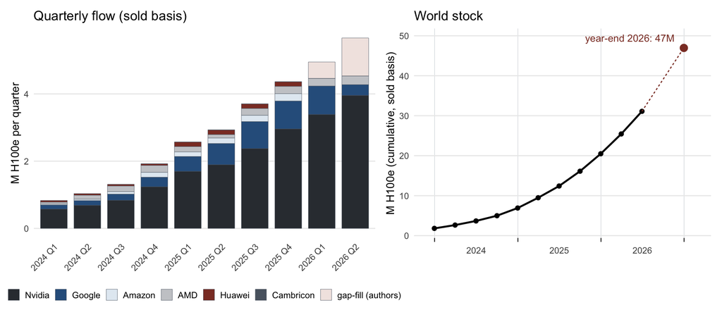

```r
library(patchwork)
fl <- as.data.frame(as.table(flow[rownames(flow) >= "2024 Q1" & rownames(flow) <= "2026 Q2", ])); names(fl) <- c("q", "designer", "h")
gap <- data.frame(q = c("2026 Q1", "2026 Q2"), designer = "gap-fill (authors)", h = c(q1f - sum(flow["2026 Q1", ]), q2f - sum(flow["2026 Q2", ])))
fl <- rbind(fl, gap); fl$designer <- factor(fl$designer, levels = c("gap-fill (authors)", "Cambricon", "Huawei", "AMD", "Amazon", "Google", "Nvidia"))
p.flow <- ggplot(fl, aes(q, h / 1e6, fill = designer)) + geom_col(width = 0.8, colour = "#5A6470", linewidth = 0.15) +
  scale_fill_manual(values = c("gap-fill (authors)" = "#F2E6E3", Cambricon = "#5A6470", Huawei = "#8C3B2E", AMD = "#C9CBCE", Amazon = "#E3EBF2", Google = "#2E5F8C", Nvidia = "#33393F"), name = NULL) +
  labs(x = NULL, y = "M H100e per quarter", title = "Quarterly flow (sold basis)") +
  theme_minimal(base_size = 11) + theme(panel.grid.minor = element_blank(), panel.grid.major.x = element_blank(), axis.text.x = element_text(angle = 45, hjust = 1), legend.position = "bottom", legend.key.size = unit(0.8, "lines")) + guides(fill = guide_legend(nrow = 1, reverse = TRUE))
cum <- sum(a100.pre$h) + cumsum(rowSums(flow)); cum <- cum[names(cum) >= "2023 Q4" & names(cum) <= "2025 Q4"]
qend <- function(q) as.Date(sprintf("%s-%02d-01", substr(q, 1, 4), 3 * as.integer(substr(q, 7, 7)))) + 30
stock.df <- rbind(data.frame(date = qend(names(cum)), h = cum), data.frame(date = as.Date(c("2026-03-31", "2026-06-30")), h = c(stock.2025 + q1f, stock.q2)))
p.stock <- ggplot() + geom_line(data = stock.df, aes(date, h / 1e6), linewidth = 0.9) + geom_point(data = stock.df, aes(date, h / 1e6), size = 1.8) +
  annotate("segment", x = as.Date("2026-06-30"), xend = as.Date("2026-12-31"), y = stock.q2 / 1e6, yend = fleet.ye2026 / 1e6, linetype = "22", colour = "#8C3B2E") +
  annotate("point", x = as.Date("2026-12-31"), y = fleet.ye2026 / 1e6, colour = "#8C3B2E", size = 3.2) +
  annotate("text", x = as.Date("2026-11-20"), y = fleet.ye2026 / 1e6 + 2.5, label = sprintf("year-end 2026: %.0fM", fleet.ye2026 / 1e6), hjust = 1, size = 3.5, colour = "#8C3B2E") +
  year_axis(2024, 2026, date = TRUE, limits = as.Date(c("2023-12-01", "2027-03-01"))) +
  labs(x = NULL, y = "M H100e (cumulative, sold basis)", title = "World stock") +
  theme_minimal(base_size = 11) + year_theme + theme(panel.grid.minor.y = element_blank())
p.flow + p.stock + plot_layout(widths = c(1.15, 1))
```

### S.1.2.6 Failure and retirement by vintage, at year-end 2026

How much of the stock counted above has in fact left service by the time of the agreement, either because the chip failed or because its owner retired it as uneconomic? (What leaves service *after* the agreement is not a concern here: licensed operators must destroy retired chips verifiably.)

The failure rate is measured on the only public record of replacements in a production AI cluster: Delta, the Illinois NCSA machine, which reported 6 accelerator replacements over its A100 and H100 partitions. It is used again in §S.4.3, where hardware lifetime is a supporting argument for the covert evasion horizon $T_E$.

```r
gpu.years <- (448 * 895 + 608 * 146) / 365
fail.rate <- c(low = qgamma(0.025, 6), central = 6, high = qgamma(0.975, 7)) / gpu.years      # replacements per GPU-year; exact Poisson 95% interval on 6 events
round(c("GPU-years observed" = gpu.years, 100 * fail.rate, "A100 alone (%/yr)" = 100 * 4 / (448 * 895 / 365), "H100 alone (%/yr)" = 100 * 2 / (608 * 146 / 365),
        "Llama-3 interruption rate, for contrast (%/yr)" = 100 * (148 + 72) / 16384 / (54 / 365)), 2)
```

```
##                             GPU-years observed
##                                        1341.72
##                                            low
##                                           0.16
##                                        central
##                                           0.45
##                                           high
##                                           0.97
##                              A100 alone (%/yr)
##                                           0.36
##                              H100 alone (%/yr)
##                                           0.82
## Llama-3 interruption rate, for contrast (%/yr)
##                                           9.08
```

- **Mechanical failure:** the Delta replacement rate above, 0.45% per year (95% interval 0.16–0.97%), applied to each quarter’s sales from the middle of the quarter. (A chip replaced under warranty is swapped for a new one, so this is an upper bound on the net loss to the fleet.)
- **Economic retirement:** none yet among the chips counted. The oldest generation in the stock is the A100, launched in 2020 and so about six and a half years old at year-end 2026, and no large cloud provider has retired a GPU generation that young. Azure’s K80, P100 and P40 families: “These products will be retired on August 31st 2023, and the oldest VMs in this series launched in 2016” (Microsoft 2023); “NVIDIA P100 GPUs on Google Cloud will reach End of Support (EOS) on September 15, 2026” (Google Cloud 2026), ten years after that GPU’s launch; Azure retired its V100 family in 2025, about eight years after that GPU’s launch (Microsoft 2025).

```r
v <- data.frame(vintage = as.integer(format(sal$start, "%Y")), t.sale = as.numeric(format(sal$start, "%Y")) + (as.integer(format(sal$start, "%m")) - 1) / 12 + 0.125,
                h = sal[[Hcol]], units = sal[["Number of Units"]])
v <- v[!is.na(v$h) & !is.na(v$units), ]
v$failed <- 1 - exp(-fail.rate[["central"]] * pmax(0, 2027 - v$t.sale))
by.v <- sapply(split(v, v$vintage), function(d) c("units sold (k)" = sum(d$units) / 1e3, "H100e sold (k)" = sum(d$h) / 1e3,
                                                  "failed by year-end 2026, % of units" = 100 * sum(d$units * d$failed) / sum(d$units), "failed, % of H100e" = 100 * sum(d$h * d$failed) / sum(d$h)))
round(cbind(by.v, all = c(sum(v$units) / 1e3, sum(v$h) / 1e3, 100 * sum(v$units * v$failed) / sum(v$units), 100 * sum(v$h * v$failed) / sum(v$h))), 2)     # 2026 = Epoch's listed rows only, through the partial Q3
```

```
##                                       2022    2023    2024     2025     2026
## units sold (k)                      937.60 2311.55 7734.69  9571.05  4223.12
## H100e sold (k)                      303.47 1290.45 5092.91 13577.31 10172.77
## failed by year-end 2026, % of units   1.98    1.51    1.09     0.67     0.32
## failed, % of H100e                    1.98    1.49    1.07     0.64     0.32
##                                          all
## units sold (k)                      24778.01
## H100e sold (k)                      30436.91
## failed by year-end 2026, % of units     0.87
## failed, % of H100e                      0.65
```

```r
#### The same on the WORLD MODEL's flows, which complete 2026 (gap-fill plus the modelled second half); H100e only, since the model has no unit counts.
wm <- data.frame(t.sale = c(as.numeric(substr(rownames(flow), 1, 4)) + (as.numeric(substr(rownames(flow), 7, 7)) - 1) / 4 + 0.125)[rownames(flow) <= "2025 Q4"], h = rowSums(flow)[rownames(flow) <= "2025 Q4"])
wm <- rbind(data.frame(t.sale = a100.pre$t, h = a100.pre$h), wm, data.frame(t.sale = 2026 + c(0, 0.25, 0.5, 0.75) + 0.125, h = c(q1f, q2f, world.q$flow[2:3])))   # with the A100s sold before 2022
failed.share <- sapply(fail.rate, function(r) sum(wm$h * (1 - exp(-r * (2027 - wm$t.sale)))) / sum(wm$h))
round(c("world stock, year-end 2026 (M)" = sum(wm$h) / 1e6, "H100e-weighted mean age (years)" = sum(wm$h * (2027 - wm$t.sale)) / sum(wm$h), 100 * failed.share), 2)
```

```
##  world stock, year-end 2026 (M) H100e-weighted mean age (years)
##                           46.95                            1.07
##                             low                         central
##                            0.18                            0.48
##                            high
##                            1.04
```

```r
round(c("U.S.-located H100e failed by year-end 2026 (k): " = us.frac * fleet.ye2026 * failed.share / 1e3))
```

```
##     U.S.-located H100e failed by year-end 2026 (k): .low
##                                                       62
## U.S.-located H100e failed by year-end 2026 (k): .central
##                                                      168
##    U.S.-located H100e failed by year-end 2026 (k): .high
##                                                      365
```

At the Delta rate, failures run from about 2% of the 2022 vintage to 0.3% of the 2026 vintage; because the stock is young (its H100e-weighted mean age is about one year) they come to about half a percent of the H100e, and nothing has been retired for age. That is a lower bound on what has left service rather than an estimate of it. The Delta rate was measured on chips in their first years at a serviced site, and failure hazards at greater ages are not known: on the Titan supercomputer the original GPUs failed at 12–15% a year after a component defect took hold, while sound replacement boards ran at 0.2–0.3% a year over their first three years (Ostrouchov et al. 2020). Chips that failed and were scrapped are counted here as still in the fleet; since a larger counted fleet means larger breakout exposures, the “no retirements” convention errs on the regime-unfavorable side. For the ledger the relevant number is the last line: the H100e that U.S. owners could *legitimately* report as failed by year-end 2026 is about 168k (62–365k over the Delta interval), which is the honest baseline against which any claimed losses would be read (§S.6).

### S.1.2.7 The U.S.-located fleet

Several later sections need the part of the world fleet that sits on U.S. soil, which is what a breakout government could seize (§6.4.2). No dataset measures that directly: Epoch’s chip-owners data assigns chips to the buyer’s headquarters and says location is out of scope. Two published measurements bear on it.

**Two measurements.**

```r
us.seven <- c("Google", "Microsoft", "Amazon", "Meta", "Oracle", "CoreWeave", "xAI")
gc <- read.csv("data/gpu_clusters.csv", check.names = FALSE, stringsAsFactors = FALSE)
gc$h <- suppressWarnings(as.numeric(gc[["H100 equivalents"]])); gc$h[is.na(gc$h)] <- 0
gc <- gc[gc$Status == "Existing" & gc[["Include in Standard Analysis"]] %in% c(TRUE, "True", "true"), ]
gc$us <- gc$Country == "United States of America"; gc$cn <- gc$Country == "China"
round(c("OWNED by the seven named U.S. firms, % of the end-2025 world stock (Epoch chip owners)" = 100 * sum(by.owner[us.seven]) / stock.2025,
        "LOCATED in the U.S., % of tracked cluster performance (Epoch GPU clusters, through June 2025)" = 100 * sum(gc$h[gc$us]) / sum(gc$h),
        "  tracked H100e in that dataset, % of the end-2025 stock" = 100 * sum(gc$h) / stock.2025), 1)
```

```
##        OWNED by the seven named U.S. firms, % of the end-2025 world stock (Epoch chip owners)
##                                                                                          77.5
## LOCATED in the U.S., % of tracked cluster performance (Epoch GPU clusters, through June 2025)
##                                                                                          75.7
##                                        tracked H100e in that dataset, % of the end-2025 stock
##                                                                                           6.3
```

- **Location.** “The United States contains about three-quarters of global GPU cluster performance, with China in second place with 15%” (Pilz et al. 2025). Recomputed above from Epoch’s standard-analysis set. The dataset is now deprecated, stops in June 2025, and tracks only a small part of the stock.
- **Ownership.** Five hyperscalers, CoreWeave and xAI own 78% of the end-2025 world stock (Epoch AI 2026c). This covers the whole stock but is ownership, not location. Two corrections run in opposite directions, and neither is measured: those firms’ overseas capacity lowers the located share, and U.S.-located chips owned by everyone else raise it.

Both come out near three quarters. **Adopted: 0.75**, a judgmental input and a round number. It is carried forward to year-end 2026 unchanged; Epoch’s data-center timelines have the U.S. share of tracked capacity at 92% at end-2025, 94% now, and 91–92% planned for year-end 2026 and 2027, so the mix of new capacity is not shifting.

```r
us.fleet.ye2026 <- us.frac * fleet.ye2026
round(c("U.S.-located fleet, year-end 2026 (M H100e)" = us.fleet.ye2026 / 1e6,
        "  share of the world fleet (%)" = 100 * us.frac), 2)
```

```
## U.S.-located fleet, year-end 2026 (M H100e)
##                                        35.2
##                share of the world fleet (%)
##                                        75.0
```

**Brackets from data alone.**

```r
dcs <- read.csv("data/data_centers.csv", check.names = FALSE, stringsAsFactors = FALSE)
dcs$h <- suppressWarnings(as.numeric(dcs[["Current H100 equivalents"]])); dcs$h[is.na(dcs$h)] <- 0; dcs <- dcs[dcs$h > 0, ]
dcs$us <- dcs$Country %in% c("United States", "United States of America")
round(c("floor: chips Epoch has located at U.S. sites / world stock through Q2 2026 (%)" = 100 * sum(dcs$h[dcs$us]) / stock.q2,
        "all-workload hyperscale capacity, U.S. share (Synergy Research Group 2025) (%)" = 55,
        "largest AI campuses only: U.S. share of tracked data-center capacity (%)" = 100 * sum(dcs$h[dcs$us]) / sum(dcs$h)), 1)
```

```
## floor: chips Epoch has located at U.S. sites / world stock through Q2 2026 (%)
##                                                                           41.9
## all-workload hyperscale capacity, U.S. share (Synergy Research Group 2025) (%)
##                                                                           55.0
##       largest AI campuses only: U.S. share of tracked data-center capacity (%)
##                                                                           93.6
```

Epoch’s AI Data Centers hub locates 13M H100e at 60 U.S. sites by satellite and permit evidence; that alone is 42% of the world stock. The hub’s 94% U.S. share is not an estimate of the whole: it tracks the very largest campuses, which are nearly all American. Synergy Research’s 55% is the U.S. share of hyperscale data-center capacity for all workloads (cloud, search, storage, content delivery), which sit closer to users than AI training does; Synergy notes that “AI-driven expansion has also seen the US share of worldwide hyperscale operational capacity increase” (from 52% three years earlier).

**Judgment calls.**

### S.1.2.8 China’s fleet

China’s fleet at year-end 2026 is an absolute quantity, not a fraction of the world fleet. It has three layers: the stock Epoch tracks under Chinese ownership at end-2025, the 2026 additions to it, and chips diverted around U.S. export controls (Epoch’s term is “smuggled”), which Epoch estimates separately.

**Tracked stock and its 2026 additions.**

```r
cn25 <- o25[o25$Owner == "China", ]
cn.by <- tapply(cn25[[Hcol]], cn25[["Chip manufacturer"]], sum)
cn.by[["Nvidia"]] <- cn.by[["Nvidia"]] + a100.mix[["China"]] * sum(a100.pre$h)                                  # China's share of the A100s sold before 2022 (section S.1.2.1)
china.official.2025 <- sum(cn.by)
round(c(cn.by, "tracked stock, end-2025" = china.official.2025) / 1e6, 2)
```

```
##                     AMD               Cambricon                  Huawei
##                    0.01                    0.03                    0.71
##                  Nvidia tracked stock, end-2025
##                    0.42                    1.18
```

```r
china.add.2026 <- c(Huawei = 4 * huawei.q, Cambricon = 4 * cambricon.q, "Nvidia (licensed H200)" = 0.02e6)     # Huawei, Cambricon: the section S.1.2.3 gap-fill rates; H200: deliveries reported to date
china.official.2026 <- china.official.2025 + sum(china.add.2026)
round(c(china.add.2026, "tracked stock, year-end 2026" = china.official.2026) / 1e6, 2)
```

```
##                       Huawei                    Cambricon
##                         0.88                         0.04
##       Nvidia (licensed H200) tracked stock, year-end 2026
##                         0.02                         2.12
```

Source: Epoch AI 2026c. Huawei and Cambricon enter 2026 at exactly the rates already used to gap-fill the world flow in §S.1.2.3, so there is one set of assumptions about Chinese production. The Huawei rate is Somala’s (2026) median of 880,000 H100e for the year, an estimate that already allows for the memory bottleneck: only about a fifth of the 1.5M units rely on Chinese-made HBM, half use non-HBM memory, and the rest use the remaining foreign stockpile and HBM obtained around the export controls. Nvidia’s sales into China have nearly stopped. Epoch’s rows show H20 sales falling from 54k H100e in Q1 2025 to 23k, 3k and then nothing. H200 sales were licensed in January 2026 (up to 75,000 units for each of roughly ten approved buyers), but nothing shipped until August, when “ByteDance and Tencent have each taken delivery of roughly 10,000 H200 processors over recent weeks” (TECHi 2026, relaying the *Financial Times*). Nvidia said these sales were “less than 1 per cent” of its US$89 billion data-centre revenue for the quarter ending July 26 (South China Morning Post 2026), and its guidance for the following quarter “is not assuming any Data Center compute revenue from China” (NVIDIA 2026e). An H200 is 1.0 H100e in Epoch’s data, so the 2026 addition is the 0.02M delivered so far, with nothing assumed for the rest of the year.

**Chips diverted around U.S. export controls.**

Epoch publishes a quarterly cumulative estimate (Juniewicz 2026a), beginning on 1 January 2024. The starting date reflects the evidence: “A late 2023 Center for New American Security (CNAS) analysis suggested that the volume of smuggled chips at the time was relatively low”, while reporting in 2024 “found widespread evidence of banned chips being smuggled into China”. For year-end 2026 the cumulative series is extrapolated **linearly**: the straight line from zero at the start of 2024 through Epoch’s end-2025 median, carried one more year, which is the end-2025 value × 3/2.

```r
sm <- own[own$Owner == "China (smuggled)", ]; sm <- sm[order(sm[["End date"]]), ]
smug <- data.frame(t = 2024 + (1:nrow(sm)) / 4, cum = sm[[Hcol]], lo = sm[["H100e (5th percentile)"]], hi = sm[["H100e (95th percentile)"]])
smuggled.2025 <- smug$cum[smug$t == 2026]
smuggled.ye2026 <- smuggled.2025 * 3 / 2
round(c("diverted through 2025, median (M)" = smuggled.2025 / 1e6, "  5th percentile" = smug$lo[smug$t == 2026] / 1e6, "  95th percentile" = smug$hi[smug$t == 2026] / 1e6,
        "share of China's end-2025 fleet (%) ['roughly a third']" = 100 * smuggled.2025 / (smuggled.2025 + china.official.2025),
        "diverted through 2026 = x 3/2 (M)" = smuggled.ye2026 / 1e6), 2)
```

```
##                       diverted through 2025, median (M)
##                                                    0.66
##                                          5th percentile
##                                                    0.29
##                                         95th percentile
##                                                    1.59
## share of China's end-2025 fleet (%) ['roughly a third']
##                                                   35.99
##                       diverted through 2026 = x 3/2 (M)
##                                                    0.99
```

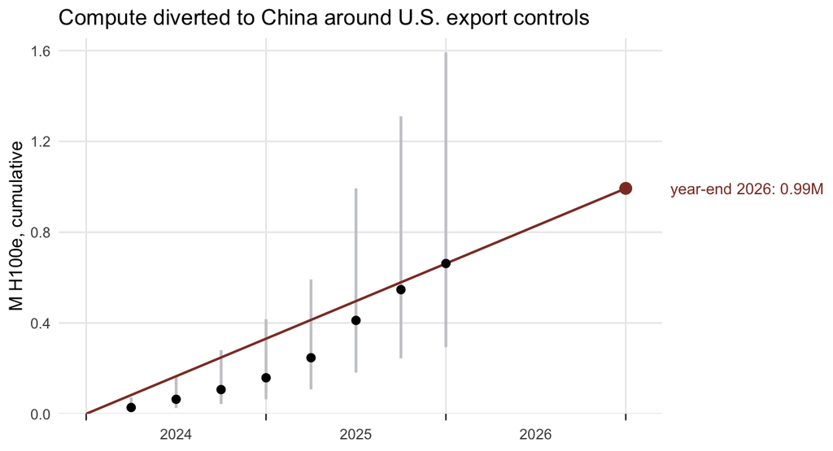

Epoch’s cumulative estimate of H100e diverted to China around U.S. export controls (points: medians; bars: 5th to 95th percentile), and the linear extrapolation to year-end 2026: a straight line from zero at the start of 2024 through the end-2025 median.

```r
ggplot(smug, aes(t, cum / 1e6)) +
  geom_linerange(aes(ymin = lo / 1e6, ymax = hi / 1e6), colour = "#C9CBCE", linewidth = 0.8) +
  annotate("segment", x = 2024, y = 0, xend = 2027, yend = smuggled.ye2026 / 1e6, colour = "#8C3B2E", linewidth = 0.7) +
  geom_point(size = 2) +
  annotate("point", x = 2027, y = smuggled.ye2026 / 1e6, colour = "#8C3B2E", size = 3) +
  year_axis(2024, 2027, limits = c(2024, 2027.05)) +
  scale_y_continuous(expand = expansion(mult = c(0, 0.04)),
                     sec.axis = dup_axis(breaks = smuggled.ye2026 / 1e6, labels = sprintf("year-end 2026: %.2fM", smuggled.ye2026 / 1e6), name = NULL)) +
  labs(x = NULL, y = "M H100e, cumulative", title = "Compute diverted to China around U.S. export controls") +
  theme_minimal(base_size = 11) + year_theme + theme(panel.grid.minor.y = element_blank(), axis.text.y.right = element_text(colour = "#8C3B2E", size = 9.5))
```

The diverted chips are a reallocation inside the world total, not an addition to it: Epoch’s cumulative sales equal the sum of the owners’ rows without the separate “China (smuggled)” row (§S.1.2.2).

**The fleet.**

```r
china.fleet.ye2026 <- china.official.2026 + smuggled.ye2026
round(c("China fleet, year-end 2026 (M H100e)" = china.fleet.ye2026 / 1e6,
        "  share of the world fleet (%)" = 100 * china.fleet.ye2026 / fleet.ye2026,
        "  as a multiple of the U.S.-located fleet" = china.fleet.ye2026 / us.fleet.ye2026), 3)
```

```
##      China fleet, year-end 2026 (M H100e)
##                                     3.111
##              share of the world fleet (%)
##                                     6.625
##   as a multiple of the U.S.-located fleet
##                                     0.088
```

**Uncertainty.** The estimate is wide, and most of the width is Epoch’s interval on the amount diverted.

```r
china.range <- china.official.2026 + 1.5 * c(low = smug$lo[nrow(smug)], median = smuggled.2025, high = smug$hi[nrow(smug)])      # Epoch's 5th / 95th percentile for smuggling, extrapolated the same way
round(rbind("China fleet, year-end 2026 (M H100e)" = china.range / 1e6,
            "  share of the world fleet (%)" = 100 * china.range / fleet.ye2026), 2)
```

```
##                                       low median high
## China fleet, year-end 2026 (M H100e) 2.56   3.11 4.51
##   share of the world fleet (%)       5.45   6.62 9.60
```

The range spans 2.6M to 4.5M, or 5.4% to 9.6% of the world fleet. It moves no qualitative conclusion anywhere downstream: §S.7.1 shows China’s transitional breakout exposure staying an order of magnitude below the U.S. figure across the whole range.

**Judgment calls.**

- **Chips diverted around U.S. export controls are included**, because they are physically in China and available to a breakout; the median is used, and the extrapolation rule is the simplest one the data allow.
- **Licensed Nvidia sales** are counted at the deliveries reported so far (0.02M). The legal ceiling is far higher (about ten buyers × 75,000), but Beijing has held imports well below it and Nvidia guides to none.
- **Direction of conservatism.** A larger Chinese fleet is the regime-unfavorable side. The diverted part of it is an extrapolation of Epoch’s central estimate of 660k H100e through 2025. Nothing downstream turns on it: §S.7.1 shows China’s transitional breakout exposure staying an order of magnitude below the U.S. figure across the whole range above.

### S.1.2.9 The leading lab’s fleet

The leading lab’s own fleet is estimated from data unrelated to any treaty parameter, which makes it an independent yardstick against which $F_E$ is checked in §S.4.5.

**The data, and the fitted path.**

- **F₀ = 1.7M H100e at end-2025.** You (2026, Epoch AI, 2026-05-20): “OpenAI had the equivalent of around 1.7 million Nvidia H100 GPUs by the end of 2025”, from OpenAI’s disclosed 1.9 GW of data-center power. Epoch’s AI Chip Users hub (Epoch AI 2026f; updated 2026-09-09; `data/ai_chip_users_year_end_by_lab.csv`) now gives the same estimate with an interval:

```r
cu <- read.csv("data/ai_chip_users_year_end_by_lab.csv", stringsAsFactors = FALSE)
cu25 <- cu[cu$Year == 2025, c("Lab", "h100e_p5", "h100e_med", "h100e_p95")]
cu25[, -1] <- round(cu25[, -1] / 1e6, 2); cu25[order(-cu25$h100e_med), ]
```

|  | Lab | h100e_p5 | h100e_med | h100e_p95 |
| --- | --- | --- | --- | --- |
| 9 | OpenAI | 1.25 | 1.74 | 2.19 |
| 7 | Google DeepMind | 1.01 | 1.58 | 2.55 |
| 10 | Anthropic | 0.84 | 1.19 | 1.72 |
| 8 | Meta Superintelligence Labs | 0.61 | 1.00 | 1.64 |
| 11 | SpaceXAI | 0.59 | 0.63 | 0.79 |

```r
oa <- cu[cu$Lab == "OpenAI", ]; c("OpenAI growth 2024->2025 (x)" = oa$h100e_med[oa$Year == 2025] / oa$h100e_med[oa$Year == 2024],
                                   "2023->2024 (x)" = oa$h100e_med[oa$Year == 2024] / oa$h100e_med[oa$Year == 2023])
```

```
## OpenAI growth 2024->2025 (x)               2023->2024 (x)
##                         4.51                         3.77
```

**More recent data: OpenAI’s fleet through 2026 from Epoch’s AI Data Centers hub.** The year-end series stops at December 2025, but the data-centers hub (snapshot 2026-09-11; `data/data_centers.csv` and `data/data_center_timelines.csv`) lists the sites that Epoch tags as used by OpenAI, each with dated construction milestones and the H100e online at each. Epoch attaches a confidence level to each tag (confident, likely or speculative); every tagged site is included here, and a site shared with another user is counted whole. Summing the latest milestone per site gives OpenAI’s *tracked* capacity over time. Tracked sites (Stargate, Fairwater, CoreWeave) do not include generic Azure regions or other clouds, so tracked capacity at end-2025 (about 1.2M) is roughly 70% of the Chip Users estimate (1.74M); the first table below scales the tracked series by that ratio.

```r
dc <- read.csv("data/data_centers.csv", check.names = FALSE, stringsAsFactors = FALSE)
tl <- read.csv("data/data_center_timelines.csv", check.names = FALSE, stringsAsFactors = FALSE)
tl$date <- as.Date(tl$Date); tl$h <- suppressWarnings(as.numeric(tl[["H100 equivalents"]])); tl$h[is.na(tl$h)] <- 0
oa.sites <- dc$Name[grepl("OpenAI", dc$Users, ignore.case = TRUE) | grepl("OpenAI", dc$Owner, ignore.case = TRUE)]
t.oa <- tl[tl[["Data center"]] %in% oa.sites, ]
snapshot <- as.Date("2026-09-11")
latest.h <- function(site, dt) { x <- t.oa[t.oa[["Data center"]] == site & t.oa$date <= dt, ]; if (nrow(x) == 0) 0 else x$h[which.max(x$date)] }
tracked <- function(dt) sum(sapply(oa.sites, latest.h, dt = dt))
coverage <- oa$h100e_med[oa$Year == 2025] / tracked(as.Date("2025-12-31"))          # Chip Users / tracked at end-2025
key <- as.Date(c("2025-12-31", "2026-03-31", "2026-06-30", "2026-09-11"))                 # realized dates only
data.frame(date = key, tracked.M = round(sapply(key, tracked) / 1e6, 2),
           scaled.by.coverage.M = round(coverage * sapply(key, tracked) / 1e6, 2),
           path.2.5x.M = round(1.74 * 2.5^(as.numeric(key - as.Date("2025-12-31")) / 365.25), 2),
           path.3.5x.M = round(1.74 * 3.5^(as.numeric(key - as.Date("2025-12-31")) / 365.25), 2),
           path.4x.M   = round(1.74 * 4.0^(as.numeric(key - as.Date("2025-12-31")) / 365.25), 2))
```

| date | tracked.M | scaled.by.coverage.M | path.2.5x.M | path.3.5x.M | path.4x.M |
| --- | --- | --- | --- | --- | --- |
| 2025-12-31 | 1.23 | 1.74 | 1.74 | 1.74 | 1.74 |
| 2026-03-31 | 1.37 | 1.94 | 2.18 | 2.37 | 2.45 |
| 2026-06-30 | 2.55 | 3.61 | 2.74 | 3.24 | 3.46 |
| 2026-09-11 | 2.84 | 4.01 | 3.29 | 4.16 | 4.56 |

Reading: scaled tracked capacity reached about 4.0M by the September 2026 snapshot, just under the 3.5×/yr path (4.2M) and above the 2.5× path (3.3M). The realized data through 2026 are consistent with 3.5×/yr.

**Quarterly trend of realized capacity.** Realized points: Epoch’s Chip Users year-end estimates for 2023–2025, and for 2026 the tracked capacity at each quarter-end (and at the snapshot) scaled by the end-2025 coverage ratio. A log-linear fit through these points gives OpenAI’s fitted path F̂(t), with no intercept forced. It is used only through year-end 2026, the pause date (§S.4.5, §S.4.6). It is not a projection for later years: left to run, it would reach about 400M H100e at year-end 2029, more than half the world stock of §S.1.2.4.

```r
yrs.since <- function(dt) as.numeric(dt - as.Date("2025-12-31")) / 365.25
q.2026 <- as.Date(c("2026-03-31", "2026-06-30", "2026-09-11"))
real <- rbind(data.frame(date = as.Date(sprintf("%d-12-31", 2023:2025)), h = oa$h100e_med[match(2023:2025, oa$Year)], source = "Chip Users year-end"),
              data.frame(date = q.2026, h = coverage * sapply(q.2026, tracked), source = "tracked sites x coverage"))
real$t <- yrs.since(real$date)
fit.oa <- lm(log(h) ~ t, data = real)
g.fit <- exp(coef(fit.oa)[["t"]]); F.fit.2025 <- exp(coef(fit.oa)[["(Intercept)"]])     # fitted growth x/yr and fitted level at end-2025
list(realized = data.frame(real[, c("date", "source")], M.H100e = round(real$h / 1e6, 2)),
     "fitted growth x/yr" = round(g.fit, 2), "fitted level at end-2025 (M)" = round(F.fit.2025 / 1e6, 2),
     "fitted path at year-end 2026 (M)" = round(F.fit.2025 * g.fit / 1e6, 2))
```

```
## $realized
##         date                   source M.H100e
## 1 2023-12-31      Chip Users year-end    0.10
## 2 2024-12-31      Chip Users year-end    0.39
## 3 2025-12-31      Chip Users year-end    1.74
## 4 2026-03-31 tracked sites x coverage    1.94
## 5 2026-06-30 tracked sites x coverage    3.61
## 6 2026-09-11 tracked sites x coverage    4.01
##
## $`fitted growth x/yr`
## [1] 3.98
##
## $`fitted level at end-2025 (M)`
## [1] 1.6
##
## $`fitted path at year-end 2026 (M)`
## [1] 6.38
```

- **The fitted growth rate.** You (2026) says OpenAI’s compute “grew around 4× annually” through 2025 and reads OpenAI’s own 2027 forecast (“low double-digit GW”) as 2.5×/yr. The log-linear fit through the six realized points gives 3.98×/yr and 1.6M at end-2025 (not forced through the Chip Users 1.74M), which puts the lab at 6.4M H100e at year-end 2026, 14% of the world stock of §S.1.2.4.

### S.1.2.10 The trajectories together

§S.5.7 puts the world, U.S.-located and Chinese stocks on one logarithmic scale, together with the two violator fleet sizes $F_E$ and $F_B$, and discusses how robust each of them is. It sits there rather than here because it needs $F_E$ and $F_B$, which are derived in §S.4 and §S.5; nothing in §S.1 depends on a treaty quantity.

## S.1.3 The dollar value of compute

**Adopted: roughly $25,000 per H100e for installed accelerators treated as movable property, with a $15,000–$35,000 bracket.**

Several arguments in §6.4 and §6.5 are easier to weigh in money than in H100e: how much hardware would have to go missing for a dark-compute scenario to be real, what a state would forgo by hiding rather than operating its fleet, and what a buy-back would cost. Two figures in Epoch’s snapshots bracket the conversion, and they differ by a factor of more than two because they measure different things.

```r
numd <- function(x) suppressWarnings(as.numeric(gsub("[$,]", "", x)))
sal.c <- sal                                                                     # Epoch's chip-sales timeline, loaded in section S.1.2.2
sal.c$C <- numd(sal.c[["Cost Estimate (USD)"]]); sal.c$Hc <- numd(sal.c[[Hcol]])
sal.c$yr <- as.numeric(format(as.Date(sal.c[["Start date"]]), "%Y"))
cs <- sal.c[!is.na(sal.c$C) & !is.na(sal.c$Hc) & sal.c$C > 0 & sal.c$Hc > 0, ]
cs$nvidia <- cs[["Chip manufacturer"]] == "Nvidia"
per <- function(d) sum(d$C) / sum(d$Hc)
by.yr <- do.call(rbind, lapply(sort(unique(cs$yr)), function(y)
  data.frame(year = y, all.accelerators = per(cs[cs$yr == y, ]), nvidia.only = per(cs[cs$yr == y & cs$nvidia, ]))))
print(format(by.yr, digits = 4, big.mark = ","), row.names = FALSE)
```

```
##   year all.accelerators nvidia.only
##  2,022           35,709      36,318
##  2,023           24,896      26,602
##  2,024           21,499      25,801
##  2,025           14,148      17,061
##  2,026           14,974      16,605
```

```r
c("2025-26 shipments, Nvidia only ($ per H100e)" = per(cs[cs$yr >= 2025 & cs$nvidia, ]),
  "2025-26 shipments, all designers ($ per H100e)" = per(cs[cs$yr >= 2025, ]),
  "annual decline 2022 -> 2025, Nvidia only (x per year)" =
    (per(cs[cs$yr == 2022 & cs$nvidia, ]) / per(cs[cs$yr == 2025 & cs$nvidia, ]))^(1 / 3))
```

```
##          2025-26 shipments, Nvidia only ($ per H100e)
##                                              16838.48
##        2025-26 shipments, all designers ($ per H100e)
##                                              14502.47
## annual decline 2022 -> 2025, Nvidia only (x per year)
##                                                  1.29
```

**The chip.** Epoch’s chip-sales timeline carries a cost estimate for every shipment row. Over 2025–26 shipments those estimates work out at about $17k per H100e for Nvidia data-center GPUs ($43k for a B300, $37k for a B200) and about $15k across all designers. The all-designer figure is lower because captive silicon is costed internally rather than sold: TPU v6e is about $4k a chip and TPU v7 about $12k. For hardware that someone has to buy, or that a thief has to fence, the Nvidia figure is the relevant one.

**The installed site.** Epoch’s data-center directory carries a total capital cost for each tracked site, which includes the building, the power and cooling plant, and the networking as well as the accelerators.

```r
dcc <- read.csv("data/data_centers.csv", check.names = FALSE, stringsAsFactors = FALSE)
dcc$Hc <- numd(dcc[["Current H100 equivalents"]]); dcc$K <- numd(dcc[["Current total capital cost (2025 USD billions)"]]) * 1e9
dcc <- dcc[!is.na(dcc$Hc) & !is.na(dcc$K) & dcc$Hc > 0 & dcc$K > 0, ]
c("sites with both figures" = nrow(dcc), "H100e covered (M)" = sum(dcc$Hc) / 1e6, "capital covered ($B)" = sum(dcc$K) / 1e9,
  "all-in capital, aggregate ($ per H100e)" = sum(dcc$K) / sum(dcc$Hc),
  "  median site" = median(dcc$K / dcc$Hc), "  lower quartile" = quantile(dcc$K / dcc$Hc, 0.25),
  "  upper quartile" = quantile(dcc$K / dcc$Hc, 0.75))
```

```
##                 sites with both figures                       H100e covered (M)
##                                    69.0                                    13.9
##                    capital covered ($B) all-in capital, aggregate ($ per H100e)
##                                   502.2                                 36033.7
##                             median site                      lower quartile.25%
##                                 33267.3                                 31328.2
##                      upper quartile.75%
##                                 42961.5
```

```r
usd <- function(x) format(signif(x, 2), big.mark = ",", scientific = FALSE)               # 36,000, not 3.6e+04
```

The 69 sites that carry both figures hold 13.9M H100e against $502B of capital, or about $36,000 per H100e; the median site is $33,000 and the interquartile range is $31,000–$43,000. That is 2.1 times the bare silicon.

**The value adopted.** Hardware that goes missing is neither of these. A building does not walk out of a data center, but a server does, and a server is more than its accelerators: CPUs, memory, the interconnect fabric and the chassis. The figure used here is **$25k per H100e**, between the two measured ends and closer to the chip; it is an interpolation, not itself a measurement, and the $15k–$35k bracket is what the two Epoch figures support.

```r
usd.per.h100e <- 25e3                                                     # judgmental input, between chip (~$17k) and all-in site (~$36k)
q <- c("10k H100e" = 10e3, "100k H100e" = 100e3, "300k H100e" = 300e3, "1M H100e" = 1e6)
round(q * usd.per.h100e / 1e9, 2)                                         # $ billions
```

```
##  10k H100e 100k H100e 300k H100e   1M H100e
##       0.25       2.50       7.50      25.00
```

So ten thousand H100e unaccounted for is about $0.25B of hardware and a million is $25B; §S.6.6 prices the dark-compute scenarios themselves. The fleets are larger still: the U.S.-located fleet of §S.1.2.7 is about $880B and China’s about $77B at the same rate.

**Judgment calls.**

- *Which price.* Replacement cost, resale value and book value differ, and for hardware under export control they can differ by a lot in either direction. The figure here is a replacement-cost reading: what a state would have to spend to reconstitute what went missing. A resale reading would be lower for older generations and, on reported grey-market behaviour, higher for controlled parts in controlled destinations; this notebook does not attempt either.
- *Which rating.* Epoch’s cost estimates are paired with Epoch’s H100e, which takes a Blackwell chip at 2.53 H100e (§S.0). At the lower of NVIDIA’s two ratings, 2.28, the same chip counts for about 10% fewer H100e and the dollar figure per H100e would be about 10% higher. Both readings sit inside the bracket.
- *Direction of travel.* The price per H100e fell about 1.3× a year from 2022 to 2025 and was flat from 2025 to 2026. If the decline resumes, a fixed count of H100e becomes cheaper to assemble over time, which makes a dark fleet easier to build and cuts against durability; a fixed sum of money buys correspondingly more. Under a pause the direction could reverse, since new training-capable production would stop while demand for the installed base continued.
- *Direction of conservatism.* A lower dollar figure makes hiding hardware look cheaper and the regime’s task harder. $25k is a central choice, not a conservative one; $15k is the regime-unfavorable end of the bracket.

# S.2 Compute ceiling C_T and parameter ceiling N_T (Table 3.1; §3.2.2, fn 21; §6.2.4)

**Adopted: the treaty compute ceiling $C_T = 2\times10^{24}$ FLOP and the parameter ceiling $N_T = 13$B parameters.**

## S.2.1 C_T = β_T · C_F

$C_T$ is indexed to the frontier: $C_T = \beta_T \cdot C_F$ with $\beta_T = 10^{-3}$, “three orders of magnitude below $C_F$” (§6.2.4). $\beta_T$ is a judgmental input. Two considerations favour a higher ceiling: enforceability (a higher $C_T$ leaves fewer legitimate runs near the threshold to police) and room for useful sub-frontier training. Two favour a lower one, and they are the purposes of the ceiling: preventing the frontier from advancing, and limiting the large-scale experimentation that drives training efficiency gains.

```r
beta.T <- 1e-3
C.T <- beta.T * C.F
c(C_T = C.T)
```

```
##   C_T
## 2e+24
```

$C_T = 2\times10^{24}$ is the training compute of the 2022–2023 frontier (PaLM-540B, GPT-3.5, Claude 2), but a model trained at that budget today is far more capable than those were. Many recent models were trained within a factor of two of $C_T$. The frontier subset used in §S.1.1 contains none of them, so the table below reads Epoch’s complete AI Models database (`data/all_ai_models.csv`, Epoch AI 2026j, retrieved 2026-09-18): it counts the models released since the start of 2025 whose estimated training compute lies between $C_T$ / 2 and 2 · $C_T$, and lists a named selection of the widely known ones with their parameter counts.

```r
allm <- read.csv("data/all_ai_models.csv", check.names = FALSE, stringsAsFactors = FALSE)
allm$C <- suppressWarnings(as.numeric(allm[["Training compute (FLOP)"]])); allm$N <- suppressWarnings(as.numeric(allm$Parameters))
allm$date <- as.Date(allm[["Publication date"]])
near <- allm[!is.na(allm$C) & !is.na(allm$date) & allm$C >= C.T / 2 & allm$C <= 2 * C.T & allm$date >= as.Date("2025-01-01"), ]
N.T <- 13e9                                                                                     # derived in section S.2.2 below
c("models since 2025 within a factor of 2 of C_T" = nrow(near), "  of which with at most N_T = 13B parameters" = sum(near$N <= N.T, na.rm = TRUE),
  "  parameter count not recorded" = sum(is.na(near$N)))
```

```
## models since 2025 within a factor of 2 of C_T
##                                            61
##    of which with at most N_T = 13B parameters
##                                             8
##                  parameter count not recorded
##                                             3
```

```r
pick <- c("DeepSeek-R1", "DeepSeek-V3 (Mar 2025)", "Gemma 3 27B", "Llama 4 Maverick", "Qwen3-8B", "Kimi K2", "NVIDIA-Nemotron-Nano-12B-v2", "DeepSeek-V4-Flash")
sel <- near[match(pick, near$Model), c("Model", "Organization", "date", "C", "N")]
data.frame(model = sel$Model, organization = sel$Organization, released = sel$date, compute.FLOP = signif(sel$C, 2), parameters.B = round(sel$N / 1e9), under.N_T = sel$N <= N.T, row.names = NULL)
```

| model | organization | released | compute.FLOP | parameters.B | under.N_T |
| --- | --- | --- | --- | --- | --- |
| DeepSeek-R1 | DeepSeek | 2025-01-20 | 3.5e+24 | 671 | FALSE |
| DeepSeek-V3 (Mar 2025) | DeepSeek | 2025-03-24 | 3.3e+24 | 671 | FALSE |
| Gemma 3 27B | Google DeepMind | 2025-03-12 | 2.3e+24 | 27 | FALSE |
| Llama 4 Maverick | Meta AI | 2025-04-05 | 2.2e+24 | 400 | FALSE |
| Qwen3-8B | Alibaba | 2025-04-29 | 1.8e+24 | 8 | TRUE |
| Kimi K2 | Moonshot | 2025-07-11 | 3.0e+24 | 1000 | FALSE |
| NVIDIA-Nemotron-Nano-12B-v2 | NVIDIA | 2025-08-18 | 1.5e+24 | 12 | TRUE |
| DeepSeek-V4-Flash | DeepSeek | 2026-04-24 | 2.5e+24 | 284 | FALSE |

Most of these models exceed $N_T$ = 13B parameters (§S.2.2); the models under both ceilings are heavily overtrained small ones such as Qwen3-8B and Nemotron Nano. Since $C_T$ is indexed to $C_F$ it moves with that input: at $C_F = 1\times10^{27}$ it would be $1\times10^{24}$. The neighbouring choices are $\beta_T = 10^{-2}$ ($C_T = 2\times10^{25}$) and $10^{-4}$ ($2\times10^{23}$); the same database shows what has recently been trained at those budgets:

```r
band <- function(centre) { x <- allm[!is.na(allm$C) & !is.na(allm$date) & allm$C >= centre / 2 & allm$C <= 2 * centre & allm$date >= as.Date("2025-01-01"), ]; x[order(x$date), ] }
hi <- band(10 * C.T); lo <- band(C.T / 10)
list("beta_T = 1e-2, C_T = 2e25: models since 2025 within a factor of 2" = nrow(hi),
     "  examples" = data.frame(model = c("Claude 3.7 Sonnet", "Qwen3-Max", "Kimi K3"), released = hi$date[match(c("Claude 3.7 Sonnet", "Qwen3-Max", "Kimi K3"), hi$Model)], compute.FLOP = signif(hi$C[match(c("Claude 3.7 Sonnet", "Qwen3-Max", "Kimi K3"), hi$Model)], 2)),
     "beta_T = 1e-4, C_T = 2e23: models since 2025 within a factor of 2" = nrow(lo),
     "  examples" = data.frame(model = c("Qwen3-1.7B", "Phi-4-Multimodal", "Qwen3-Next-80B-A3B"), released = lo$date[match(c("Qwen3-1.7B", "Phi-4-Multimodal", "Qwen3-Next-80B-A3B"), lo$Model)], compute.FLOP = signif(lo$C[match(c("Qwen3-1.7B", "Phi-4-Multimodal", "Qwen3-Next-80B-A3B"), lo$Model)], 2)))
```

```
## $`beta_T = 1e-2, C_T = 2e25: models since 2025 within a factor of 2`
## [1] 8
##
## $`  examples`
##               model   released compute.FLOP
## 1 Claude 3.7 Sonnet 2025-02-24      3.4e+25
## 2         Qwen3-Max 2025-09-05      1.5e+25
## 3           Kimi K3 2026-07-16      2.0e+25
##
## $`beta_T = 1e-4, C_T = 2e23: models since 2025 within a factor of 2`
## [1] 18
##
## $`  examples`
##                model   released compute.FLOP
## 1         Qwen3-1.7B 2025-04-29      3.7e+23
## 2   Phi-4-Multimodal 2025-03-03      1.2e+23
## 3 Qwen3-Next-80B-A3B 2025-09-10      2.7e+23
```

At $\beta_T = 10^{-2}$ the ceiling would sit among near-frontier commercial models of 2025–2026 (Claude 3.7 Sonnet, Qwen3-Max, Kimi K3); at $10^{-4}$ it would sit among small models of a few billion parameters (Qwen3-1.7B, Phi-4-Multimodal) and sparse mixtures with a few billion active parameters (Qwen3-Next-80B-A3B). The private-evasion fleet $F_P$ (§6.2.4) scales with $C_T$.

## S.2.2 N_T from C_T via an overtraining assumption (fn 21)

Chinchilla-optimal training uses D = 20·N tokens, so C = 6·N·D = 120·N². Small commercial models are trained on far more tokens per parameter for cheaper inference: Llama-3-8B on 15T tokens versus a Chinchilla-optimal 160B, about 94×. Footnote 21 rounds this to 100× overtraining, C = 12,000·N², and $N_T$ is the parameter count whose 100×-overtrained run costs exactly $C_T$.

```r
N.chinchilla <- function(C, overtrain = 1) sqrt(C / (120 * overtrain))
data.frame(overtraining = c(1, 10, 30, 100),
           N.at.C_T.B = round(N.chinchilla(C.T, c(1, 10, 30, 100)) / 1e9, 1),
           tokens.T = round(20 * c(1, 10, 30, 100) * N.chinchilla(C.T, c(1, 10, 30, 100)) / 1e12, 1),
           example = c("dense Chinchilla-optimal model (130B)", "Llama-3-70B (15T tokens / 1.4T optimal)",
                       "", "Llama-3-8B (15T / 0.16T) -> N_T"))
```

| overtraining | N.at.C_T.B | tokens.T | example |
| --- | --- | --- | --- |
| 1 | 129.1 | 2.6 | dense Chinchilla-optimal model (130B) |
| 10 | 40.8 | 8.2 | Llama-3-70B (15T tokens / 1.4T optimal) |
| 30 | 23.6 | 14.1 |  |
| 100 | 12.9 | 25.8 | Llama-3-8B (15T / 0.16T) -> N_T |

**Judgment calls.**

- *Which mapping.* $N_T$ is set on the overtrained (100×) mapping, the strict end of the 13B–130B range that 100×–1× overtraining would give. The two ceilings bind jointly: a model is a beyond-threshold model if *either* C > $C_T$ or N > $N_T$, so a dense Chinchilla-optimal model trained at exactly $C_T$ (about 130B parameters) is above $N_T$. (For a mixture-of-experts model the Chinchilla mapping counts active parameters, so its total count would be higher still.)
- *How strict.* The purpose of the parameter ceiling is to forbid plausibly commercially competitive models, and an overtrained small model can be one, so the strict end is intended. A lower $N_T$ is also easier to enforce after the fact (parameter counts are observable at deployment) and makes $C_T$ the binding constraint only for extremely overtrained small models; it forbids parameter counts common in today’s open-weight models (Llama-3-70B, Qwen-72B), whose *compute* would in any case exceed $C_T$.
- *Mixture-of-experts.* $N_T$ counts **total** parameters, not active ones, so that a mixture-of-experts design with many experts cannot route around it (DeepSeek-V3 has 671B total / 37B active). The compute mapping C = 6·N·D uses *active* parameters; the two conventions serve different purposes and both are stated.

**Adopted: the parameter ceiling $N_T = 13$B, set on the 100× overtraining mapping and counting total parameters.**

**Direction of conservatism.** A lower $N_T$ and lower $\beta_T$ are stricter on private actors (regime-favorable for enforcement, costlier for commercial sub-frontier use); neither affects the state-level ledgers in §6.4.

# S.3 Covert evasion threshold C_E = β_E · C_F (Table 3.1; §6.2.2, fn 65)

**Adopted: the covert evasion multiple $\beta_E = 10$, and with it the covert evasion threshold $C_E = \beta_E C_F = 2\times10^{28}$ FLOP, the training compute a covert model would need to be strategically relevant against the frozen frontier.**

## S.3.1 The argument

An illicit model is served on scarce dark compute, while whitelisted models are served fast and abundantly on inference-only hardware (§6.2.2). To be *strategically relevant* the illicit model must beat the frozen frontier per token by enough to overcome that inference-time handicap. Ord (2025) summarizes the inference-scaling literature as a performance-equivalence along log(training FLOP) + $\eta$·log(inference compute), $\eta \approx 0.7$: a k-fold inference advantage for the defender is worth k^$\eta$ in training compute for the attacker. So $\beta_E$ ≈ k^$\eta$ and $C_E = \beta_E \cdot C_F$.

The defender’s advantage that is used for k is **serial inference speed**: hardwired MSICs serve Llama-3.1-8B at 17,000 tokens/s against 353 tokens/s on a B200 (Taalas n.d.), k ≈ 48. Footnote 65 gives 50^0.7 ≈ 15 and rounds *down* to $\beta_E = 10$ as the conservative choice.

```r
T.E <- 5                                               # derived in section S.4 below; needed here for F_E
F.E.of <- function(beta.E, rF = rho.F, T = T.E, U = U.F, dl = delta) h100e(rho.E.of(beta.E, rF, dl) * beta.E * C.F / (T * secs.per.yr * U))   # rho_E depends on beta_E through the blind steps
k.speed <- 17000 / 353
tab <- data.frame(eta = c(0.5, 0.7, 1.0))
tab$beta.E <- round(k.speed^tab$eta, 1)
tab$F.E.M  <- round(F.E.of(tab$beta.E) / 1e6, 2)
list(k = round(k.speed, 1), k.to.the.eta = tab)
```

```
## $k
## [1] 48.2
##
## $k.to.the.eta
##   eta beta.E F.E.M
## 1 0.5    6.9  4.19
## 2 0.7   15.1 10.01
## 3 1.0   48.2 33.50
```

```r
beta.E <- 10
C.E <- beta.E * C.F
rho.E <- rho.E.of(beta.E)                              # research overhead at beta_E (section S.4.2)
frontier.growth <- trend$growth.per.yr[1]              # 4.45x/yr from section S.1.1
c(C_E = C.E, "years of frontier progress that 10x represents" = round(log(beta.E) / log(frontier.growth), 2))
```

```
##                                            C_E
##                                       2.00e+28
## years of frontier progress that 10x represents
##                                       1.54e+00
```

## S.3.2 Why this is a floor, and the cross-checks

- **$\eta$.** Villalobos and Atkinson (2023) find 0.5–1 across tasks; Snell et al. (2024) find ≈ 1 on easy and medium problems and ≈ 0 on the hardest; Ord’s 0.7 is a rule of thumb. At $\eta = 0.5$ the speed advantage is worth 7×, at $\eta = 1$ it is worth 48×. $\beta_E = 10$ sits inside that range, below the central 15.
- **The attacker is compute-poor after training.** Whatever inference the frozen frontier can spend per task, the evader must serve its model on what is left of the same dark stock that trained it, with no legal way to replenish it. So the evader cannot spend to the point where inference scaling saturates; the per-token comparison is the right one, and it favors the defender by more than the raw chip-speed ratio.
- **Covert operating overhead.** Using an illicit model strategically means operating it without leaving tracks: restricted or laundered internet access, no public API or user base, concealment of the data center’s power and network signature, and a small circle of people who can be told the model exists. Each of these lowers the effective capability the evader can extract per token, which is a further argument that the *training* advantage needed for strategic relevance is at least the one implied by the speed ratio alone.
- **One meaningful generation (cross-check).** 10× in training compute is about 1.5 years of frontier progress at the fitted 4.45×/yr, roughly one model generation. A strategically relevant covert model being “one generation ahead” of the frozen frontier is a natural reading of the threshold, independent of the exchange-rate argument.

**Direction of conservatism.** A smaller $\beta_E$ gives a smaller $C_E$ and so a smaller $F_E$, the regime-unfavorable side. Taking 10 rather than the central 15 is conservative, and so is ignoring the covert-operating overhead.

# S.4 Covert evasion fleet F_E: U_F, ρ_E, T_E (Table 3.1; §6.2.1–6.2.2, fn 67)

**Adopted: the frontier utilization $U_F = 0.21$; the research overhead $\rho_E = 10.6$, which is the frontier research overhead $\rho_F = 6.3$ times the cost of reaching $\beta_E = 10$ in blind leaps of at most $\delta = 1/3$ of an order of magnitude; and the time horizon $T_E = 5$ years; giving a covert evasion fleet $F_E = 6.4$M H100e.**

The covert evasion fleet $F_E$ is the number of H100e that, running at frontier-lab utilization $U_F$, completes a research program of $\rho_E$ final-run-equivalents of the covert evasion threshold $C_E$ within the time horizon $T_E$:

$$F_E = \frac{\rho_E \, C_E}{T_E \, U_F},$$

converted from FLOP per second to H100e at the peak rate of §S.0. This section takes the three inputs in turn.

## S.4.1 Utilization U_F

The utilization $U_F$ is the fraction of peak throughput a frontier lab achieves over a whole training run. It is derived in §S.1.1.4 as the FLOP-weighted blend of a pretraining utilization of 0.40 and an RL utilization of 0.125 at a 40% post-training share, which gives 0.213. Each of the two is the mid-range of a published band:

- **Pretraining, 30–50%.** “Typical utilization rates for large distributed training runs are around 30-50%” (Epoch AI n.d., the AI-models estimation documentation). The calculator on that page carries a **30% default**; **the 0.40 midpoint adopted here is therefore the conservative end**, since a higher $U_F$ means smaller required fleets and so larger ledger ratios (at 0.30 the blend would be 0.192, with $F_E$ = 7.07M). Meta’s reported 38–43% for Llama-3-405B sits inside that band and corroborates the 40% midpoint. Denain and Wu (2026) use a lower 0.15–0.35 for pretraining and supervised fine-tuning, **but that is a chip-specific discount, not a competing estimate of frontier utilization**: their footnote says they use a smaller utilization than the default in Epoch’s AI models database because H800s have the same peak FLOP/s as H100s but worse memory and interconnect bandwidth. So the 30–50% adopted here is not in conflict with them. At their midpoint of 0.25 the blend would be 0.179 and $F_E$ would be 7.6M.
- **RL post-training, 5–20%.** For reinforcement learning (RL) we use Denain and Wu’s (2026) estimate, 5–20% of peak throughput, at its midpoint of 0.125. Their reason is that RL is inference-heavy, and inference runs at a lower utilization than training.
- **Post-training share, 0.40.** The share of a frontier run’s FLOP that goes to RL post-training is taken at 0.40, Epoch’s estimate for GPT-5 (§S.1.1.4). This is a conservative value. There is evidence that RL post-training has been taking up a growing part of training since then (§S.1.1.4), and a larger share would lower $U_F$ and raise every fleet threshold.

A higher $U_F$ gives a smaller $F_E$ and so larger ledger ratios, which is the regime-unfavorable direction. The 0.40 pretraining utilization (against the 30% default of Epoch’s calculator) and the 0.40 post-training share both err in that direction.

## S.4.2 Research overhead ρ_E

Before a final run can begin, the research program needs training-capable hardware for exploratory experimentation, synthetic-data generation and test runs; $\rho > 1$ is the ratio of the program’s R&D compute to the final run. Denain and Wu (2026) estimate the final-run share of R&D compute from company spending data (OpenAI’s investor documents; Z.ai’s and MiniMax’s IPO filings):

```r
share.final <- c("OpenAI 2024" = 0.096, "Z.ai" = 0.123, "MiniMax (excl. Hailuo, median)" = 0.122, "MiniMax (all)" = 0.226)
rho.of.share <- g.F^(-lag.rd) / share.final                                 # one lag's worth of frontier growth removed
data.frame(final.run.share = share.final, rho = round(rho.of.share, 1),
           rho.E.with.blind.steps = round(rho.E.of(beta.E, rF = rho.of.share), 1),
           F.E.M = round(F.E.of(beta.E, rF = rho.of.share) / 1e6, 2))
```

|  | final.run.share | rho | rho.E.with.blind.steps | F.E.M |
| --- | --- | --- | --- | --- |
| OpenAI 2024 | 0.096 | 6.3 | 10.6 | 6.39 |
| Z.ai | 0.123 | 4.9 | 8.3 | 4.99 |
| MiniMax (excl. Hailuo, median) | 0.122 | 5.0 | 8.3 | 5.03 |
| MiniMax (all) | 0.226 | 2.7 | 4.5 | 2.71 |

```r
rho.P <- rho.of.share[["Z.ai"]]                                             # trailing overhead, used for F_P in section S.8
```

**The frontier overhead $\rho_F$.** OpenAI’s 9.6% final-run share is a ratio between two things estimated for the *same* calendar year, but the R&D compute a program spends in a given year supports a final run that happens some months later, by which time the frontier has moved. Dividing the R&D by the *contemporaneous* final runs therefore overstates the overhead of a single program by roughly one lag’s worth of frontier growth. Taking that lag as four months and the growth rate as the historical $g = 4.5$ (§S.1.1.1) gives the frontier research overhead
$$\rho_F = \frac{g^{-4/12}}{0.096} = 6.31,$$
an estimate carried at full precision, and OpenAI is the only frontier-pushing lab in the sample. The same construction on Z.ai’s 12.3% share gives a **trailing overhead** $\rho_P = g^{-4/12}/0.123 = 4.92$ for a program that stays *below* the frozen frontier; it is used for the private evasion fleet in §S.8. The four-month lag and the round $g = 4.5$ are judgmental inputs; the lag lowers both overheads and so lowers every required fleet, the regime-unfavorable direction. Z.ai (Zhipu, GLM) and MiniMax are fast followers producing near-frontier open-weight models, and MiniMax’s headline figure is inflated by its Hailuo video product, which is why Denain & Wu also report the 12.2% (90% CI 6.4–23.5%) excluding it. So the sample reads as: frontier lab 6.3, fast follower 4.9 (video is a different kind of data and does not belong in the comparison).

**Blind leaps.** A research program aiming at $\beta \cdot C_F$ for a large multiple $\beta$ must either attempt a far larger blind leap than frontier companies make now, or bridge the gap from $C_F$ in several steps. The blind-leap increment $\delta$ is the largest step, in orders of magnitude, that one program can take beyond the best model it has already trained. Reaching $\beta$ then takes $n = \log_{10} \beta / \delta$ steps of $\beta^{1/n}$ each; $n$ is not rounded, and it is a whole number at the adopted values. If each step is a program with the frontier overhead $\rho_F$, the total compute is
$$\sum_{i=1}^{n} \rho_F\, \beta^{i/n}\, C_F = \rho_F\, \beta\, C_F \cdot \frac{1 - \beta^{-1}}{1 - \beta^{-1/n}}, \qquad\text{so}\qquad \rho_E = \rho_F \cdot \frac{1 - \beta_E^{-1}}{1 - \beta_E^{-1/n}}.$$
The adopted $\delta = 1/3$ is a judgmental input: each step is at most about 2.15×, roughly 6 months of frontier growth at the fitted 4.45×/yr. For $\beta_E = 10$ that is three programs, at $10^{1/3}$, $10^{2/3}$ and $10$ times $C_F$, and a factor of 1.68.

```r
dl <- c("one leap (delta = Inf)" = Inf, "delta = 1" = 1, "delta = 1/2" = 1 / 2, "delta = 1/3 (adopted)" = 1 / 3, "delta = 1/4" = 1 / 4)
data.frame(increment = names(dl), steps = blind.steps(beta.E, dl), factor = round(blind.factor(beta.E, dl), 3),
           rho.E = round(rho.E.of(beta.E, dl = dl), 1), F.E.M = round(F.E.of(beta.E, dl = dl) / 1e6, 2), row.names = NULL)
```

| increment | steps | factor | rho.E | F.E.M |
| --- | --- | --- | --- | --- |
| one leap (delta = Inf) | 1 | 1.00 | 6.3 | 3.80 |
| delta = 1 | 1 | 1.00 | 6.3 | 3.80 |
| delta = 1/2 | 2 | 1.32 | 8.3 | 5.01 |
| delta = 1/3 (adopted) | 3 | 1.68 | 10.6 | 6.39 |
| delta = 1/4 | 4 | 2.06 | 13.0 | 7.82 |

**Judgment calls** ($\rho_F$ is a published estimate adjusted for a lag; $\delta$ is a judgmental input; §6.2.2 gives the argument in full).

- *Why the frontier value and not the follower value.* The covert program aims *above* the frozen frontier ($C_E = 10 \cdot C_F$), so it either attempts a far larger blind leap than a frontier lab makes in any one run or bridges the gap in several steps; either way it is frontier-pushing work, and $\rho_F$ is the right basis for each step. The follower figures describe a leaner program that follows the frontier; with the same blind steps they would give $F_E$ = 5M at $\rho_P = 4.9$.
- *Why $\rho_E$ is above $\rho_F$.* The blind steps are the part of the argument that can be put in numbers. The rest points the same way but cannot be quantified credibly: a covert program lacks much of what a frontier lab has (the pull of riches and status on the most ambitious researchers, a steady inflow of people carrying insights from competing firms, and several concurrent research programs over which to amortize effort), and it must control its AI agents far more reliably, since a leak ends the program. In the other direction, AI agents’ engineering skills may offset some of this, and legally served frontier-model inference could take on tasks such as grading RL rollouts, at some added risk of discovery.
- *Possible overlap.* $\rho_F$ is estimated for a frontier lab whose R&D compute already includes its own intermediate and experimental models. Charging each blind step a full frontier overhead on top may overstate $\rho_E$ somewhat, the regime-favorable direction.
- *Direction of conservatism.* A lower $\rho_E$ means a smaller $F_E$ and less to police. $\rho_F$ is the estimated frontier value, not a conservative choice, and $\delta = 1/3$ is a central judgment, not the conservative end: one leap ($\delta = \infty$) gives $\rho_E = \rho_F$ and $F_E$ = 3.8M, the regime-unfavorable bound, and $\delta = 1/2$ gives 5M. The adopted program is $\rho_E \cdot C_E / U_F$ = 32M H100e-years.

## S.4.3 Time horizon T_E

The time horizon $T_E$ is the number of years the covert program is given to complete its research program. It is a judgmental input, set at five years, and it rests on two considerations.

- **Time discounting.** A capability delivered many years out is worth much less to the state pursuing it than one delivered soon; a program that needs ten years to reach $C_E$ is a different proposition from one that needs five.
- **Concealment.** Five years is already a long time to keep a large government program hidden, and every further year is another year of exposure through power, procurement and personnel.

Hardware lifetime is a supporting consideration, not the basis of the choice. The paper mentions it (§6.2.2, on maintaining a fleet past its intended retirement age without vendor service, with cloud providers’ retirement ages in fn 67), so the evidence is recorded here, and the failure rate it yields is reused in §S.1.2.6 and §S.6.3. The only published count of physical GPU replacements we have found is from the Delta supercomputer: four A100s replaced in 895 days on 448 A100s and two H100s in 146 days on 608 H100s (Cui et al. 2025), six replacements in about 1,340 GPU-years, roughly half a percent a year. Meta’s Llama-3-405B run logged 148 faulty-GPU and 72 HBM3 interruptions in 54 days on 16,384 H100s (Llama Team 2024), about 9% of GPUs a year; that is an interruption rate, not a loss rate, since “only three incidents required significant manual intervention; the rest were managed by automation.”

```r
attrition <- fail.rate[["central"]]                                                           # measured in section S.1.2.6
data.frame(T.E = c(3, 5, 7, 10), F.E.M = round(F.E.of(beta.E, T = c(3, 5, 7, 10)) / 1e6, 2),
           fleet.lost.pct.low = round(100 * (1 - exp(-fail.rate[["low"]] * c(3, 5, 7, 10))), 1), fleet.lost.pct = round(100 * (1 - exp(-attrition * c(3, 5, 7, 10))), 1),
           fleet.lost.pct.high = round(100 * (1 - exp(-fail.rate[["high"]] * c(3, 5, 7, 10))), 1))
```

| T.E | F.E.M | fleet.lost.pct.low | fleet.lost.pct | fleet.lost.pct.high |
| --- | --- | --- | --- | --- |
| 3 | 10.65 | 0.5 | 1.3 | 2.9 |
| 5 | 6.39 | 0.8 | 2.2 | 4.8 |
| 7 | 4.56 | 1.1 | 3.1 | 6.6 |
| 10 | 3.19 | 1.6 | 4.4 | 9.3 |

The Delta rate is measured on young chips at one well-supported site, and it says little about a fleet run for years without vendor service. The one long-run record we have found points the other way: on the Titan supercomputer, both the original 2014 GPUs and the replacement boards installed in 2016–2019 showed failure hazards that rose with age over their first several years (the authors’ analysis of the data released with Ostrouchov et al. 2020). The original boards, whose failures were driven by a component defect, reached 12–15% a year; the sound replacement boards started near the Delta rate, at 0.2–0.3% a year, and their hazard rose by roughly 1.6× per year of age, though much of that rise traces to a single lot. Cloud providers retire GPU generations about seven to ten years after launch (§S.1.2.6), and no published data describe failure rates at those ages. So early-life failures alone would not stop a patient evader (at the Delta rate an unreplenished fleet loses about 2% of its chips in five years and 4% in ten), while the aging behaviour that might is unmeasured. Lifetime therefore does one job here. Since a longer $T_E$ always gives a smaller $F_E$, a critic could otherwise push the horizon out to fifteen or twenty years and shrink $F_E$ toward nothing; a fleet whose chips are retired at seven to ten years cannot support such a program, so the horizon has an upper limit even though it is discounting and concealment that put it at five.

**Direction of conservatism.** A longer $T_E$ gives a smaller $F_E$: seven years would give 4.6M and ten 3.2M, against 10.6M at three. Five is the regime-unfavorable choice relative to three or four, and a judgment rather than a bound relative to longer horizons.

## S.4.4 F_E assembled

```r
F.E <- F.E.of(beta.E)                                   # rho_E = rho_F x blind-leap factor, T_E = 5, U_F = 0.21, beta_E = 10, C_F = 2e27
c("C_E / U_F (FLOP)" = C.E / U.F,
  "C_E / U_F (H100e-years)" = h100e.years(C.E / U.F),
  "x rho_E (H100e-years)" = rho.E * h100e.years(C.E / U.F),
  "F_E (H100e)" = F.E)
```

```
##        C_E / U_F (FLOP) C_E / U_F (H100e-years)   x rho_E (H100e-years)
##                9.40e+28                3.01e+06                3.19e+07
##             F_E (H100e)
##                6.39e+06
```

$F_E$ = 6,387,820 H100e at the adopted inputs ($\beta_E = 10$, $\rho_E = 10.6$, $T_E = 5$, $U_F = 0.21$), printed as 6.4M.

§6.2.2 compares this with OpenAI’s projected fleet at the end of 2026, 6.4M H100e. That figure is the log-linear fit of §S.1.2.9, through Epoch’s year-end estimates and the sites it tags as OpenAI’s, so the comparison is internal to this notebook: a covert program would need a fleet about 1 times what the leading lab is expected to have at the moment of the freeze.

## S.4.5 Cross-check: F_E against the leading lab’s fleet at the freeze

```r
oa.ye2026 <- F.fit.2025 * g.fit                                             # the fitted path of section S.1.2.9 at year-end 2026
c("leading lab's fleet at year-end 2026, on the fitted path (H100e)" = oa.ye2026, "F_E (H100e)" = F.E, "F_E / that fleet" = F.E / oa.ye2026,
  "world fleet at year-end 2026 (H100e)" = fleet.ye2026, "F_E / world fleet" = F.E / fleet.ye2026)
```

```
## leading lab's fleet at year-end 2026, on the fitted path (H100e)
##                                                         6.38e+06
##                                                      F_E (H100e)
##                                                         6.39e+06
##                                                 F_E / that fleet
##                                                         1.00e+00
##                             world fleet at year-end 2026 (H100e)
##                                                         4.70e+07
##                                                F_E / world fleet
##                                                         1.36e-01
```

The covert evasion fleet is 1.00 times the fleet the leading lab holds at the freeze on its fitted path, and 13.6% of the whole world fleet: a covert evader would need to assemble and hide roughly what OpenAI operates in the open at year-end 2026, and about twice China’s entire national fleet (§S.1.2.8). Nothing about the leading lab’s fleet enters $F_E$, which is built from $C_F$, $\beta_E$, $\rho_E$, $T_E$ and $U_F$ alone, so the near-equality is not a construction. It is, though, the right order of magnitude for a threshold meant to mark a strategically relevant program: a covert evader must field a frontier lab, not a research group.

## S.4.6 Cross-check: the construction run backwards

The second check runs the $F_E$ construction backwards over a period where the answer is known. Substituting $C_F$ for $C_E$ asks what a frontier lab would have spent to climb one order of magnitude to *today’s* frontier — that is, the 18 months of frontier progress ending at the freeze, since $\beta_E = 10$ is about 18 months on the historical trajectory. The answer can be compared with what the leading lab actually spent over the same 18 months, which is the integral of the fitted path.

```r
backcast <- h100e.years(rho.E * C.F / U.F)                                   # rho_E C_F / U_F, the program for one order of magnitude
win  <- c(-0.5, 1)                                                           # t in years from end-2025: mid-2025 to end-2026
oa.18mo <- F.fit.2025 * (g.fit^win[2] - g.fit^win[1]) / log(g.fit)           # integral of the fitted path over that window
c("back-cast program (H100e-years)" = backcast, "leading lab's compute over the same 18 months (H100e-years)" = oa.18mo,
  "back-cast as a share of it" = backcast / oa.18mo)
```

```
##                             back-cast program (H100e-years)
##                                                    3.19e+06
## leading lab's compute over the same 18 months (H100e-years)
##                                                    4.03e+06
##                                  back-cast as a share of it
##                                                    7.92e-01
```

The back-cast comes to 3.2M H100e-years, about 79% of the 4.0M H100e-years the fitted path puts into the leading lab over the same period. So the covert construction, applied to a leap the industry has just made, comes out at the scale of one frontier lab’s compute over the same period. This is a sanity check on the order of magnitude of $\rho_E$ and $U_F$ taken together, and nothing more.

# S.5 Overt breakout fleet F_B (Table 3.1; §6.2.3)

**Adopted: the overt breakout threshold $C_B = 2\times10^{29}$ FLOP — two orders of magnitude, six blind steps, above the frozen frontier — which at the frozen frontier implies the multiple $\beta_B = C_B / C_F = 100$; the research overhead $\rho_B = 11.7$; and the breakout horizon $T_B = 2$ years; giving an overt breakout fleet $F_B = 180$M H100e.**

## S.5.1 The construction

The overt breakout fleet is built by the same two formulas as the covert evasion fleet of §S.4, but the two thresholds are *fixed differently*, and the difference matters later.

$C_E$ is a **relative** quantity. A covert evader needs an advantage over the frozen frontier large enough to be strategically useful against it, so §S.3 fixes the multiple $\beta_E$ and $C_E = \beta_E C_F$ follows. If the pause began a year later, $C_E$ would be higher by a year of frontier progress: the target moves with the frontier because it is defined against it.

$C_B$ is an **absolute** capability level. A strategically decisive model is decisive whenever it arrives; nothing about it is defined relative to what came before. So $C_B$ is the fixed quantity, and

$$\beta_B = \frac{C_B}{C_F}, \qquad F_B = \frac{\rho_B \, C_B}{T_B \, U_F}.$$

The derived $\beta_B$ still earns its keep: within a pause it is what the regime holds fixed, so that $C_B(t) = \beta_B C_F(t)$ tracks training efficiency gains like every other threshold (§6.2.3). But *across* possible pause dates it is an output, not an input — the same $C_B$ names a smaller multiple the later the pause begins. That is the whole of the window-of-opportunity mechanism, and it is worked in §S.5.5.

The three inputs are taken in turn below. Only $C_B$ is new: $\rho_B$ uses the blind-leap construction of §S.4.2 at the implied multiple, and $T_B$ is a judgmental input in the same sense as $T_E$.

## S.5.2 The breakout threshold C_B

$C_B$ is not an estimate of the compute a strategically decisive model would actually take. Nobody can estimate that: such a model is, almost by definition, beyond present experience. What the treaty regime has to bound is what a *bullish would-be defector would believe*, since the states most likely to attempt a breakout are the ones most optimistic about AI progress.

It is specified here as a distance above the frozen frontier, in the same units the rest of the analysis already uses: **whole blind steps of $\delta = 1/3$ of an order of magnitude**. The adopted value is six steps, two orders of magnitude, $\beta_B = 100$ and $C_B = 2\times10^{29}$ FLOP. Specifying it this way keeps the breakout program divisible into equal steps of exactly $\delta$, so $\rho_B$ is the closed form of §S.4.2 rather than a rounded-up approximation to it.

```r
n.B    <- 6                                                       # judgmental input: blind steps above the frozen frontier
beta.B <- 10^(n.B * delta)                                        # = 100 exactly at delta = 1/3
C.B    <- beta.B * C.F                                            # the absolute capability level it names
k.of   <- function(beta, g = g.F) log(beta) / log(g)              # years of baseline progress a multiple represents
c("blind steps" = n.B, "orders of magnitude" = n.B * delta, "beta_B" = beta.B, "C_B (FLOP)" = C.B,
  "months of trajectory per blind step" = 12 * delta / log10(g.F), "years of trajectory to C_B" = k.of(beta.B))
```

```
##                         blind steps                 orders of magnitude
##                            6.00e+00                            2.00e+00
##                              beta_B                          C_B (FLOP)
##                            1.00e+02                            2.00e+29
## months of trajectory per blind step          years of trajectory to C_B
##                            6.12e+00                            3.06e+00
```

**The arrival date is a gloss, not the input.** On the race trajectory that prevailed before the pause, one blind step is 6.1 months, so six steps is about 3.1 years and the adopted $C_B$ can be described as roughly what a leader expecting a decisive model at the **end of 2029** would be aiming at. That is a way of making the number intelligible, not a forecast, and the paper says as much: the trend is used only as a translation device between a date and a compute level, and the value ultimately describes the psychology of national leaders rather than a physical quantity, so it would be negotiated rather than estimated. §S.5.5 shows what other distances imply, and what happens to the same $C_B$ if the pause starts later.

## S.5.3 The research overhead ρ_B

$\rho_B$ uses the blind-leap construction of §S.4.2 unchanged, at $\beta_B$ instead of $\beta_E$. Reaching a multiple of 100 in steps of at most $\delta = 1/3$ of an order of magnitude takes $n_B = \log_{10} \beta_B / \delta$ programs, each carrying the frontier overhead $\rho_F$:

$$\rho_B = \frac{1 - \beta_B^{-1}}{1 - 10^{-\delta}} \cdot \rho_F.$$

```r
rho.B <- rho.E.of(beta.B)                                          # rho_F x blind-leap factor at beta_B
c("blind steps n_B" = blind.steps(beta.B), "blind-leap factor" = blind.factor(beta.B), "rho_B" = rho.B, "for comparison, rho_E" = rho.E)
```

```
##       blind steps n_B     blind-leap factor                 rho_B
##                  6.00                  1.85                 11.66
## for comparison, rho_E
##                 10.60
```

The factor is close to its limit: as $\beta$ grows the sum is dominated by its last term, so the factor approaches $1/(1 - 10^{-\delta}) = 1.87$ and $\rho_B$ approaches 11.8. A breakout program is therefore charged only about 10% more overhead than the covert program, even though it aims ten times higher.

## S.5.4 The breakout horizon T_B

The breakout horizon is a judgmental input, set at two years. A breakout is overt: detection is immediate, so what protects the other states is not concealment but time. The defector must reach its target before the rest of the world can organize a response — sanctions, sabotage, or a resumption of racing with a more complete supply chain and, eventually, a larger fleet. Two years is a central judgment about how long that would take, not a conservative one; one year and three years bracket it in §S.5.5.

A longer $T_B$ gives a smaller $F_B$, and a smaller $F_B$ is the regime-unfavorable side, since $F_B$ is the ceiling a state’s overt ledger must stay under.

## S.5.5 F_B assembled, and its sensitivity to the arrival date and the horizon

```r
T.B <- 2
F.B <- h100e(rho.B * C.B / (T.B * secs.per.yr * U.F))
c("F_B at T_B = 2 (adopted)" = F.B, "F_B at T_B = 1" = F.B * 2, "F_B at T_B = 3" = F.B * 2 / 3,
  "F_B / F_E" = F.B / F.E, "F_B / world fleet at year-end 2026" = F.B / fleet.ye2026)
```

```
##           F_B at T_B = 2 (adopted)                     F_B at T_B = 1
##                           1.76e+08                           3.51e+08
##                     F_B at T_B = 3                          F_B / F_E
##                           1.17e+08                           2.75e+01
## F_B / world fleet at year-end 2026
##                           3.74e+00
```

$F_B$ = 175,665,057 H100e at the adopted inputs, printed as 180M. It is 27.5 times the covert evasion fleet and 3.7 times the whole world accelerator fleet at year-end 2026 (§S.1.2.4), so on this construction no state’s year-end 2026 holdings come close to a breakout fleet: the U.S.-located fleet of §S.1.2.7 is 20% of it.

**Moving the target.** The ladder is in whole blind steps, with the arrival date carried alongside as the gloss it is.

```r
ar <- data.frame(n.B = 3:8)
ar$oom      <- ar$n.B * delta
ar$beta.B   <- 10^ar$oom
ar$C.B      <- signif(ar$beta.B * C.F, 2)
ar$rho.B    <- rho.E.of(ar$beta.B)
for (tb in 1:3) ar[[sprintf("F.B.M.T%d", tb)]] <- h100e(ar$rho.B * ar$beta.B * C.F / (tb * secs.per.yr * U.F)) / 1e6
gloss <- function(k) { w <- k %% 1                                        # k years after a year-end 2026 pause
  sprintf("~%s %d", ifelse(w < 0.25 | w >= 0.75, "end", "mid"), 2026 + floor(k) + (w >= 0.25)) }
ar$arrival  <- gloss(k.of(ar$beta.B))
print(format(ar, digits = 3), row.names = FALSE)
```

```
##  n.B  oom beta.B     C.B rho.B F.B.M.T1 F.B.M.T2 F.B.M.T3   arrival
##    3 1.00   10.0 2.0e+28  10.6     31.9     16.0     10.6 ~mid 2028
##    4 1.33   21.5 4.3e+28  11.2     72.9     36.5     24.3 ~end 2028
##    5 1.67   46.4 9.3e+28  11.5    161.2     80.6     53.7 ~mid 2029
##    6 2.00  100.0 2.0e+29  11.7    351.3    175.7    117.1 ~end 2029
##    7 2.33  215.4 4.3e+29  11.7    761.0    380.5    253.7 ~mid 2030
##    8 2.67  464.2 9.3e+29  11.7   1643.7    821.8    547.9 ~end 2030
```

Each step multiplies $C_B$, and so very nearly $F_B$, by $10^{\delta} = 2.15$, since $\rho_B$ barely moves once the program is more than a step or two long. The adopted six steps give 180M at $T_B = 2$ and 350M at $T_B = 1$. A more bullish leader at **four steps** — $4/3$ of an order of magnitude, $\beta_B = 21.5$, printing 22, $C_B = 4.3\times 10^{28}$ FLOP, roughly an end-2028 arrival — gives **$F_B = 36$M** at $T_B = 2$ and **73M** at $T_B = 1$.

That four-step figure is where the breakout allowance starts to bite. A quarter of it (the allowance $\alpha_B$ of §S.7.5) is 9.1M against a U.S.-located fleet of 35M, so the transitional exposure of §6.4.2 breaches the allowance there; at the adopted 180M the same quarter is 44M and it does not.

**A later pause: the same $C_B$, a smaller $\beta_B$.** Because $C_B$ is absolute it does not move if the pause begins later — but the frozen frontier does, so the multiple shrinks. One blind step is 6.1 months of trajectory, so **roughly every half-year of delay removes one blind step from the breakout program**: a target six steps above a year-end 2026 frontier is about five steps above a mid-2027 frontier and about four above a year-end 2027 one. Step counts are not rounded: the last step may be partial.

```r
delay <- c(0, 0.5, 1, 1.5, 2)                                            # years by which the pause starts later than year-end 2026
dl <- do.call(rbind, lapply(c("four steps" = 4, "six steps (adopted)" = 6), function(n) {
  cb <- 10^(n * delta) * C.F                                             # C_B fixed: an absolute capability level
  data.frame(target = sprintf("%d steps", n), delay.yr = delay, C.F.at.pause = signif(C.F * g.F^delay, 2),
             beta.B = cb / (C.F * g.F^delay), oom = log10(cb / (C.F * g.F^delay)),
             F.B.M = h100e(rho.E.of(cb / (C.F * g.F^delay)) * cb / (T.B * secs.per.yr * U.F)) / 1e6) }))
print(format(dl, digits = 3), row.names = FALSE)
```

```
##   target delay.yr C.F.at.pause beta.B    oom F.B.M
##  4 steps      0.0      2.0e+27  21.54 1.3333  36.5
##  4 steps      0.5      4.2e+27  10.16 1.0067  34.5
##  4 steps      1.0      9.0e+27   4.79 0.6801  30.2
##  4 steps      1.5      1.9e+28   2.26 0.3535  21.3
##  4 steps      2.0      4.0e+28   1.06 0.0269  20.5
##  6 steps      0.0      2.0e+27 100.00 2.0000 175.7
##  6 steps      0.5      4.2e+27  47.14 1.6734 173.7
##  6 steps      1.0      9.0e+27  22.22 1.3468 169.5
##  6 steps      1.5      1.9e+28  10.48 1.0202 160.5
##  6 steps      2.0      4.0e+28   4.94 0.6936 141.5
```

At a mid-2027 pause the four-step target is 1.01 orders of magnitude above the frontier — about three steps — and the adopted six-step target is 1.67, about five steps. $F_B$ itself declines only gently, because $C_B$ is fixed and $\rho_B$ falls slowly as the steps shrink in number; what moves is everything it is compared against. The installed fleet grows at the world-flow rate of §S.1.2.4, roughly 2.4× a year, so the breakout exposure as a share of $F_B$ **worsens with delay at close to the rate the fleet grows**. The covert side goes the other way: $C_E$ is relative, so $F_E$ grows with the frontier and the covert ratios improve. That asymmetry — delay eases covert verification and tightens breakout deterrence — is the quantitative core of a window-of-opportunity argument, and it follows directly from $C_E$ being relative and $C_B$ absolute.

The last row is the starker point. By a year-end 2028 pause the four-step target sits $0.03$ orders of magnitude above the frozen frontier — it has been all but overtaken. The model our bullish leader expected to be decisive is by then roughly the frontier itself, and a regime freezing there would be freezing at a capability level that leader already considered transformative. Nothing in the ledger arithmetic registers that; it is the reason a window-of-opportunity argument has to rest on more than these ratios.

## S.5.6 Judgment calls

- **$\beta_B$ is a belief, not a measurement**, and it is the input every ledger percentage in §6.4–6.5 is divided by. A smaller $\beta_B$ gives a smaller $F_B$, the regime-unfavorable side, so the end-2029 default is conservative relative to later arrival dates and optimistic relative to earlier ones. The paper says explicitly that this value would be negotiated.
- **The trend extrapolation.** $g^k$ translates a date into a multiple using a rate fitted to 2020–2025 data. Three years past the freeze is a long way to carry it, and a pause would itself bend the trajectory by design. The translation is offered for intuition, as §6.2.3 and its footnote say, not as a forecast.
- **$\rho_B$ inherits every judgment behind $\rho_E$** (§S.4.2): the estimated $\rho_F$, the four-month lag, the blind-leap increment $\delta$, and the possibility that a frontier lab’s R&D compute already contains its own intermediate-scale staircase, which would make multiplying by the blind-leap factor a double count in the regime-favorable direction.
- **Direction of conservatism, overall.** The regime-unfavorable choice here is the end-2029 arrival date (rather than a later one). $T_B = 2$ is a central judgment; one year and three years are shown beside it in §S.5.5.

## S.5.7 Reference magnitudes: the installed stocks against $F_E$ and $F_B$

This is the reference figure for the opening of §6.2: the hardware that exists, on one scale, against the two violator fleet sizes the rest of §6.2 derives and §6.4 compares every ledger line with. It sits here in the supplement, rather than with the fleet trajectories in §S.1.2, because the chunk needs $F_E$ and $F_B$ to draw them; both quantities are in the paper’s Table 3.1.

The figure below puts the world stock, the U.S.-located stock and China’s stock on one logarithmic scale, with the shaded bands showing how far each could move under the alternatives considered above. The chips diverted to China around U.S. export controls are counted inside China’s line and are not drawn as a series of their own; they are what gives China’s band its width. What the bands do *not* show is that the three series are known to very different degrees, so the reading below the figure matters as much as the figure.

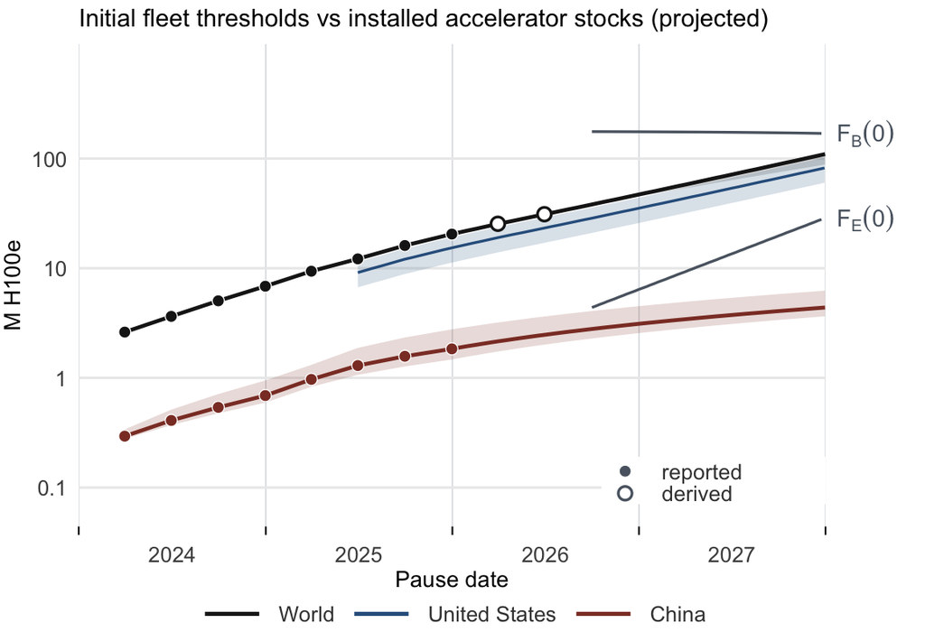

Filled circles mark values a source reports; open circles mark values derived here from contemporaneous data (the world stock in the first two quarters of 2026, gap-filled against partial 2026 records); everything else after end-2025 is an extrapolation and is drawn as a line only, through year-end 2027. Lines are solid where Epoch’s quarterly owner data run, to end-2025, and modelled thereafter: the world flow gap-filled through Q2 2026, then grown at 2.41x per year. The United States is drawn as a band rather than a line because no dataset measures it: it is an uncertain fraction of a well-determined world total, and the series starts only at the first measurement of that fraction (Epoch’s GPU-clusters set, through June 2025). The band spans what the data alone permit, from Synergy’s 55% all-workload hyperscale share to the hub’s 94% share of tracked capacity; the thin line inside it is the adopted 0.75. The two grey curves, labelled on the right, are the violator fleet sizes $F_E$ (§S.4.4) and $F_B$ (§S.5.5) as functions of the pause date, for pause dates from 1 October 2026: read at any date, each is the initial value a pause beginning then would face. $F_E$ rises with the frontier (4.5x per year), because the covert evasion threshold is relative to it; $F_B$ drifts slightly down, because the breakout threshold $C_B$ is fixed and a later pause leaves fewer blind steps to it. Once a pause begins, both fall with training efficiency gains, which the curves do not show. Shaded bands: for the world, flow growth of 1.75x to 2.56x per year; for China, whose line includes the chips diverted around U.S. export controls, Epoch’s 5th and 95th percentiles on that diverted stock.

```r
qe     <- function(d) as.Date(d)
ow     <- own[own[["End date"]] <= "2025-12-31", ]                                  # complete quarters only
agg    <- function(d, col = Hcol) tapply(d[[col]], d[["End date"]], sum)
w.obs  <- agg(ow[ow$Owner != "China (smuggled)", ]) + sum(a100.pre$h); cn.obs <- agg(ow[ow$Owner == "China", ]) + a100.mix[["China"]] * sum(a100.pre$h)   # with the A100s sold before 2022
sm.obs <- agg(ow[ow$Owner == "China (smuggled)", ])
sm.lo  <- agg(ow[ow$Owner == "China (smuggled)", ], "H100e (5th percentile)")
sm.hi  <- agg(ow[ow$Owner == "China (smuggled)", ], "H100e (95th percentile)")
yr     <- function(d) as.numeric(qe(d) - qe("2025-12-31")) / 365.25                 # the world model's clock, years from end-2025
t.mod  <- seq(0, 2, by = 1 / 24)                                                  # through year-end 2027
W.lo   <- make.W(make.world(1.75)); W.hi <- make.W(make.world(2.56))                # flow-growth alternatives, section S.1.2.5
sm.mod <- function(t, base = smuggled.2025) base * (1 + t / 2)
cn.mod <- function(t) china.official.2025 + t * sum(china.add.2026) + sm.mod(t)
cn.lo  <- function(t) china.official.2025 + t * sum(china.add.2026) + sm.mod(t, smug$lo[nrow(smug)])
cn.hi  <- function(t) china.official.2025 + t * sum(china.add.2026) + sm.mod(t, smug$hi[nrow(smug)])
us.frac.lo <- 0.55; us.frac.hi <- sum(dcs$h[dcs$us]) / sum(dcs$h)                   # what the data alone permit (section S.1.2.7)
us.start   <- "2025-06-30"                                                          # the first measurement of the U.S. FRACTION; nothing earlier measures it
gcl <- read.csv("data/gpu_clusters.csv", check.names = FALSE, stringsAsFactors = FALSE)   # that measurement: the only direct read on LOCATION
gcl$h <- suppressWarnings(as.numeric(gcl[["H100 equivalents"]])); gcl$h[is.na(gcl$h)] <- 0
gcl <- gcl[gcl$Status == "Existing" & gcl[["Include in Standard Analysis"]] %in% c(TRUE, "True", "true"), ]
us.clusters.share <- sum(gcl$h[gcl$Country == "United States of America"]) / sum(gcl$h)   # 0.76 (Pilz et al. 2025), through June 2025
us.located <- sum(dcs$h[dcs$us])                                                    # H100e physically located at U.S. sites: a floor, not plotted

cn.tot <- as.numeric(cn.obs) + ifelse(is.na(sm.obs[names(cn.obs)]), 0, sm.obs[names(cn.obs)])
## W.of() extrapolates flat before t = 0 (approx rule = 2), so it cannot be used to carry the U.S. band
## back into 2025.  W.any() uses the observed quarters before end-2025 and the model after it.
W.any  <- function(t) { kn <- rbind(data.frame(t = yr(names(w.obs)), y = as.numeric(w.obs)),
                                    data.frame(t = t.mod[t.mod > 0], y = W.of(t.mod[t.mod > 0])))
  kn <- kn[order(kn$t), ]; exp(approx(kn$t, log(kn$y), xout = t, rule = 2)$y) }
t.us   <- seq(yr(us.start), 2, by = 1 / 24)
ser <- rbind(
  data.frame(t = yr(names(w.obs)), y = as.numeric(w.obs), lo = NA, hi = NA, k = "World"),
  data.frame(t = t.mod, y = W.of(t.mod), lo = W.lo(t.mod), hi = W.hi(t.mod), k = "World"),
  data.frame(t = t.us, y = us.frac * W.any(t.us), lo = us.frac.lo * W.any(t.us), hi = us.frac.hi * W.any(t.us), k = "United States"),
  data.frame(t = yr(names(cn.obs)), y = cn.tot,
             lo = as.numeric(cn.obs) + ifelse(is.na(sm.lo[names(cn.obs)]), 0, sm.lo[names(cn.obs)]),
             hi = as.numeric(cn.obs) + ifelse(is.na(sm.hi[names(cn.obs)]), 0, sm.hi[names(cn.obs)]), k = "China"),
  data.frame(t = t.mod, y = cn.mod(t.mod), lo = cn.lo(t.mod), hi = cn.hi(t.mod), k = "China"))   # the diverted chips are inside China's line and band, not a series of their own
lev <- c("World", "United States", "China")
labs <- c("World", "United States", "China")
ser$k <- factor(ser$k, levels = lev); ser$date <- qe("2025-12-31") + round(365.25 * ser$t)

## Anchors: filled circles where a source reports the number, diamonds where we derive it here.
pts <- rbind(
  data.frame(date = qe(names(w.obs)),  y = as.numeric(w.obs),  k = "World",           kind = "reported"),
  data.frame(date = qe(names(cn.obs)), y = cn.tot,             k = "China",           kind = "reported"),
  ## open circles only where a derivation rests on contemporaneous data (the gap-filled 2026 quarters); extrapolations are lines only
  data.frame(date = qe(c("2026-03-31", "2026-06-30")), y = W.of(c(0.25, 0.5)), k = "World", kind = "derived"))
pts$k <- factor(pts$k, levels = lev); pts$kind <- factor(pts$kind, levels = c("reported", "derived"))
cols <- setNames(c("#1A1A1A", "#2E5F8C", "#8C3B2E"), lev)
tp  <- seq(yr("2026-10-01"), 2, by = 1 / 48)                                       # pause dates from 2026-10-01, on the world model's clock (t = 1 is year-end 2026)
F.E.at <- function(t) F.E * g.F^(t - 1)
F.B.at <- function(t) { cf <- C.F * g.F^(t - 1); h100e(rho.F * blind.factor(C.B / cf) * C.B / (T.B * secs.per.yr * U.F)) }
fx  <- rbind(data.frame(t = tp, y = F.E.at(tp), k = "F_E(0)"), data.frame(t = tp, y = sapply(tp, F.B.at), k = "F_B(0)"))
fx$date <- qe("2025-12-31") + round(365.25 * fx$t)

ggplot(ser, aes(date, y / 1e6, colour = k, fill = k, linetype = k)) +
  geom_ribbon(aes(ymin = lo / 1e6, ymax = hi / 1e6), colour = NA, alpha = 0.18, na.rm = TRUE) +
  ## F_E and F_B as functions of the PAUSE DATE: F_E scales with the frontier C_F; F_B holds C_B fixed (unrounded blind steps)
  geom_line(data = fx, aes(date, y / 1e6, group = k), inherit.aes = FALSE, colour = "#5A6470", linewidth = 0.6) +
  geom_line(aes(linewidth = k), na.rm = TRUE) +
  geom_point(data = pts[pts$kind == "reported", ], aes(date, y / 1e6, fill = k), inherit.aes = FALSE,
             shape = 21, colour = "white", stroke = 0.35, size = 2.4, na.rm = TRUE) +
  geom_point(data = pts[pts$kind == "derived", ],  aes(date, y / 1e6, colour = k), inherit.aes = FALSE,
             shape = 21, fill = "white", stroke = 0.9, size = 2.4, na.rm = TRUE) +
  scale_colour_manual(values = cols, labels = labs, name = NULL) +
  scale_fill_manual(values = cols, labels = labs, name = NULL) +
  scale_linetype_manual(values = c("solid", "solid", "solid"), labels = labs, name = NULL) +
  scale_linewidth_manual(values = c(0.85, 0.6, 0.85), labels = labs, name = NULL, guide = "none") +
  guides(colour = guide_legend(order = 1, override.aes = list(linewidth = 0.9, alpha = 1, shape = NA, fill = NA, linetype = "solid")),
         linetype = "none", fill = "none") +
  scale_y_log10(breaks = c(0.1, 1, 10, 100), labels = c("0.1", "1", "10", "100"), limits = c(0.07, 700),
                sec.axis = dup_axis(breaks = c(F.E.at(2), F.B.at(2)) / 1e6, labels = c(expression(F[E](0)), expression(F[B](0))), name = NULL)) +
  year_axis(2024, 2027, date = TRUE, limits = qe(c("2024-01-01", "2028-01-01")), expand = c(0, 0)) +
  labs(x = "Pause date", y = "M H100e",
       title = "Initial fleet thresholds vs installed accelerator stocks (projected)") +
  theme_minimal(base_size = 12) + year_theme +
  theme(panel.grid.minor.y = element_blank(), plot.title = element_text(size = 11.5),
        axis.text = element_text(size = 10), axis.title.y = element_text(size = 10.5), axis.title.x = element_text(size = 10.5, margin = margin(t = 2)), axis.text.y.right = element_text(size = 11, colour = "#5A6470"),
        legend.position = "bottom", legend.box = "horizontal", legend.text = element_text(size = 10, colour = "grey25"),
        legend.key.size = unit(0.9, "lines"), legend.key.width = unit(2.2, "lines"), legend.margin = margin(0, 2, 0, 2), legend.box.spacing = unit(4, "pt"),
        plot.margin = margin(4, 14, 2, 2)) +
  ## the reported/derived key, bottom right, on an opaque (but borderless) panel so the rules and
  ## gridlines behind it are hidden rather than showing through the text
  annotate("rect", xmin = qe("2026-10-20"), xmax = qe("2028-01-01"), ymin = 0.071, ymax = 0.19,
           fill = "white", colour = NA) +
  annotate("point", x = qe(c("2026-12-05", "2026-12-05")), y = c(0.141, 0.0886), shape = 21, size = 2.4,
           fill = c("#5A6470", "white"), colour = c("white", "#5A6470"), stroke = c(0.35, 0.9)) +
  annotate("text", x = qe(c("2027-02-15", "2027-02-15")), y = c(0.141, 0.0886), hjust = 0, size = 3.55, colour = "grey25",
           label = c("reported", "derived"))
```

**Reading, in order of how well each is known.**

- **The world stock is the firmest.** Epoch’s quarterly owner data run to end-2025 (20.5M), the first half of 2026 is gap-filled by us, and only the second half is modelled. At $t_0$ the flow-growth alternatives of §S.1.2.5 span 45.1–47.3M around the adopted 47M, a spread of about 5%, and an alternative gap-fill moves it by about 0.2M. That is the sense in which “47M” is robust: 66% of it is sales recorded or gap-filled through mid-2026. It loosens quickly afterwards — by mid-2027 the same alternatives span 64–73M — which is why §S.5.5’s delay analysis is more uncertain than anything evaluated at $t_0$.
- **The U.S.-located stock is not a measurement, and the figure is drawn to say so.** No dataset carries a U.S. time series, so there is no U.S. *trajectory* to plot: there is a well-determined world total and an uncertain fraction of it. It is therefore drawn as a band, not a line, and it begins only where the fraction is first measured — Epoch’s GPU-clusters set through June 2025, which puts 76% of tracked cluster performance in the United States (Pilz et al. 2025). Even that covers only about 6% of the stock. The band spans what the data alone permit, 55% (Synergy’s all-workload hyperscale share) to 94% (the hub’s share of *tracked* capacity), or 25.8–44M at year-end 2026; the thin line inside it is the adopted 0.75, whose own bracket of 0.70–0.80 (32.9–37.6M) is narrower than the band by a factor of three. It is the judgment, not the evidence, that makes $Q_{US}$ look well determined. For what it is worth as a floor, Epoch has physically located 13M H100e at U.S. sites by satellite and permit evidence — about 56% of what the adopted share claims was there in mid-2026. It is not plotted, because a single point on that scale reads as an estimate of the series rather than as a bound on it.
- **China’s stock is the weakest of the three totals**, and almost all of its weakness is in one component. Its range at $t_0$ is 2.6–4.5M around 3.11M, a factor of 1.8 from end to end.
- **The diverted stock is the least robust component of any series on the plot and the reason the China band is wide.** It is part of China’s line and is not drawn separately. Epoch’s own 5th–95th interval on the diverted stock is a factor of 5.4, and our extrapolation to $t_0$ (a straight line from zero at the start of 2024, §S.1.2.8) adds a further choice that could plausibly run from 0.33M to 0.66M of 2026 additions alone. Centrally it is 32% of China’s fleet; at the two ends of Epoch’s interval it is 17% or 53% of it.

# S.6 Dark compute (§3.3.2, §5.4–§5.5, §6.4.3, §6.5)

## S.6.1 The U.S. stock outside the seven firms

This section estimates the U.S.-located stock held outside the seven large firms, the paper’s non-hyperscale stock. §S.6.4 splits it into **named owners**, whose holdings are individually documented, and the **unnamed residual**, the long tail; the paper describes the U.S. stock in those three parts. In the code below, `us.residual` is the whole non-hyperscale stock. It is the U.S.-located stock held by owners other than the seven large firms whose inventories are presumed to be well accounted for (Google, Microsoft, Amazon, Meta, Oracle, CoreWeave, xAI): neoclouds, the federal government, firms such as Tesla and Apple, universities, and a long tail. The estimate uses one measured share and one judgmental input:

```r
other.share  <- (by.owner[["Other"]] - smuggled.2025) / stock.2025   # owners other than the seven U.S. firms and China, end-2025 (Epoch chip owners), less the chips diverted to China, which sit in this row
other.us.loc <- 0.45                                     # share of that stock located in the U.S.: judgmental input, bracketed below
us.residual  <- other.share * other.us.loc * fleet.ye2026
round(c("'Other' owners, share of the end-2025 world stock (%)" = 100 * by.owner[["Other"]] / stock.2025,
        "  less chips diverted to China around U.S. export controls (%)" = 100 * other.share,
        "evidence: U.S. share of non-China clusters under 10k H100e (Epoch GPU clusters, %)" = 100 * sum(gc$h[gc$us & gc$h < 1e4]) / sum(gc$h[!gc$cn & gc$h < 1e4]),
        "U.S. residual, year-end 2026 (M H100e)" = us.residual / 1e6, "  as % of the U.S.-located fleet" = 100 * us.residual / us.fleet.ye2026,
        "  so the seven firms hold (%)" = 100 * (1 - us.residual / us.fleet.ye2026), "China's fleet / U.S. residual" = china.fleet.ye2026 / us.residual), 1)
```

```
##                              'Other' owners, share of the end-2025 world stock (%)
##                                                                               16.8
##                       less chips diverted to China around U.S. export controls (%)
##                                                                               13.5
## evidence: U.S. share of non-China clusters under 10k H100e (Epoch GPU clusters, %)
##                                                                               45.5
##                                             U.S. residual, year-end 2026 (M H100e)
##                                                                                2.9
##                                                     as % of the U.S.-located fleet
##                                                                                8.1
##                                                        so the seven firms hold (%)
##                                                                               91.9
##                                                      China's fleet / U.S. residual
##                                                                                1.1
```

- **13.5%** is measured (Epoch AI 2026c) and carried from end-2025 to year-end 2026, on the assumption that a similar composition holds. Epoch’s “Other” row holds 16.8% of the end-2025 stock, but that includes the chips diverted to China around U.S. export controls (3.2%). Epoch’s owner rows add up to its sales totals without the “China (smuggled)” row (§S.1.2.1), so the diverted chips are already counted in one of them. The seven firms are named buyers and the “China” row is official sales, which leaves “Other”; the diverted chips are 22% of its NVIDIA part. They are located in China, so they are taken out before the location share is applied. The diverted stock is projected separately (§S.1.2.8).
- **About 45%** is a judgmental input. The holders in this bucket resemble the owners of small clusters, and in Epoch’s clusters data the U.S. hosts 41–46% of non-Chinese cluster capacity below 10k H100e (against 100% of the largest clusters). Those data do not include diverted chips, so the share applies to the rest of the bucket. Nothing measures it directly.

**Uncertainty.**

```r
res.range <- other.share * c(low = 0.30, central = 0.45, high = 0.60) * fleet.ye2026
round(rbind("U.S. residual (M H100e)" = res.range / 1e6, "  as % of the U.S.-located fleet" = 100 * res.range / us.fleet.ye2026), 1)
```

```
##                                  low central high
## U.S. residual (M H100e)          1.9     2.9  3.8
##   as % of the U.S.-located fleet 5.4     8.1 10.8
```

A location share of 0.30–0.60 gives roughly 1.9–3.8M; Epoch’s own 90% interval on the “Other” bucket is a further −34% / +42%.

The range moves no qualitative conclusion. The residual enters the ledger only through the census of §S.6.5, where about 0.3% of the stock that is not publicly identifiable goes missing, so the whole range moves $K_M$ by a few thousand H100e. It also supports the observation that the U.S. residual and China’s fleet (3.1M, range 2.6–4.5M) are of the same order.

## S.6.2 Non-deniable concealment and the one-million example

```r
scen <- c("high cooperation", "low cooperation", "non-deniable concealment")
dark.nd <- c("U.S." = 300e3, "China" = 1e6)                                      # non-deniable concealment: K_0 per state before discounting, set by the authors (§6.4.3)
round(rbind("K_0 (k H100e)" = dark.nd / 1e3, "  % of F_E" = 100 * dark.nd / F.E, "  % of F_B" = 100 * dark.nd / F.B), 3)
```

```
##                  U.S.    China
## K_0 (k H100e) 300.000 1000.000
##   % of F_E      4.696   15.655
##   % of F_B      0.171    0.569
```

Two of the paper’s three dark-compute scenarios, high and low cooperation, are derived from a model of the census (§S.6.4–§S.6.6). The third, **non-deniable concealment**, is not an estimate. Its sizes are the authors’ definitions of a stock that could not be explained as loss and would require deliberate under-declaration by a large holder: 1M H100e for China, roughly its pre-pause diverted stock (§S.1.2.8), and 300k for the United States, where a large stock would be harder to keep secret. Those are 4.7% and 16% of $F_E$, and 0.17% and 0.57% of $F_B$. The example that opens §6.4.3, a million missing H100e, is the same 16% of $F_E$.

## S.6.3 What runs out of records

A working definition of dark compute for a cooperative regime: follow the legitimate records for every chip (the vendor’s sales ledger, distributors’ and server makers’ customer records, owners’ inventories, warranty returns, recyclers’ destruction certificates) until the chain ends in a shell company, a fraud, or a chip destroyed without a confirmed record; what cannot be followed to a chip or to a confirmed disposal is dark. Every accelerator must be held by a licensed operator, so an unregistered chip is contraband whatever its owner’s size. Chips already diverted around export controls by the time the agreement takes effect are counted separately (§S.1.2.8). Large owners, in China as in the United States, are assumed to keep ordinary asset records and to recycle retired hardware through documented channels; a state could not plausibly claim otherwise.

The one line that can be computed is failed hardware:

```r
failed.by.age <- function(h, t.sale, rate, at = 2027, w = 3) { age <- at - t.sale                             # w: warranty in years
  c(all = sum(h * (1 - exp(-rate * age))), out.of.warranty = sum((h * (exp(-rate * w) - exp(-rate * age)))[age > w])) }   # failures after the warranty ran out
us.failed <- sapply(fail.rate, function(r) us.frac * failed.by.age(wm$h, wm$t.sale, r))
oq <- read.csv("data/ai_chip_owners_quarters_by_chip_type.csv", check.names = FALSE, stringsAsFactors = FALSE); oq <- oq[oq$Owner == "China", ]
oq$t <- as.numeric(substr(oq[["Start date"]], 1, 4)) + (as.numeric(substr(oq[["Start date"]], 6, 7)) - 1) %/% 3 / 4 + 0.125
cn <- aggregate(list(h = oq[[Hcol]]), list(t = oq$t), sum, na.rm = TRUE); cn <- cn[cn$t < 2026, ]
cn <- rbind(data.frame(t = a100.pre$t, h = a100.mix[["China"]] * a100.pre$h), cn)                              # China's share of the A100s sold before 2022
cn <- rbind(cn, data.frame(t = 2026 + (0:3) / 4 + 0.125, h = sum(china.add.2026) / 4))                     # China's stock excluding diverted chips: Epoch's quarterly rows, then the 2026 additions of S.1.2.8 spread over the year
cn.failed <- sapply(fail.rate, function(r) failed.by.age(cn$h, cn$t, r))
## the census (S.6.5) takes a rate that rises with age, to be conservative: the measured rate to year three, then haz.rise more per year each year
haz.rise <- 0.03
Hz <- function(a, r = fail.rate[["central"]]) r * a + 0.5 * haz.rise * pmax(a - 3, 0)^2          # cumulative hazard at age a
late.rising <- function(h, t.sale, at = 2027, w = 3) { age <- at - t.sale; sum((h * (exp(-Hz(w)) - exp(-Hz(age))))[age > w]) }
failed.rising <- c("U.S." = us.frac * late.rising(wm$h, wm$t.sale), "China" = late.rising(cn$h, cn$t))
round(rbind("U.S.: H100e failed by year-end 2026 (k)" = us.failed["all", ], "  of which after the three-year warranty ran out (k)" = us.failed["out.of.warranty", ],
            "China, excluding diverted chips: H100e failed by year-end 2026 (k)" = cn.failed["all", ], "  of which after the three-year warranty ran out (k)" = cn.failed["out.of.warranty", ]) / 1e3, 1)
```

```
##                                                                     low central
## U.S.: H100e failed by year-end 2026 (k)                            62.0   168.5
##   of which after the three-year warranty ran out (k)                1.8     4.9
## China, excluding diverted chips: H100e failed by year-end 2026 (k)  5.0    13.5
##   of which after the three-year warranty ran out (k)                0.3     0.8
##                                                                     high
## U.S.: H100e failed by year-end 2026 (k)                            364.9
##   of which after the three-year warranty ran out (k)                10.4
## China, excluding diverted chips: H100e failed by year-end 2026 (k)  29.2
##   of which after the three-year warranty ran out (k)                 1.6
```

```r
round(c("failed after the warranty if the rate rises by three points a year after year three (k): U.S." = failed.rising[["U.S."]] / 1e3, "  China, excluding diverted chips" = failed.rising[["China"]] / 1e3,
        "the rate in years four to seven on that assumption (% a year, mid-year)" = 100 * (fail.rate[["central"]] + haz.rise * (0.5 + 0:3))), 1)
```

```
## failed after the warranty if the rate rises by three points a year after year three (k): U.S.
##                                                                                          30.4
##                                                               China, excluding diverted chips
##                                                                                           4.5
##                      the rate in years four to seven on that assumption (% a year, mid-year)1
##                                                                                           1.9
##                      the rate in years four to seven on that assumption (% a year, mid-year)2
##                                                                                           4.9
##                      the rate in years four to seven on that assumption (% a year, mid-year)3
##                                                                                           7.9
##                      the rate in years four to seven on that assumption (% a year, mid-year)4
##                                                                                          10.9
```

- **Failed chips.** A chip that fails under warranty goes back to the vendor, which keeps the return under its serial number, so it rarely goes missing (the census of §S.6.5 takes 1% of these failures to leave no record). Accelerators are sold in servers that typically remain under warranty for three years (NVIDIA 2026c; Dell Technologies 2026; Hewlett Packard Enterprise 2026); the terms large operators negotiate with their manufacturers are not public. A failure after the warranty has run out could be scrapped with no record outside the owner’s own, and few chips are old enough for that: about 4.9k H100e in the U.S. (1.8–10.4k) and about 0.8k in China. That is an upper bound, since large owners scrap through certified recyclers. Those figures hold the measured rate at every age. The rate was measured on chips under three years old, and nothing measures these chips later in life, so the census of §S.6.5 takes a less favorable assumption: the measured rate to year three, then **three percentage points more per year for each further year of age** (about 2% in year four and 11% in year seven). That is a judgmental input with no source, chosen to err on the regime-unfavorable side. On it the failures after warranty are about 30k H100e in the U.S. and 4.5k in China. Chips diverted around U.S. export controls are a separate case: they carry no warranty, so none of their failures has a vendor record (§S.6.5).
- **Retired chips.** None yet (§S.1.2.6). After the agreement, licensed operators destroy retired chips verifiably, so retirement does not become a channel for losing them.
- **No data found** for two further lines. (i) *Customers of record that no longer exist, and undocumented resale:* a secondary market exists (a marketplace for used H100s and A100s opened in July 2026 reporting requests “from hundreds to tens of thousands of GPUs”; used H100s trade at roughly $18–22k), but no source gives its volume, and chips this young and supply-constrained have mostly stayed with their first owners. (ii) *Diverters’ unshipped inventory:* chips held by shell companies on the day the agreement takes effect; at the §S.1.2.8 diversion flow of about 0.3–0.5M H100e a year and a dwell time of one to three months (a guess), 30–120k worldwide, mostly in third countries.

**Reading.** On this definition the one line that can be computed is failures after the warranty, about 30k H100e in the U.S. and 4.5k in China on the rising rate, of which the census takes a tenth to leave no record (§S.6.5). What a census would miss beyond that lies in the lines that cannot, above all chips in the long tail of owners that are neither declared nor traced through records; §S.6.4 and §S.6.5 estimate that by holding type. Most of the genuinely dark stock is the diverted stock, counted separately. Two independent checks bound what a state could conceal by under-declaring *production* rather than holdings: lithography-tool usage records held by the tool and laser vendors, and above all high-bandwidth-memory shipments, which go almost entirely into accelerators at a fixed number of stacks per package (Patel, AJ, and Xie 2025: “13 million stacks of HBM” reached China before the December 2024 controls, enough for “1.6M Ascend 910C packages”; Chinese-made memory from 2026 on is outside foreign ledgers, and about half of Huawei’s 2026 units are 950PRs built on “non-HBM DRAM” for the prefill stage of inference (Somala 2026), which the memory check does not see at all).

## S.6.4 Who holds the stock: named owners, the unnamed residual, and China’s true tail

A census does two jobs (§3.3.2): it gets most chips declared, and it classifies and quantifies what is not. Both depend on who holds the chips. Owners with a sourced, individually documented holding (company filings and releases, government budgets, press reports of specific clusters, and Epoch’s data-center hub, Epoch AI 2026g) are called **named owners**. Like the seven large U.S. firms, they are presumed accounted for: audited books or public budgets, known sites, and chips that report their identity when running. The two lists are in `data/large_owners_us.csv` (75 rows) and `data/large_owners_cn.csv` (18 rows); each row carries its source and the basis of its number, and the census counts the rows marked `in_tally` = `y`. Every link in the two lists was opened and compared with its row on October 9, 2026. Rows that this check could not confirm, and that the authors did not then review themselves, are not counted and are left out of the published lists. Holdings are in Epoch’s H100e. A holding counts from the date of its evidence, so the end-2025 figures are floors.

```r
own.c <- read.csv("data/ai_chip_owners_cumulative_by_designer.csv", check.names = FALSE, stringsAsFactors = FALSE)
a100.n <- sum(a100.pre$h)                                                                                     # A100s sold before 2022 (section S.1.2.1)
nd.c <- function(e) { x <- own.c[own.c[["End date"]] == e, ]; sum(x[x$Owner == "Other", Hcol]) - sum(x[x$Owner == "China (smuggled)", Hcol]) + a100.mix[["Other"]] * a100.n }   # 'Other' less diverted
wd.c <- function(e) { x <- own.c[own.c[["End date"]] == e, ]; sum(x[x$Owner != "China (smuggled)", Hcol]) + a100.n }                                         # world, no diverted row
lo.us <- read.csv("data/large_owners_us.csv", stringsAsFactors = FALSE); lo.us <- lo.us[lo.us$in_tally == "y", ]
lo.cn <- read.csv("data/large_owners_cn.csv", stringsAsFactors = FALSE); lo.cn <- lo.cn[lo.cn$in_tally == "y", ]
held.at <- function(r, q) {       # a holding at quarter-end q: its dated milestones, or its end-2025 value from its install date
  pts <- if (nzchar(r$ms)) do.call(rbind, lapply(strsplit(strsplit(r$ms, ";")[[1]], ":"), function(z) data.frame(t = as.numeric(z[1]), v = as.numeric(z[2]))))
         else data.frame(t = numeric(0), v = numeric(0))
  if (!nzchar(r$ms)) { if (r$e25 > 0) pts <- rbind(pts, data.frame(t = ifelse(is.na(suppressWarnings(as.numeric(r$t0))), 2026, as.numeric(r$t0)), v = r$e25))
                       if (r$firm > max(c(0, pts$v))) pts <- rbind(pts, data.frame(t = 2026.75, v = r$firm)) }
  z <- pts[pts$t <= q + 1e-9, ]; if (nrow(z)) z$v[which.max(z$t)] else 0 }
named.us <- sapply(c(2024, 2025, 2026), function(q) sum(sapply(seq_len(nrow(lo.us)), function(i) held.at(lo.us[i, ], q))))
ends  <- c("2023-12-31", "2024-12-31", "2025-12-31")
tw    <- sapply(ends, nd.c) - named.us; ww <- sapply(ends, wd.c)
s.add <- mean(diff(tw) / diff(ww))                               # the unnamed tail's share of world additions, 2024 and 2025
tail25.us <- other.us.loc * nd.c("2025-12-31") - named.us[3]      # unnamed U.S. residual, end-2025
g.u   <- 1 + s.add * (fleet.ye2026 - ww[3]) / tw[3]              # 2026 growth: it keeps its share of world additions
N.us  <- unname(tail25.us * g.u)
## China: official stock (diverted chips excluded) = named + unnamed large buyers + true tail
ct.c <- read.csv("data/ai_chip_owners_cumulative_by_chip_type.csv", check.names = FALSE, stringsAsFactors = FALSE)
ct.c <- ct.c[ct.c$Owner == "China" & ct.c[["End date"]] == "2025-12-31", ]; stk.cn <- setNames(ct.c[[Hcol]], ct.c[["Chip type"]])
stk.cn[["A100"]] <- stk.cn[["A100"]] + a100.mix[["China"]] * a100.n
cn.official <- china.fleet.ye2026 - smuggled.ye2026
large.share <- c(H20 = 0.80, A800 = 0.83, H800 = 0.53, A100 = 0.53, `Instinct MI308X` = 0)
big.cn <- max(0, sum(large.share * stk.cn[names(large.share)]) - sum(lo.cn$sched[grepl("A100|A800|H800|Hopper|H20 assumed|6,500 GPUs", lo.cn$basis)])) +
          max(0, 0.79 * (stk.cn[["Siyuan 590"]] + 4 * 0.01e6) - sum(lo.cn$sched[grepl("Siyuan 590", lo.cn$basis)]))
tail.cn <- cn.official - sum(lo.cn$sched) - big.cn
cbind(value = round(c("U.S.: named owners' holdings, end-2023 (k)" = named.us[1] / 1e3, "  end-2024 (k)" = named.us[2] / 1e3, "  end-2025 (k)" = named.us[3] / 1e3,
    "  year-end 2026, including deliveries due in 2026 (M)" = sum(lo.us$sched) / 1e6,
    "U.S.: the unnamed tail's share of world additions, 2024 (%)" = 100 * unname(diff(tw) / diff(ww))[1], "  2025 (%)" = 100 * unname(diff(tw) / diff(ww))[2],
    "U.S.: unnamed residual, end-2025 (M)" = tail25.us / 1e6, "  2026 growth factor" = unname(g.u), "  year-end 2026 (M)" = unname(N.us) / 1e6,
    "China: official stock, end-2025 (M)" = sum(stk.cn) / 1e6, "  year-end 2026 (M)" = cn.official / 1e6,
    "China: named owners, end-2025 (M)" = sum(lo.cn$e25) / 1e6, "  year-end 2026 (M)" = sum(lo.cn$sched) / 1e6,
    "China: unnamed large buyers, year-end 2026 (M)" = big.cn / 1e6, "China: true tail, year-end 2026 (M)" = tail.cn / 1e6), 3))
```

```
##                                                               value
## U.S.: named owners' holdings, end-2023 (k)                   65.186
##   end-2024 (k)                                              217.929
##   end-2025 (k)                                              286.118
##   year-end 2026, including deliveries due in 2026 (M)         1.009
## U.S.: the unnamed tail's share of world additions, 2024 (%)  12.040
##   2025 (%)                                                   10.879
## U.S.: unnamed residual, end-2025 (M)                          0.962
##   2026 growth factor                                          2.219
##   year-end 2026 (M)                                           2.135
## China: official stock, end-2025 (M)                           1.175
##   year-end 2026 (M)                                           2.118
## China: named owners, end-2025 (M)                             0.335
##   year-end 2026 (M)                                           0.453
## China: unnamed large buyers, year-end 2026 (M)                0.279
## China: true tail, year-end 2026 (M)                           1.386
```

- **The U.S.** Named owners outside the seven firms hold 0.29M H100e dated to end-2025 and 1.0M at year-end 2026 if the deliveries they announce for 2026 arrive: Tesla, the Department of Energy’s laboratories, neoclouds (Nscale, Lightning AI, Lambda), universities. The **unnamed residual** is what is left of the non-hyperscale stock of §S.6.1 once they are subtracted: 0.96M at end-2025. It grows in 2026 by keeping the share of world additions that the stock outside the seven firms, China and the named owners took in 2024 and 2025 (11%), a factor of 2.2, to **2.1M** at year-end 2026. Two alternatives bracket it: no 2026 purchases (0.96M) and the 2025 growth factor carried forward (about 2.3M), which would outgrow the world stock.
- **China.** Epoch does not name Chinese owners, so the list was built from filings, tenders and press reports: the telecom operators’ owned capacity (China Mobile’s self-built 33 EFLOPS, China Telecom’s 71 EFLOPS, China Unicom’s 45 EFLOPS of unstated precision, counted at half), Huawei’s Horinger campus and a VNET campus in Ulanqab (estimates from Epoch’s data-center hub; Epoch AI 2026g), ByteDance (third-party estimates of its purchases), Alibaba’s Zhangbei site, city and national computing centres, and AI labs. Named holdings are 0.33M at end-2025 (28% of the official stock) and 0.45M at year-end 2026. Capacity stated in FP16 converts at 1 H100e per PFLOPS; capacity of unstated precision at 0.5 (the regime-unfavorable reading, since fewer named chips leave a larger tail).
- **Unnamed large buyers.** NVIDIA’s China-specific chips went mostly to a few buyers: ByteDance, Alibaba, Tencent and Baidu took more than 80% of 2024 H20 demand (a Bernstein estimate, as reported by Sina Finance 2025); four firms ordered about 100,000 A800s for 2023 delivery, 83% of Epoch’s total (Reuters 2023); ByteDance alone had about 100,000 A100 and H800 delivered or on order in mid-2023, 53% of those two chips (IT Home 2023, citing LatePost). Cambricon’s largest customer took 79% of its 2024 revenue (Cambricon Technologies 2025). Those shares, less the named holdings of the same chips, give 0.28M. **Ascend (about three quarters of the year-end 2026 official stock) has no buyer data,** so its unnamed part is all counted as tail: the **true tail** is **1.4M**. That is the regime-unfavorable reading.

## S.6.5 What a census would miss, by holding type (§5.5)

The **missing stock** $K_M(s)$ in state $s$ is what a census conducted in good faith fails to find. Each state’s stock is sorted into four **holding types** $h$, with $Q(h, s)$ the stock of type $h$. Failed chips are taken out of each type first, and a share of them is missing because no record shows that they failed. A **missing fraction** $\mu(h)$ then applies to the functional chips that remain:

$$K_M(s) \;=\; \sum_h \Big[\,D(h, s) \;+\; \mu(h)\,\big(Q(h, s) - \text{failed chips}(h, s)\big)\Big],$$

where $D(h, s)$ is the number of failed chips that go missing, the paper’s symbol.

The four holding types, in decreasing order of visibility:

- **Publicly identifiable holdings:** the seven large U.S. firms, the named owners of §S.6.4 and, in China, the named owners and the unnamed large buyers.
- **On-books business and institutional holdings:** firms, laboratories and smaller clouds that hold chips on their books and appear in the chain of sales records, but are not individually documented here. In the U.S. this is the unnamed residual less its informal part; in China, the true tail less its informal part, plus the diverted chips whose holders have some state record, such as a customs entry or a tax invoice.
- **Off-books business and institutional holdings:** chips bought without paperwork and run by an operating business or institution. Only China’s diverted stock has these.
- **Informal holdings:** individuals, and the shell companies and traders engaged in diversion, with their stock in transit.

Every rate below is a judgment or an analogy from another domain, chosen for its structure, with the direction of its bias stated.

```r
d.F <- 0.94; p.T <- 0.80                                     # on-books holdings: declaration, tracing
d.IS <- 0.80; p.IS <- 0.50                                   # off-books and informal holdings: declaration, recovery (judgmental inputs)
v.off <- 0.01                                                # share of the stock not publicly identifiable that is held informally, in both states
out.dc <- 0.10; miss.dc <- 0.06                                # business-held chips outside a data center; chips in a data center that its operator's declaration and an inspection both miss
f.site <- out.dc + miss.dc                                     # share of business-held chips not found at a site
srv <- rbind("2023" = c(small = 8.5, hyperscale = 30.0), "2025" = c(small = 6.4, hyperscale = 34.8))   # % of U.S. servers, measured from Figure 4.1 of Shehabi et al. (2024)
venue <- c(enterprise.dc = 45, colocation = 16, closet.edge = 14) / 75      # for comparison: operators' own IT by venue (Uptime Institute 2025, Figure 13)
mu <- c(0, (1 - d.F) * (1 - p.T) * f.site, (1 - d.IS) * (1 - p.IS) * f.site, (1 - d.IS) * (1 - p.IS))   # missing fraction of functional chips, by holding type
w.in <- 0.01; w.out <- 0.10; w.off <- 0.50                     # failed chips with no record made at the time: under warranty, after it, at off-books holdings (all at informal holdings)
## failed chips as a share of each group's year-end 2026 stock: at any age, and after the three-year warranty
oq.o <- read.csv("data/ai_chip_owners_quarters_by_chip_type.csv", check.names = FALSE, stringsAsFactors = FALSE); oq.o <- oq.o[oq.o[["Start date"]] <= "2025-12-31", ]
oq.o$t <- as.numeric(substr(oq.o[["Start date"]], 1, 4)) + (as.numeric(substr(oq.o[["Start date"]], 6, 7)) - 1) %/% 3 / 4 + 0.125
oq.o$h <- suppressWarnings(as.numeric(oq.o[[Hcol]])); oq.o <- oq.o[!is.na(oq.o$h), c("Owner", "t", "h")]
oq.o <- rbind(oq.o, do.call(rbind, lapply(names(a100.mix), function(o) data.frame(Owner = o, t = a100.pre$t, h = a100.mix[[o]] * a100.pre$h))))   # with the A100s sold before 2022
oow.c <- function(x, w = 3) { a <- 2027 - x$t; sum((x$h * (exp(-Hz(w)) - exp(-Hz(a))))[a > w]) }          # Hz: the rate rises after year three (S.6.3)
x7 <- oq.o[oq.o$Owner %in% us.seven, ]; xo <- oq.o[oq.o$Owner == "Other", ]; xc <- oq.o[oq.o$Owner == "China", ]
## the 2026 vintage: Epoch's owner data end in 2025, so each group's 2026 additions (its year-end 2026 stock less its end-2025 stock) are added,
## spread over the four quarters in proportion to the world model's quarterly flow
wq26 <- c(stock.q2 - q2f - ww[[3]], world.q$flow[1:3]); wq26 <- wq26 / sum(wq26); t26 <- 2026 + c(0.125, 0.375, 0.625, 0.875)
add26 <- function(x, tot) rbind(x[, c("t", "h")], data.frame(t = t26, h = max(tot, 0) * wq26))
s7 <- sum(x7$h)                                                                                               # the seven firms' end-2025 stock
x7 <- add26(x7, s7 * (fleet.ye2026 / ww[[3]] - 1)); xo <- add26(xo, other.share * (fleet.ye2026 - ww[[3]])); xc <- add26(xc, cn.official - sum(xc$h))
dv <- data.frame(t = 2024 + (0:11) / 4 + 0.125, h = smuggled.ye2026 / 12)          # diverted chips: the straight line from zero at the start of 2024
fail <- rbind(seven    = c(all = oow.c(x7, 0), late = oow.c(x7)) / (s7 * fleet.ye2026 / ww[[3]]),     # the seven keep their share of the world stock in 2026
              other    = c(all = oow.c(xo, 0), late = oow.c(xo)) / (other.share * fleet.ye2026),
              china    = c(all = oow.c(xc, 0), late = oow.c(xc)) / cn.official,
              diverted = c(all = oow.c(dv, 0), late = oow.c(dv, 0)) / smuggled.ye2026)                        # no warranty: every failure counts as after it
off.div <- 0.10; transit <- smuggled.2025 / 2 / 12             # a tenth of the diverted stock off the books; one month of diverted flow at Epoch's central rate for 2024-25, in transit
named.us26 <- sum(lo.us$sched); N7 <- us.fleet.ye2026 - N.us - named.us26; named.cn <- sum(lo.cn$sched) + big.cn
cell <- function(Q, g, win, wout, nowarranty = FALSE) { all <- Q * fail[[g, "all"]]; late <- if (nowarranty) all else Q * fail[[g, "late"]]
  c(Q = Q, failed = all, miss.failed = win * (all - late) + wout * late) }
hl <- c("publicly identifiable holdings", "on-books holdings", "off-books holdings", "informal holdings")
fin <- function(m) { dimnames(m) <- list(hl, c("Q", "failed", "miss.failed")); fun <- m[, "Q"] - m[, "failed"]
  cbind(m, functional = fun, mu = mu, miss.fun = mu * fun, missing = m[, "miss.failed"] + mu * fun) }
hold.us <- fin(rbind(cell(N7, "seven", w.in, w.out) + cell(named.us26, "other", w.in, w.out),
                     cell((1 - v.off) * N.us, "other", w.in, w.out), c(0, 0, 0),
                     cell(v.off * N.us, "other", 1, 1) + c(transit / 2, 0, 0)))                               # stock in transit has not failed
hold.cn <- fin(rbind(cell(named.cn, "china", w.in, w.out),
                     cell((1 - v.off) * tail.cn, "china", w.in, w.out) + cell((1 - off.div - v.off) * smuggled.ye2026, "diverted", w.out, w.out, TRUE),
                     cell(off.div * smuggled.ye2026, "diverted", w.off, w.off, TRUE),
                     cell(v.off * tail.cn, "china", 1, 1) + cell(v.off * smuggled.ye2026, "diverted", 1, 1, TRUE) + c(transit / 2, 0, 0)))
K.miss.us <- sum(hold.us[, "missing"]); K.miss.cn <- sum(hold.cn[, "missing"])
div.miss <- function(off = off.div, D = smuggled.ye2026) { fd <- fail[["diverted", "all"]]                    # what the diverted stock adds to China's missing stock
  D * ((1 - off - v.off) * (w.out * fd + mu[2] * (1 - fd)) + off * (w.off * fd + mu[3] * (1 - fd)) + v.off * (fd + mu[4] * (1 - fd))) }
signif(100 * fail, 3)        # failed, % of the year-end 2026 stock: all failures, and those after the warranty
```

```
##            all   late
## seven    0.521 0.0644
## other    0.763 0.1880
## china    0.803 0.2120
## diverted 0.668 0.6680
```

```r
tab <- function(m) cbind("Q (k H100e)" = round(m[, "Q"] / 1e3), "failed (k)" = round(m[, "failed"] / 1e3, 2), "failed chips missing (k)" = round(m[, "miss.failed"] / 1e3, 2),
                         "functional (k)" = round(m[, "functional"] / 1e3), "mu (%)" = signif(100 * m[, "mu"], 2), "functional missing (k)" = round(m[, "miss.fun"] / 1e3, 2),
                         "total missing (k)" = round(m[, "missing"] / 1e3, 2))
tab(hold.us); tab(hold.cn)
```

```
##                                Q (k H100e) failed (k) failed chips missing (k)
## publicly identifiable holdings       33081     174.95                     3.78
## on-books holdings                     2114      16.14                     0.52
## off-books holdings                       0       0.00                     0.00
## informal holdings                       35       0.16                     0.16
##                                functional (k) mu (%) functional missing (k)
## publicly identifiable holdings          32906   0.00                   0.00
## on-books holdings                        2098   0.19                   4.03
## off-books holdings                          0   1.60                   0.00
## informal holdings                          35  10.00                   3.50
##                                total missing (k)
## publicly identifiable holdings              3.78
## on-books holdings                           4.55
## off-books holdings                          0.00
## informal holdings                           3.66
```

```
##                                Q (k H100e) failed (k) failed chips missing (k)
## publicly identifiable holdings         732       5.87                     0.20
## on-books holdings                     2256      16.92                     0.96
## off-books holdings                      99       0.66                     0.33
## informal holdings                       38       0.18                     0.18
##                                functional (k) mu (%) functional missing (k)
## publicly identifiable holdings            726   0.00                   0.00
## on-books holdings                        2239   0.19                   4.30
## off-books holdings                         99   1.60                   1.58
## informal holdings                          37  10.00                   3.74
##                                total missing (k)
## publicly identifiable holdings              0.20
## on-books holdings                           5.26
## off-books holdings                          1.91
## informal holdings                           3.92
```

```r
round(c("K_M, U.S. (k)" = K.miss.us / 1e3, "  missing failed chips" = sum(hold.us[, "miss.failed"]) / 1e3, "  functional chips missing" = sum(hold.us[, "miss.fun"]) / 1e3,
        "K_M, China (k)" = K.miss.cn / 1e3, "  missing failed chips" = sum(hold.cn[, "miss.failed"]) / 1e3, "  functional chips missing" = sum(hold.cn[, "miss.fun"]) / 1e3,
        "  of China's K_M, from the diverted stock" = div.miss() / 1e3), 1)
```

```
##                             K_M, U.S. (k)
##                                      12.0
##                      missing failed chips
##                                       4.5
##                  functional chips missing
##                                       7.5
##                            K_M, China (k)
##                                      11.3
##                      missing failed chips
##                                       1.7
##                  functional chips missing
##                                       9.6
##   of China's K_M, from the diverted stock
##                                       5.2
```

**The formula as the paper states it.** The paper states the formula with $\mu(h)$ applied to the whole stock $Q(h, s)$ and notes (its footnote 53) that this makes no difference; the table above, like the paper’s Table 5.1, applies it to the functional chips. Failed chips are at most 0.8% of any group, and applying $\mu(h)$ to the whole stock would add 47 H100e to the U.S. total and 61 to China’s.

**Failed chips, and how many of them are missing**

- **How many have failed.** By year-end 2026, 0.52% of the seven firms’ stock has failed at some age, 0.76% of other U.S. holders’, 0.8% of China’s non-diverted stock and 0.67% of the diverted stock, which has a mean age of 1.5 years. The rate is the measured one to year three and rises by three percentage points a year after it (§S.6.3), which is on the regime-unfavorable side. Purchases are dated by quarter: through 2025 from Epoch’s owner data, and for 2026, which Epoch’s owner data do not yet cover, from each group’s additions in the world model, spread over the year’s quarters in proportion to the world flow. In all, 190k H100e of the U.S. stock and 24k of China’s have failed.
- **Under warranty: 1% missing.** A chip that fails within its three-year warranty goes back to the vendor, which records the return (§S.6.3). At publicly identifiable and on-books holdings, 1% of these failures are taken to leave no record, the vendor’s or any other made at the time. That is a judgment.
- **After the warranty: 10% missing.** Only chips bought before 2024 can have failed after year three: 0.064% of the seven firms’ year-end 2026 stock, 0.19% of other U.S. holders’ and 0.21% of China’s non-diverted stock. Any record made at the time that the chip failed and was taken out of service counts: a maintenance ticket or monitoring log, an entry in the holder’s inventory, a write-off in its books, or a recycler’s disposal record (China’s rules on waste electrical and electronic products require licensed disposal enterprises to keep data on what they process for three years; State Council of the People’s Republic of China 2009). A disposal certificate is not required. **A tenth** of these failures are taken to leave no record of any of these kinds. That is a judgment: no rule requires a record when an accelerator fails, and nothing measures how often one is kept. An operator that monitors its machines learns of a failure from its own logs, which is where the measured failure rate itself comes from (Cui et al. 2025), so a tenth is probably on the high side for data-center operators and less certain for a small business with a few machines.
- **Diverted chips have no warranty** (NVIDIA provides no support or repairs for restricted products; Olcott 2026a), so every failure of a diverted chip held on the books is counted at the after-warranty share, a tenth.
- **Off-books holdings: half missing. Informal holdings: all.** Both are judgments. A business running chips bought without paperwork still keeps operating records, taken to show half of its failures. An informal holder has nothing to show, so all of its failures count, inside the warranty period or after it.
- **In all,** the missing failed chips are 4.5k H100e in the U.S. and 1.7k in China. The U.S. figure is the larger because of the size of its publicly identifiable holdings, which account for 3.8k of it.

**Functional chips: the missing fraction**

A functional chip goes missing only if three things happen in turn: it is not found at a site; of the chips not found there, its holder does not declare it; and of those not found and not declared, the census cannot trace it from the seller’s records. The rates below are conditional in that order, as the paper states them (§5.5.2).

- **Publicly identifiable holdings: none.** Their functional chips are presumed accounted for: public filings, vendor records, known sites, chips that report their identity when running. The failed chips above are this type’s whole contribution. Chips these holders have resold are not counted: the stock counts purchases, and nothing public measures the secondary market.
- **The site: 16% not found.** A chip that escapes the paper trail but sits at an operating business is still found if it is in a data center: a colocation operator declares its tenants and their power by cage, and an enterprise data center is a known site from utility and permit records that the census can inspect. Two inputs set the share that is not found. **A tenth** of business-held chips are taken to sit outside any data center, in closets, server rooms, edge sites and small businesses’ own premises. Counted by racks, 8.5% of U.S. servers sat in such places in 2023 and 6.4% in 2025; of the servers outside hyperscale facilities, the closer comparison for holders that are not named, 12% and 10% (Shehabi et al. 2024, Figure 4.1, measured from the chart). That is all servers, not AI servers, whose power density keeps most of them out of closets; the same report’s model places every AI-accelerated server in a hyperscale or large colocation facility. So a tenth is on the regime-unfavorable side. A survey of data-center operators gives a higher figure, 19% of the IT on their own hardware (Uptime Institute 2025, Figure 13), but it averages over the operators who answered, not over hardware. **A further 6%** are taken to be in a data center and still missed, by its operator’s declaration and by its owner’s; the figure borrows the IRS rate below. The two are added, giving 16%; applying the 6% only to the nine tenths inside a data center would give 15.4%. Informal holdings have no site to inspect.
- **Undeclared, on the books: 6%.** A business that bought a chip is the end of a chain of sales records. The IRS measures that 6% of income subject to substantial third-party information reporting goes unreported (category II; Internal Revenue Service 2024, p. 16), which is used for $d_F$ = 0.94. The analogy overstates non-declaration: the IRS measures misreporting where it saves tax, whereas a chip is a capital asset already in the holder’s books and on its tax return, and under the regime declaring earns licensed use or a buyback while an undeclared chip is contraband. A business has little reason not to declare; the 6% stands for the declaration channel failing, through error or a defunct holder, and is the regime-unfavorable reading.
- **Untraced, on the books: 20%.** An ATF trace follows a gun’s serial forward from the manufacturer through wholesaler and dealer to the first retail buyer; it reached the buyer in 77% of traces over 2017–21 and 80% in 2021 (Bureau of Alcohol, Tobacco, Firearms and Explosives 2023), which is used for the tracing rate $p_T$ = 0.80. Crime guns are older and more often resold than these chips, so this analogy too is on the regime-unfavorable side.
- **Off the books and informal: 20% undeclared, half of those not recovered.** Both are judgmental inputs; no measurement applies to a holder whose purchase is off the books. Such a holder can keep a chip for the black market more easily than one whose purchase is in the tax record, so more go undeclared. With no sales record to trace from, recovery rests on other records (power, employees, customers) and on tips, taken to find half.
- **So the missing fraction** of functional chips is 0.19% for on-books holdings (16% × 6% × 20%), 1.6% for off-books holdings (16% × 20% × 50%) and 10% for informal holdings (20% × 50%).

**How each state’s stock is sorted**

- **The U.S.** The seven firms and the named owners are publicly identifiable holdings, 33M H100e. Of the unnamed residual (2.1M), 1% is taken to be held informally, a judgment that nothing measures; no evidence was found of individuals holding data-center GPUs in quantity. The rest is on the books.
- **China’s non-diverted stock.** Named owners and unnamed large buyers are publicly identifiable holdings, 730k; the true tail is split as the U.S. residual is.
- **China’s diverted stock** (0.99M: Epoch’s central estimate through 2025, carried a third year, §S.1.2.8; the same stock as everywhere else in this supplement). **A tenth** is taken to be off the books, 99k, and 1% informal, as for any stock that is not publicly identifiable. The remaining 89% is on the books (a customs entry, a tax invoice, a tender, a financing filing). The tenth is a judgment, meant to err on the high side, since a firm has to hold the invoice to claim the tax credit; the evidence behind it follows.
- **Stock in transit.** One month of diverted flow at Epoch’s central rate for 2024–25 (0.66M over two years, the rate at which the stock is carried through 2026, so 28k H100e a month) is taken to be with shell companies and traders on the pause date. Half of it is added to each state’s informal holdings. It is new stock, so none of it has failed.

**Why only a tenth of the diverted stock is taken to be off Chinese records**

No source measures the share. Four kinds of evidence bear on it.

```r
cl <- read.csv("data/customs_server_lanes.csv", stringsAsFactors = FALSE); hk.c <- read.csv("data/hk_server_imports_by_consignment.csv")
cv <- function(rep, flow, code, partner, from, to, col = "value_usd")
  sum(cl[[col]][cl$reporter == rep & cl$flow == flow & cl$code_hs6 == code & cl$partner == partner & cl$period >= from & cl$period <= to])
## China's own import record, servers (HS 847150) at AI-server prices: Malaysia (Epoch's corridor), Singapore and Mexico (the other origins Epoch flags)
cust.cn <- c(Malaysia = cv("china", "M", 847150, "Malaysia", "2024-04", "2025-06"), Singapore = cv("china", "M", 847150, "Singapore", "2024-04", "2025-12"),
             Mexico = cv("china", "M", 847150, "Mexico", "2024-10", "2025-09"))
cust.trays <- cv("china", "M", 847180, "Mexico", "2025-03", "2025-07")                   # Mexican-origin "other units of computers"
trays.n <- cv("china", "M", 847180, "Mexico", "2025-03", "2025-07", "qty_units"); trays.kg <- cv("china", "M", 847180, "Mexico", "2025-03", "2025-07", "weight_kg")
## Thailand's own export record: to China above the 2022-23 monthly mean (24 months less 24 at that mean); to Hong Kong (nil before 2024)
cust.th.cn <- cv("thailand", "X", 847150, "China", "2024-01", "2025-12") - cv("thailand", "X", 847150, "China", "2022-01", "2023-12")
cust.th.hk <- cv("thailand", "X", 847150, "Hong Kong", "2024-01", "2025-12")
## Hong Kong's import record by sending place: monthly lines of at least $20M averaging $50,000 a unit or more, from Taiwan and Indonesia, to end-2025.
## Lines sent from Thailand are in cust.th.hk; lines sent from Malaysia are left out, since they may re-enter China as Malaysian origin (cust.cn).
dear <- function(usd, units) ifelse(usd >= 20e6 & units > 0 & usd / units >= 50e3 & hk.c$period <= "2025-12", usd, 0)
cust.hk <- sum(dear(hk.c$M_consigned_TW_usd, hk.c$M_consigned_TW_units)) + sum(dear(hk.c$M_consigned_ID_usd, hk.c$M_consigned_ID_units))
cust <- c("China's record: Malaysian, Singaporean, Mexican servers" = sum(cust.cn), "China's record: Mexican-origin other computer units" = cust.trays,
          "Thailand's record: to China" = cust.th.cn, "Thailand's record: to Hong Kong" = cust.th.hk, "Hong Kong's record: from Taiwan and Indonesia" = cust.hk)
cust.total <- sum(cust); usd.per.h100e <- 25e3                                           # Epoch's conversion for its Malaysian corridor
round(cust / 1e9, 2)                                                                     # US$ billion, to end-2025
```

```
## China's record: Malaysian, Singaporean, Mexican servers
##                                                    5.09
##     China's record: Mexican-origin other computer units
##                                                    1.82
##                             Thailand's record: to China
##                                                    2.18
##                         Thailand's record: to Hong Kong
##                                                    0.81
##           Hong Kong's record: from Taiwan and Indonesia
##                                                    1.09
```

```r
c("total ($bn)" = round(cust.total / 1e9, 1), "H100e at $25,000 (k)" = round(cust.total / usd.per.h100e / 1e3), "share of the end-2025 diverted stock (%)" = round(100 * cust.total / usd.per.h100e / smuggled.2025),
  "China's own entries alone (%)" = round(100 * (sum(cust.cn) + cust.trays) / usd.per.h100e / smuggled.2025))
```

```
##                              total ($bn)
##                                       11
##                     H100e at $25,000 (k)
##                                      440
## share of the end-2025 diverted stock (%)
##                                       66
##            China's own entries alone (%)
##                                       42
```

- **The law and the buyer’s interest.** Receiving and selling these chips was legal in China provided border taxes were paid (Wu and Olcott 2025). A business needs a special VAT invoice to credit the 13% input tax and an invoice to deduct the purchase against income tax (Standing Committee of the National People’s Congress 2024; State Taxation Administration 2018): to a profitable firm, 11.5% and 22.1% of the tax-inclusive price. A firm that sells computing must also invoice its own customers, which puts the revenue, and the servers that earn it, on its books. The buyers reported are data-center operators that rent out computing, and other companies (Wu and Olcott 2025).
- **The customs record.** Importers record the country of origin and exporters the destination, so both ends of a shipment are published. By the end of 2025:
  - China’s own import statistics record 5.1bn dollars of servers of Malaysian, Singaporean and Mexican origin in the months they arrived at AI-server prices. The Malaysian part, 3.75bn at about $106,000 a machine against $600 before, is Epoch’s finding; the importers “were breaking no Chinese law, so had less reason to lie to their own customs” (Juniewicz 2026c). China also records 1.8bn of Mexican-origin “other units of computers” in March–July 2025, 16,000 units at about $113,000 and 26 kg each.
  - Thailand records 2.2bn of server exports to China above its 2022–23 level, most of it in March–May 2025, and 0.81bn to Hong Kong. The timing coincides with the largest case charged so far: according to the U.S. Department of Justice, a buyer in Southeast Asia took about $2.5bn of servers, and at least about $510M of them are alleged to have gone on to China between late April and mid-May 2025 (Department of Justice 2026). That this lane is the route in that case is our inference from the timing; the customs record does not show it.
  - Hong Kong records 1.1bn arriving from Taiwan and Indonesia in consignments averaging $50,000 a unit or more (Census and Statistics Department 2026).
  - Together 11bn dollars. At Epoch’s $25,000 per H100e that is 440k H100e, **66% of the end-2025 diverted stock**; China’s own entries alone are 42%. The conversion is rough: the values are for whole machines, and newer chips carry more H100e per dollar.
- **How the hardware is sold.** On a public brokers’ board in August–October 2026 (Jujianbao 2026), the offers that state tax terms mostly price the goods tax-inclusive or with an invoice, and many cite contracts, bank guarantees or letters of credit. These are offers, not completed sales, and the posters are not verified. On concealing restricted chips inside permitted imports, a trader told the *Financial Times*: “You can go against the American rules, but not the Chinese” (Olcott 2026a).
- **What is not measured.** Small lots: single cards carried by hand or sent under false labels (Huang 2024; Swanson and Fu 2024). They are where a sale without paper is most plausible, and no source sizes them. A record also need not name the chip: invoices often say only “servers”, and the holder of record can be a lessor or a trading company, not the user.

A tenth is left for small lots and for sales without paper; that is a judgment. At a quarter instead, $K_M(\text{China})$ would be 14k.

**Result:** $K_M(s)$ = **12k H100e for the U.S.** and **11k for China**. Missing failed chips are 4.5k and 1.7k of that, and functional chips 7.5k and 9.6k. The diverted stock accounts for 5.2k of China’s figure.

## S.6.6 From the missing stock to the ledger: the scenarios

A state acting in good faith cannot marshal chips its own census failed to find. A state that is **hiding** chips does so inside that noise, in the mass balance of shipped, declared and removed chips, where hidden chips look like chips the census missed. So the raw dark stock is $K_0 = (1 + \gamma)\,K_M(s)$, with $\gamma$ the hidden stock as a multiple of the missing stock, and the ledger counts $K_E = \pi_E K_0$, $K_B = \pi_B K_0$. Here $\pi$ is a rival’s conservative, one-significant-figure estimate of the share of the dark stock the state controls: it cannot tell hidden chips from missing ones, so it rounds the hidden share up. $\tau_E = \tau_B = 1$: at the pause date the dark stock is young (most of the U.S. residual was bought in 2025–26); aging belongs in a technical discount that declines over a long pause.

```r
hid <- rbind("U.S." = c(0.20, 4), "China" = c(0.20, 9))                        # gamma = hidden stock / K_M: high, low cooperation
K.miss <- c("U.S." = K.miss.us, "China" = K.miss.cn)
dark <- cbind((1 + hid) * K.miss, dark.nd)     # K_0 per state; non-deniable concealment is set politically, as in the paper
colnames(dark) <- scen
pi.dark <- rbind("U.S." = c(0.5, 1, 1), "China" = c(0.5, 1, 1)); dimnames(pi.dark) <- dimnames(dark)   # pi_E = pi_B, tau = 1
K.E.dark <- pi.dark * dark
round(rbind("U.S. K_0 (k)" = dark["U.S.", ] / 1e3, "  pi" = pi.dark["U.S.", ], "  K_E (k)" = K.E.dark["U.S.", ] / 1e3, "  K_E / F_E (%)" = 100 * K.E.dark["U.S.", ] / F.E,
            "  K_B / F_B (%)" = 100 * K.E.dark["U.S.", ] / F.B, "  dark alone: headroom to alpha_E F_E (OOM)" = log10(0.25 * F.E / K.E.dark["U.S.", ]),
            "China K_0 (k)" = dark["China", ] / 1e3, "  pi" = pi.dark["China", ], "  K_E (k)" = K.E.dark["China", ] / 1e3, "  K_E / F_E (%)" = 100 * K.E.dark["China", ] / F.E,
            "  K_B / F_B (%)" = 100 * K.E.dark["China", ] / F.B, "  dark alone: headroom to alpha_E F_E (OOM)" = log10(0.25 * F.E / K.E.dark["China", ])), 3)
```

```
##                                             high cooperation low cooperation
## U.S. K_0 (k)                                          14.385          59.937
##   pi                                                   0.500           1.000
##   K_E (k)                                              7.192          59.937
##   K_E / F_E (%)                                        0.113           0.938
##   K_B / F_B (%)                                        0.004           0.034
##   dark alone: headroom to alpha_E F_E (OOM)            2.346           1.426
## China K_0 (k)                                         13.545         112.877
##   pi                                                   0.500           1.000
##   K_E (k)                                              6.773         112.877
##   K_E / F_E (%)                                        0.106           1.767
##   K_B / F_B (%)                                        0.004           0.064
##   dark alone: headroom to alpha_E F_E (OOM)            2.373           1.151
##                                             non-deniable concealment
## U.S. K_0 (k)                                                 300.000
##   pi                                                           1.000
##   K_E (k)                                                    300.000
##   K_E / F_E (%)                                                4.696
##   K_B / F_B (%)                                                0.171
##   dark alone: headroom to alpha_E F_E (OOM)                    0.726
## China K_0 (k)                                               1000.000
##   pi                                                           1.000
##   K_E (k)                                                   1000.000
##   K_E / F_E (%)                                               15.655
##   K_B / F_B (%)                                                0.569
##   dark alone: headroom to alpha_E F_E (OOM)                    0.203
```

- **Values.** High cooperation, the same for both states: a state stashes at most a fifth of its missing stock ($\gamma$ = 0.2, so $K_0 = 1.2\,K_M(s)$), and a rival, to whom the cooperation is evident, counts at most half of the missing compute as in the state’s hands ($\pi$ = 0.5), so the ledger carries $0.6\,K_M(s)$. Low cooperation: politically sensitive records are refused and each state holds back what it deniably can, taken as ten times the missing stock for China ($\gamma$ = 9) and five times for the U.S. ($\gamma$ = 4), where a large stock would be harder to keep secret; undiscounted ($\pi$ = 1). These multiples are judgmental inputs. Non-deniable concealment is not a multiple of the missing stock; it keeps the paper’s political sizes, 300k and 1M. At the $25,000 per H100e of §S.1.3 the raw dark stock $K_0$ is worth about $0.36B in each state under high cooperation, $1.5B (U.S.) and $2.8B (China) under low cooperation, and $7.5B and $25B under non-deniable concealment.
- **High cooperation:** $K_0$ is 14k (U.S.) and 14k (China); the ledger counts 7.2k and 6.8k, 0.11% and 0.11% of $F_E$. **Low cooperation:** 60k and 110k, 0.94% and 1.8% of $F_E$ and 0.034% and 0.064% of $F_B$.

## S.6.7 Judgment calls

# S.7 The ledger lines (§6.4.2, §6.4.4–§6.4.7)

## S.7.1 Transitional training-capable inference service (§6.4.2)

The largest single line on either ledger, early in the regime, is the legacy training-capable fleet left in commercial service through Phases 1 and 2. Its raw size is the fleet measurement of §S.1.2.7 and §S.1.2.8; what this section adds is the discounting.

Under an overt breakout the host state could seize that hardware in industry-grade data centers and run it at full rate, so $\pi_B = \tau_B = 1$ and the breakout capacity is the fleet itself. Under covert evasion the verification measures of §3.3.3 bite: the U.S. figure assumes pessimistically that 10% of hardware operators evade while diverting 1% of their computing power, which is $\pi_E = 0.001$; the Chinese figure assumes the state can suborn every operator into diverting 1%, which is $\pi_E = 0.01$.

```r
pi.E.us <- 0.10 * 0.01; pi.E.cn <- 0.01                                   # 10% of operators x 1% diverted; all operators x 1%
K.trans <- rbind("U.S."  = c(K_0 = us.fleet.ye2026,    K_B = us.fleet.ye2026,    K_E = pi.E.us * us.fleet.ye2026),
                 "China" = c(K_0 = china.fleet.ye2026, K_B = china.fleet.ye2026, K_E = pi.E.cn * china.fleet.ye2026))
round(cbind(K.trans / 1e6, "K_B % of F_B" = 100 * K.trans[, "K_B"] / F.B, "K_E % of F_E" = 100 * K.trans[, "K_E"] / F.E), 3)
```

```
##         K_0   K_B   K_E K_B % of F_B K_E % of F_E
## U.S.  35.22 35.22 0.035        20.05        0.551
## China  3.11  3.11 0.031         1.77        0.487
```

At the adopted $F_B$ the U.S. transitional fleet is 20% of the breakout fleet and China’s is 1.8%, so both sit inside the allowance $\alpha_B = 0.25$ of §S.7.5 from entry into force. §S.5.5 shows the conclusion reversing if the breakout target is set on an end-2028 arrival rather than end-2029. On the covert side the discounting does the work: 0.55% of $F_E$ for the United States and 0.49% for China.

```r
round(rbind("China fleet (M H100e)" = china.range / 1e6, "K_B % of F_B" = 100 * china.range / F.B,
            "K_E % of F_E" = 100 * pi.E.cn * china.range / F.E), 3)
```

```
##                         low median  high
## China fleet (M H100e) 2.559  3.111 4.506
## K_B % of F_B          1.457  1.771 2.565
## K_E % of F_E          0.401  0.487 0.705
```

Across the full range for China’s fleet (§S.1.2.8) the breakout share stays between 1.5% and 2.6% and the covert share under 1% of $F_E$, an order of magnitude below the U.S. breakout figure throughout. The range moves no qualitative conclusion.

## S.7.2 Inference-only accelerators (§6.4.4)

```r
inference.fleet <- 2 / 3 * fleet.ye2026                                  # Deloitte (Crossan et al. 2025): two thirds of AI compute on inference in 2026
pi.E.infonly <- 0.001                                                    # §6.4.4: "as assumed above", the transitional-fleet value
## phi = peak training throughput (H100e) / licensed inference rating (inference-H100e): 1 for a legacy chip, 0 for the idealized inference-only machine
phi.adopted <- 1e-4                                                      # the adopted illustrative residual training factor
phi.cases <- c("phi = 0.01" = 0.01, "phi = 0.001" = 0.001, "phi = 1e-4 (adopted)" = phi.adopted, "phi = 3e-5 (an optimistic case)" = 3e-5)
inf <- sapply(phi.cases, function(f) c("1M of breakout ledger serves (M H100e of demand)" = 1e6 / f / 1e6, "K_B: world inference replicated 100x (k H100e)" = 100 * inference.fleet * f / 1e3,
                                       "  ... as % of F_B" = 100 * 100 * inference.fleet * f / F.B, "K_E = pi_E x K_B (k H100e)" = pi.E.infonly * 100 * inference.fleet * f / 1e3,
                                       "  ... as % of F_E" = 100 * pi.E.infonly * 100 * inference.fleet * f / F.E))
signif(inf, 3)
```

```
##                                                  phi = 0.01 phi = 0.001
## 1M of breakout ledger serves (M H100e of demand)     100.00    1000.000
## K_B: world inference replicated 100x (k H100e)     31300.00    3130.000
##   ... as % of F_B                                     17.80       1.780
## K_E = pi_E x K_B (k H100e)                            31.30       3.130
##   ... as % of F_E                                      0.49       0.049
##                                                  phi = 1e-4 (adopted)
## 1M of breakout ledger serves (M H100e of demand)             1.00e+04
## K_B: world inference replicated 100x (k H100e)               3.13e+02
##   ... as % of F_B                                            1.78e-01
## K_E = pi_E x K_B (k H100e)                                   3.13e-01
##   ... as % of F_E                                            4.90e-03
##                                                  phi = 3e-5 (an optimistic case)
## 1M of breakout ledger serves (M H100e of demand)                        3.33e+04
## K_B: world inference replicated 100x (k H100e)                          9.39e+01
##   ... as % of F_B                                                       5.35e-02
## K_E = pi_E x K_B (k H100e)                                              9.39e-02
##   ... as % of F_E                                                       1.47e-03
```

```r
round(c("inference fleet = 2/3 x world fleet (M)" = inference.fleet / 1e6,
        "adopted phi = 1e-4 in TFLOP/s per inference-H100e" = phi.adopted * h100e.peak / 1e12,
        "phi = 0.001 in TFLOP/s per inference-H100e"    = 0.001 * h100e.peak / 1e12), 3)
```

```
##           inference fleet = 2/3 x world fleet (M)
##                                            31.303
## adopted phi = 1e-4 in TFLOP/s per inference-H100e
##                                             0.099
##        phi = 0.001 in TFLOP/s per inference-H100e
##                                             0.989
```

- **The residual training factor $\varphi$ is a hardware system’s peak arithmetic throughput for training operations, in H100e, divided by its licensed inference rating, in inference-H100e.** A legacy training-capable chip has $\varphi = 1$ and the idealized inference-only machine has $\varphi = 0$; a system hobbled by four orders of magnitude has $\varphi = 10^{-4}$. The inference rating is known and the residual training throughput is what an inspector bounds from above, so a certified bound on a system is an upper bound on its $\varphi$.
- **A fleet’s $\varphi$ is its total training throughput divided by its total inference rating,** which is the mean of its units’ $\varphi$ weighted by inference-H100e. The fleet’s training capacity is then the inference it serves times $\varphi$, which is what the ledger uses, and a ceiling on every unit’s $\varphi$ is a ceiling on the fleet’s.
- **The adopted residual training factor is $\varphi = 10^{-4}$**, an illustrative design target as in the paper (§6.4.4): one order of magnitude below $10^{-3}$ and well above the optimistic case of $3\times10^{-5}$ shown below. **The value is illustrative, and the conclusions do not rest on it.** The inference-only line is the inference served times $\varphi$, so the regime sets the size of the line through the amount of inference-only service it licenses: if certified hardware reached only $\varphi = 10^{-3}$, licensing a tenth as much inference-only service would leave the line where it is. The first row of the table gives the inference demand that one million H100e of breakout ledger serves at each $\varphi$. (With a hundred times today’s inference served at $10^{-3}$, the line alone would be 1.8% of $F_B$.)
- **$\pi_E = 0.001$** (§6.4.4: “as assumed above owing to the difficulty of evading discovery by the recomputation server”, i.e. the transitional-fleet value of §6.4.2). At the adopted $\varphi$, $K_E$ = 313 H100e = 0.0049% of $F_E$.
- **The optimistic case.** At $\varphi = 3\times10^{-5}$, replicating the world’s inference a hundred times over costs about 94k H100e of breakout ledger, 0.05% of $F_B$.
- **The two-thirds inference share is market-wide.** It need not match a frontier lab’s own split: the SemiAnalysis model cited in §S.1.1.4 has inference at 36–38% of the combined capacity of OpenAI and Anthropic (Xie et al. 2026). The two differ because they describe different populations.
- The inference fleet is 31M on the world model (§6.4.4); $K_B$ at the adopted $\varphi$ is 313k H100e, 0.18% of $F_B$ (at $\varphi = 10^{-3}$ it would be 3.1M and 1.8%).

## S.7.3 Consumer GPUs (§6.4.5, fn 72–73)

```r
K0.consumer <- h100e(100e6 * 30e12); tau.consumer <- 0.10; pi.B.consumer <- 0.25
round(c("fn 72: Q2 2026 desktop add-in boards, JPR (M)" = 12.5, "fn 72: laptop residual = 20M - 12.5M (M)" = 20 - 12.5, "K_0 = 100M cards x 30 TFLOP/s (M H100e)" = K0.consumer / 1e6,
        "K_E = 0.01 x tau x K_0 (k)" = 0.01 * tau.consumer * K0.consumer / 1e3, "  ... % of F_E" = 100 * 0.01 * tau.consumer * K0.consumer / F.E,
        "K_B = 0.25 x tau x K_0 (k)" = pi.B.consumer * tau.consumer * K0.consumer / 1e3, "  ... % of F_B" = 100 * pi.B.consumer * tau.consumer * K0.consumer / F.B), 3)
```

```
## fn 72: Q2 2026 desktop add-in boards, JPR (M)
##                                        12.500
##      fn 72: laptop residual = 20M - 12.5M (M)
##                                         7.500
##       K_0 = 100M cards x 30 TFLOP/s (M H100e)
##                                         3.033
##                    K_E = 0.01 x tau x K_0 (k)
##                                         3.033
##                                  ... % of F_E
##                                         0.047
##                    K_B = 0.25 x tau x K_0 (k)
##                                        75.834
##                                  ... % of F_B
##                                         0.043
```

The overt political discount is $\pi_B = 0.25$: a state marshalling hobbyist and gaming cards for an overt program would recover at most a quarter of them. The covert discount is $\pi_E = 0.01$. The 12.5M in the paper’s footnote 72 is the reported shipment figure for the second quarter of 2026 (Jon Peddie Research 2026); nothing downstream depends on it, since $K_0$ rests on the rounded bound of 100M cards. The technical discount is $\tau_E = \tau_B = 0.10$, twice the usefulness factor of about 0.05 that the AI 2040 compute supplement assigns to gaming GPUs (memory bandwidth near 1.0 TB/s against the H100’s 3.35, and 64 Gb/s networking against a 400 Gb/s threshold; Dean 2026a). Doubling it is the regime-unfavorable margin. fn 73 cites NVIDIA (2021) for GeForce cards halving FP16 throughput with FP32 accumulation.

## S.7.4 El Capitan and the remaining carve-outs (§6.4.6–6.4.7)

```r
K0.elcap <- h100e(46e3 * 980.6e12)
round(c("K_0 = 46k APUs x 980.6 TFLOP/s (k H100e)" = K0.elcap / 1e3, "K_B = K_0 (tau = pi_B = 1), % of F_B" = 100 * K0.elcap / F.B,
        "K_E = 0.2 x K_0 (k H100e)" = 0.2 * K0.elcap / 1e3, "  ... % of F_E" = 100 * 0.2 * K0.elcap / F.E, "HPL-MxP utilization 37% relative to U_F (tau, capped at 1)" = min(1, 0.37 / U.F)), 2)
```

```
##                   K_0 = 46k APUs x 980.6 TFLOP/s (k H100e)
##                                                      45.61
##                       K_B = K_0 (tau = pi_B = 1), % of F_B
##                                                       0.03
##                                  K_E = 0.2 x K_0 (k H100e)
##                                                       9.12
##                                               ... % of F_E
##                                                       0.14
## HPL-MxP utilization 37% relative to U_F (tau, capped at 1)
##                                                       1.00
```

$K_B$ = 46k is 0.026% of $F_B$ and $K_E$ = 9.1k is 0.14% of $F_E$. §6.4.7 prints no numbers.

## S.7.5 The allowances α_E, α_B and each line’s headroom (§6.4.1, §6.5)

```r
alpha.E <- 0.25; alpha.B <- 0.25                                               # §6.5: allowances of 25% on both ledgers
K.E <- c("transitional, U.S." = 0.001 * us.fleet.ye2026, "transitional, China" = 0.01 * china.fleet.ye2026, "inference-only" = pi.E.infonly * 100 * inference.fleet * phi.adopted,
         "consumer" = 0.01 * tau.consumer * K0.consumer, "El Capitan" = 0.2 * K0.elcap)
K.B <- c("transitional, U.S." = us.fleet.ye2026, "transitional, China" = china.fleet.ye2026, "inference-only" = 100 * inference.fleet * phi.adopted,
         "consumer" = pi.B.consumer * tau.consumer * K0.consumer, "El Capitan" = K0.elcap)
round(c("alpha_E F_E (M)" = alpha.E * F.E / 1e6, "alpha_B F_B (M)" = alpha.B * F.B / 1e6), 3)
```

```
## alpha_E F_E (M) alpha_B F_B (M)
##             1.6            43.9
```

```r
## each line on its own: its share of the fleet threshold, and its headroom, the orders of magnitude of erosion before that line alone reaches the allowance
line.tab <- function(K, F, a) cbind("k H100e" = K / 1e3, "% of F" = 100 * K / F, "headroom (OOM)" = log10(a * F / K))
signif(line.tab(K.E, F.E, alpha.E), 3)                                         # covert lines against F_E
```

```
##                     k H100e % of F headroom (OOM)
## transitional, U.S.   35.200 0.5510           1.66
## transitional, China  31.100 0.4870           1.71
## inference-only        0.313 0.0049           3.71
## consumer              3.030 0.0475           2.72
## El Capitan            9.120 0.1430           2.24
```

```r
signif(line.tab(K.B, F.B, alpha.B), 3)                                         # overt lines against F_B
```

```
##                     k H100e  % of F headroom (OOM)
## transitional, U.S.  35200.0 20.0000         0.0959
## transitional, China  3110.0  1.7700         1.1500
## inference-only        313.0  0.1780         2.1500
## consumer               75.8  0.0432         2.7600
## El Capitan             45.6  0.0260         2.9800
```

## S.7.6 A mid-2027 pause, tentatively (§6.1)

§6.1 also assesses a pause taking effect half a year later, in mid-2027. The numbers in this section are more tentative than the near-term ones, for a plain reason: every judgmental input is held at the value chosen for a year-end 2026 pause, and several of those choices would be made differently with half a year more information. What moves is only what the method itself moves: the frozen frontier $C_F$ and with it the covert evasion fleet size $F_E$; the breakout multiple $\beta_B = C_B / C_F$, because the breakout threshold $C_B = 2\times10^{29}$ is an absolute capability level and stays put; and the fleets, read off the same world model six months further on. Held fixed: the U.S. share of the world fleet (0.75), China’s domestic production rate, the dark-compute scenarios, and every political and technical discount, the residual training factor $\varphi$ and the allowances $\alpha_E = \alpha_B = 0.25$. Holding the dark-compute scenarios fixed is **not** the conservative choice, since a later pause leaves more time to divert hardware.

```r
t.mid  <- 1.5                                                      # mid-2027, on the world model's clock (years from end-2025)
C.F.m  <- C.F * g.F^0.5; F.E.m <- F.E * g.F^0.5                    # the frontier moves half a year along its trend
beta.B.m <- C.B / C.F.m                                             # 5.02 blind steps (not rounded)
F.B.m  <- h100e(rho.F * blind.factor(beta.B.m) * C.B / (T.B * secs.per.yr * U.F))
Q.m <- W.of(t.mid); Q.us.m <- us.frac * Q.m; Q.cn.m <- cn.mod(t.mid)
K.B.inf.m <- 100 * (2 / 3) * Q.m * phi.adopted
signif(c("C_F (1e27 FLOP)" = C.F.m / 1e27, "F_E (M)" = F.E.m / 1e6, "beta_B" = beta.B.m, "blind steps" = blind.steps(beta.B.m),
         "F_B (M)" = F.B.m / 1e6, "alpha_E F_E (M)" = alpha.E * F.E.m / 1e6, "alpha_B F_B (M)" = alpha.B * F.B.m / 1e6,
         "world stock (M)" = Q.m / 1e6, "U.S. stock (M)" = Q.us.m / 1e6, "China stock (M)" = Q.cn.m / 1e6), 3)
```

```
## C_F (1e27 FLOP)         F_E (M)          beta_B     blind steps         F_B (M)
##            4.24           13.60           47.10            5.02          174.00
## alpha_E F_E (M) alpha_B F_B (M) world stock (M)  U.S. stock (M) China stock (M)
##            3.39           43.40           71.60           53.70            3.75
```

```r
signif(100 * c("K_B(Transitional, U.S.) / F_B" = Q.us.m / F.B.m,
               "K_B(Transitional, China) / F_B" = Q.cn.m / F.B.m, "K_E(Transitional, U.S.) / F_E" = 0.001 * Q.us.m / F.E.m,
               "K_E(Transitional, China) / F_E" = 0.01 * Q.cn.m / F.E.m), 3)
```

```
##  K_B(Transitional, U.S.) / F_B K_B(Transitional, China) / F_B
##                         30.900                          2.160
##  K_E(Transitional, U.S.) / F_E K_E(Transitional, China) / F_E
##                          0.396                          0.276
```

```r
round(100 * K.E.dark / F.E.m, 2)                                     # dark compute as the covert ledger counts it (pi_E K_0), % of F_E at mid-2027
```

```
##       high cooperation low cooperation non-deniable concealment
## U.S.              0.05            0.44                     2.21
## China             0.05            0.83                     7.38
```

```r
signif(c("inference-only line, % of F_B" = 100 * K.B.inf.m / F.B.m, "  ... headroom (OOM)" = log10(alpha.B * F.B.m / K.B.inf.m)), 3)
```

```
## inference-only line, % of F_B            ... headroom (OOM)
##                         0.275                         1.960
```

- **The breakout fleet barely moves.** At mid-2027 the frontier is $4.2\times10^{27}$ FLOP, so $\beta_B$ = 47 and $C_B$ sits 5.02 blind steps above it; the step count is not rounded, so the program takes five full steps of $\delta$ and a sliver of a sixth. That gives $F_B \approx$ 170M, against 180M for a year-end 2026 pause.
- **The covert fleet doubles.** $F_E$ tracks the frontier, so it is about 14M, and every covert ratio roughly halves: China’s dark compute under non-deniable concealment is about 7.4% of $F_E$ rather than 16%.
- **The other ledger lines.** The chunk gives each as a share of its fleet threshold. China’s transitional fleet is about 2.2% of $F_B$. The inference-only line grows with the world’s inference fleet: it is about 0.27% of $F_B$, with 1.96 orders of magnitude of headroom against 2.15 at year-end 2026; §6.4.4 treats the size of that fleet as adjustable to the headroom available.

## S.7.7 An informal pause, then a treaty with a descending allowance schedule (§6.1, §6.5)

The ledger comparisons above are made at the pause date. This section follows them forward under one account of how a pause could begin: the U.S. and China stop frontier training at once under an informal bilateral arrangement, joined soon afterwards by the states that supply the chip supply chain and then by the other major chip-owning states; a treaty is signed two to three years later, with an allowance schedule that starts high and descends to $\alpha = 0.25$ over the time the census of pre-pause accelerators and the development of inference-only hardware will take. The clock here is **training efficiency since the pause date**, counted in doublings and in orders of magnitude (OOM) rather than years, since each doubling halves both $F_E$ and $F_B$ whatever its date. One doubling is $\log_{10} 2 \approx 0.30$ OOM, so one OOM is about 3.3 doublings and two OOM about 6.6. Signing is assumed to come before two doublings (0.6 OOM). Transitional fleets are counted in full throughout that window, which overstates them once the Phase 2 drawdown has begun in month 26 (§4.4).

```r
## each line as a share of its own fleet threshold at the pause date; dark compute as the ledger counts it (pi K_0, §S.6.6); nothing is added across lines
sh <- c("U.S. transitional, overt" = K.B[["transitional, U.S."]] / F.B, "China transitional, overt" = K.B[["transitional, China"]] / F.B,
        "U.S. transitional, covert" = K.E[["transitional, U.S."]] / F.E, "China transitional, covert" = K.E[["transitional, China"]] / F.E)
dk <- K.E.dark / F.E                                                           # the dark-compute line, covert, by state and scenario
round(100 * outer(sh, c("at the pause" = 1, "1 doubling" = 2, "2 doublings" = 4)), 1)          # % of its fleet threshold, transitional fleets in service
```

```
##                            at the pause 1 doubling 2 doublings
## U.S. transitional, overt           20.0       40.1        80.2
## China transitional, overt           1.8        3.5         7.1
## U.S. transitional, covert           0.6        1.1         2.2
## China transitional, covert          0.5        1.0         1.9
```

```r
round(100 * rbind("U.S. dark compute, at the pause" = dk["U.S.", ], "  ... after 2 doublings" = 4 * dk["U.S.", ],
                  "China dark compute, at the pause" = dk["China", ], "  ... after 2 doublings" = 4 * dk["China", ]), 2)
```

```
##                                  high cooperation low cooperation
## U.S. dark compute, at the pause              0.11            0.94
##   ... after 2 doublings                      0.45            3.75
## China dark compute, at the pause             0.11            1.77
##   ... after 2 doublings                      0.42            7.07
##                                  non-deniable concealment
## U.S. dark compute, at the pause                       4.7
##   ... after 2 doublings                              18.8
## China dark compute, at the pause                     15.7
##   ... after 2 doublings                              62.6
```

```r
round(c("doublings until the U.S. transitional fleet exceeds alpha_B F_B" = log2(alpha.B * F.B / K.B[["transitional, U.S."]]),
        "doublings until it exceeds F_B itself" = log2(F.B / K.B[["transitional, U.S."]])), 2)
```

```
## doublings until the U.S. transitional fleet exceeds alpha_B F_B
##                                                            0.32
##                           doublings until it exceeds F_B itself
##                                                            2.32
```

```r
round(log2(alpha.E / dk), 2)                                                   # headroom of the dark-compute line alone at an allowance of 0.25, in doublings from the pause date
```

```
##       high cooperation low cooperation non-deniable concealment
## U.S.              7.79            4.74                     2.41
## China             7.88            3.82                     0.68
```

```r
bind.lc <- which.max(dk[, "low cooperation"])                                  # the state whose dark compute is the larger share of F_E under low cooperation
round(c("rest-of-world stock (M)" = (fleet.ye2026 - us.fleet.ye2026 - china.fleet.ye2026) / 1e6,
        "  ... as a multiple of F_E" = (fleet.ye2026 - us.fleet.ye2026 - china.fleet.ye2026) / F.E), 2)
```

```
##    rest-of-world stock (M)   ... as a multiple of F_E
##                       8.63                       1.35
```

- **Stopping at once is safe on the overt side for about two doublings.** The whole U.S. fleet in transitional service is 20% of $F_B$ at the pause, and it stays below $F_B$ itself for 2.3 doublings. It passes a 25% allowance after only 0.3 of a doubling, so a treaty signed within two doublings needs an overt allowance that starts at about 0.8 and falls to 0.25 as the transitional fleet is retired. That is the one line the schedule exists for; China’s transitional fleet is about 7% of $F_B$ after two doublings.
- **On this clock the allowance schedule is a drawdown requirement.** For the U.S. transitional line to sit under an allowance $\alpha$ after $d$ doublings, the share of that fleet still in service can be at most $\alpha \cdot 2^{-d} F_B / K_B$. At 0.25 that is 62% after one doubling, 31% after two and 12% at one OOM; merely staying below $F_B$ itself requires 50% or less at one OOM. For scale: at the 18-month Moore’s Law rate the transition of §4.4 (Phase 1 of 26 months plus Phase 2 of 16) ends at 0.70 OOM, which is where $F_B$ falls to the size of the whole U.S. fleet (0.70 OOM). That is not a breach, because the drawdown runs through Phase 2.
- **The covert side needs no schedule unless hardware is concealed.** Under low cooperation dark compute reaches about 3.8% (U.S.) and 7.1% (China) of $F_E$ after two doublings, under 25%. Under non-deniable concealment China’s reaches about 63%, and a census cannot remove hardware that is hidden deliberately.
- **Once the schedule reaches 0.25, the binding line is dark compute.** Counted from the pause date, the dark-compute line alone has 7.8 doublings of headroom under high cooperation (two orders of magnitude is 6.64 doublings), 3.8 under low cooperation (China binds, with 110k of dark compute), and 0.7 for China under non-deniable concealment, which is used up before a treaty would be signed. The other lines are not carried forward on this clock at their opening values, for the reason given in §S.7.5: by the time dark compute binds, their political discounts would be much steeper.
- **Why supplier and chip-owner states matter early.** Outside the U.S. and China the world holds 8.6M H100e, 1.35 times $F_E$, all of it outside an informal bilateral pause until its owners join.

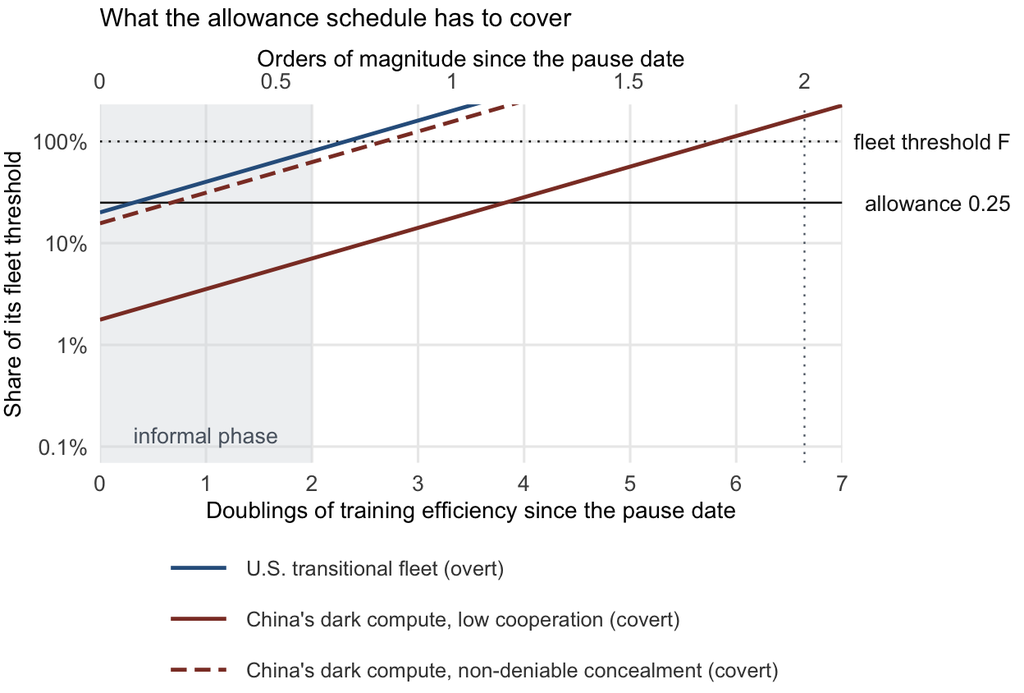

Three ledger lines, each as a fraction of its own fleet threshold, against doublings of training efficiency since the pause date; each doubling halves $F_E$ and $F_B$, so every line rises by a factor of two per doubling. The lines are separate estimates and are not added together. Shaded: the informal phase, before a treaty is signed (assumed within two doublings). Blue: the U.S. transitional inference fleet against $F_B$, while it is all in service. Red: China’s dark compute against $F_E$, under low cooperation (110k) and under non-deniable concealment (1M). The allowance schedule has to sit above the blue line at signing and reach 0.25 once transitional service is retired; the right-hand axis marks the 0.25 allowance and the fleet threshold itself, the top axis gives the same clock in orders of magnitude (one doubling is 0.30 OOM), and the dotted vertical line marks two orders of magnitude (6.64 doublings).

```r
dd <- seq(0, 7, by = 0.05)
ln <- rbind(
  data.frame(d = dd, y = sh[["U.S. transitional, overt"]] * 2^dd, k = "U.S. transitional fleet (overt)"),
  data.frame(d = dd, y = dk[["China", "low cooperation"]] * 2^dd, k = "China's dark compute, low cooperation (covert)"),
  data.frame(d = dd, y = dk[["China", "non-deniable concealment"]] * 2^dd, k = "China's dark compute, non-deniable concealment (covert)"))
ln$k <- factor(ln$k, levels = unique(ln$k))
ggplot(ln, aes(d, y, colour = k, linetype = k)) +
  annotate("rect", xmin = 0, xmax = 2, ymin = 1e-4, ymax = 100, fill = "#D9DCE0", alpha = 0.4, colour = NA) +
  annotate("text", x = 1, y = 0.0013, label = "informal phase", size = 3.55, colour = "#5A6470") +
  geom_hline(yintercept = c(0.25, 1), colour = "#1A1A1A", linetype = c("solid", "13"), linewidth = 0.45) +
  geom_line(linewidth = 0.85) +
  scale_colour_manual(values = c("#2E5F8C", "#8C3B2E", "#8C3B2E"), name = NULL) +
  scale_linetype_manual(values = c("solid", "solid", "42"), name = NULL) +
  scale_x_continuous(breaks = 0:7, expand = c(0, 0), sec.axis = dup_axis(breaks = log2(10^c(0, 0.5, 1, 1.5, 2)), labels = c("0", "0.5", "1", "1.5", "2"),
                                                                     name = "Orders of magnitude since the pause date")) +
  geom_vline(xintercept = log2(100), colour = "#5A6470", linetype = "13", linewidth = 0.4) +
  scale_y_log10(breaks = c(0.001, 0.01, 0.1, 1), labels = c("0.1%", "1%", "10%", "100%"),
                sec.axis = dup_axis(breaks = c(0.25, 1), labels = c("allowance 0.25", "fleet threshold F"), name = NULL)) +
  coord_cartesian(ylim = c(0.001, 1.6)) +
  guides(colour = guide_legend(ncol = 1), linetype = guide_legend(ncol = 1)) +
  labs(x = "Doublings of training efficiency since the pause date", y = "Share of its fleet threshold",
       title = "What the allowance schedule has to cover") +
  theme_minimal(base_size = 12) +
  theme(panel.grid.minor = element_blank(), plot.title = element_text(size = 11.5),
        axis.text = element_text(size = 10), axis.title = element_text(size = 10.5),
        axis.text.y.right = element_text(size = 10, colour = "#1A1A1A"), axis.text.x.top = element_text(size = 10), axis.title.x.top = element_text(size = 10.5),
        legend.position = "bottom", legend.text = element_text(size = 9.5, colour = "grey25"),
        legend.key.width = unit(2.2, "lines"), legend.margin = margin(0, 2, 0, 2), plot.margin = margin(4, 6, 2, 2))
```